# ANOVA test for score

Geiser C. Challco geiser@alumni.usp.br

- ANOVA: score ~ time
  - Data Preparation
  - Summary Statistics
  - ANOVA Computation
  - PairWise Computation
- ANOVA: score ~ time*gender + Error(id/time)
  - Data Preparation
    - Check assumptions: Identifying Outliers
    - Check assumptions: Normality Test
    - Summary Statistics
  - ANOVA Computation
  - ANOVA Computation after removing non.normal data
  - PairWise Computation
  - PairWise Computation after removing non.normal data
- ANOVA: score ~ time*localizacao + Error(id/time)
  - Data Preparation
    - Check assumptions: Identifying Outliers
    - Check assumptions: Normality Test
    - Summary Statistics
  - ANOVA Computation
  - ANOVA Computation after removing non.normal data
  - PairWise Computation
  - PairWise Computation after removing non.normal data
- ANOVA: score ~ time*regiao + Error(id/time)
  - Data Preparation
    - Check assumptions: Identifying Outliers
    - Check assumptions: Normality Test
    - Summary Statistics
  - ANOVA Computation
  - ANOVA Computation after removing non.normal data
  - PairWise Computation
  - PairWise Computation after removing non.normal data
- ANOVA: score ~ time*porte + Error(id/time)
  - Data Preparation
    - Check assumptions: Identifying Outliers
    - Check assumptions: Normality Test
    - Summary Statistics
  - ANOVA Computation
  - ANOVA Computation after removing non.normal data
  - PairWise Computation
  - PairWise Computation after removing non.normal data

```r
dat <- read_excel("../data/data.xlsx", sheet = "alunos_ef14")

escolas <- read_excel("../data/data.xlsx", sheet = "escolas")
edat <- merge(dat, escolas, by = "cod_escola", all.x = T)
```

# ANOVA: score ~ time

## Data Preparation

```r
data <- edat[,c("aluno_id","ciclo","score")]
data$ciclo <- factor(edat$ciclo, c("Primeiro Ciclo","Segundo Ciclo",
                                   "Terceiro Ciclo","Quarto Ciclo"))

wdat <- spread(data, ciclo, score)
wdat <- wdat[complete.cases(wdat),]
colnames(wdat) <- c("id","c1","c2","c3","c4")

ldat <- gather(wdat, key = time, value = score, c1, c2, c3, c4) %>%
  convert_as_factor(id, time)
ldat <- rshinystatistics::remove_group_data(ldat, "score", "time", n.limit = 30)
```

## Summary Statistics

```r
(sdat <- ldat %>% group_by(time) %>%
   get_summary_stats(score, type = "mean_sd"))
```

```
## # A tibble: 4 × 5
##   time  variable     n  mean    sd
##   <fct> <fct>    <dbl> <dbl> <dbl>
## 1 c1    score     1126  3.06 0.174
## 2 c2    score     1126  3.09 0.191
## 3 c3    score     1126  3.13 0.215
## 4 c4    score     1126  3.11 0.211
```

| time | variable | n | mean | sd |
| --- | --- | --- | --- | --- |
| c1 | score | 1126 | 3.055 | 0.174 |
| c2 | score | 1126 | 3.086 | 0.191 |
| c3 | score | 1126 | 3.126 | 0.215 |
| c4 | score | 1126 | 3.113 | 0.211 |

## ANOVA Computation

```r
(res.aov <- anova_test(ldat, dv = score, wid = id, within = time))
```

```
## ANOVA Table (type III tests)
##
## $ANOVA
##   Effect DFn  DFd      F        p p<.05   ges
## 1   time   3 3375 30.394 2.21e-19     * 0.018
##
## $`Mauchly's Test for Sphericity`
##   Effect     W     p p<.05
## 1   time 0.985 0.005     *
##
## $`Sphericity Corrections`
##   Effect   GGe        DF[GG]    p[GG] p[GG]<.05   HFe        DF[HF]    p[HF] p[HF]<.05
## 1   time 0.991 2.97, 3343.22 3.18e-19         * 0.993 2.98, 3353.04 2.84e-19         *
```

| Effect | DFn | DFd | F | p | p<.05 | ges |
| --- | --- | --- | --- | --- | --- | --- |
| time | 3 | 3375 | 30.394 | 0 | * | 0.018 |

| Effect | W | p | p<.05 |
| --- | --- | --- | --- |
| time | 0.985 | 0.005 | * |

| Effect | GGe | DF[GG] | p[GG] | p[GG]<.05 | HFe | DF[HF] | p[HF] | p[HF]<.05 |
| --- | --- | --- | --- | --- | --- | --- | --- | --- |
| time | 0.991 | 2.97, 3343.22 | 0 | * | 0.993 | 2.98, 3353.04 | 0 | * |

## PairWise Computation

```r
(pwc <- ldat %>% emmeans_test(score ~ time, detailed = T, p.adjust.method = "bonferroni"))
```

```
## # A tibble: 6 × 14
##   term  .y.   group1 group2 null.value estimate      se    df conf.low conf.high statistic
## * <chr> <chr> <chr>  <chr>       <dbl>    <dbl>   <dbl> <dbl>    <dbl>     <dbl>     <dbl>
## 1 time  score c1     c2              0  -0.0307 0.00836  4500 -0.0470    -0.0143     -3.67
## 2 time  score c1     c3              0  -0.0706 0.00836  4500 -0.0869    -0.0542     -8.44
## 3 time  score c1     c4              0  -0.0583 0.00836  4500 -0.0747    -0.0419     -6.97
## 4 time  score c2     c3              0  -0.0399 0.00836  4500 -0.0563    -0.0235     -4.77
## 5 time  score c2     c4              0  -0.0276 0.00836  4500 -0.0440    -0.0112     -3.30
## 6 time  score c3     c4              0   0.0123 0.00836  4500 -0.00411    0.0287      1.47
## # ℹ 3 more variables: p <dbl>, p.adj <dbl>, p.adj.signif <chr>
```

| term | .y. | group1 | group2 | null.value | estimate | se | df | conf.low | conf.high | statistic | p | p.adj | p.adj.signif |
| --- | --- | --- | --- | --- | --- | --- | --- | --- | --- | --- | --- | --- | --- |
| time | score | c1 | c2 | 0 | -0.031 | 0.008 | 4500 | -0.047 | -0.014 | -3.665 | 0.000 | 0.001 | ** |
| time | score | c1 | c3 | 0 | -0.071 | 0.008 | 4500 | -0.087 | -0.054 | -8.437 | 0.000 | 0.000 | **** |
| time | score | c1 | c4 | 0 | -0.058 | 0.008 | 4500 | -0.075 | -0.042 | -6.968 | 0.000 | 0.000 | **** |
| time | score | c2 | c3 | 0 | -0.040 | 0.008 | 4500 | -0.056 | -0.024 | -4.772 | 0.000 | 0.000 | **** |
| time | score | c2 | c4 | 0 | -0.028 | 0.008 | 4500 | -0.044 | -0.011 | -3.303 | 0.001 | 0.006 | ** |
| time | score | c3 | c4 | 0 | 0.012 | 0.008 | 4500 | -0.004 | 0.029 | 1.469 | 0.142 | 0.851 | ns |

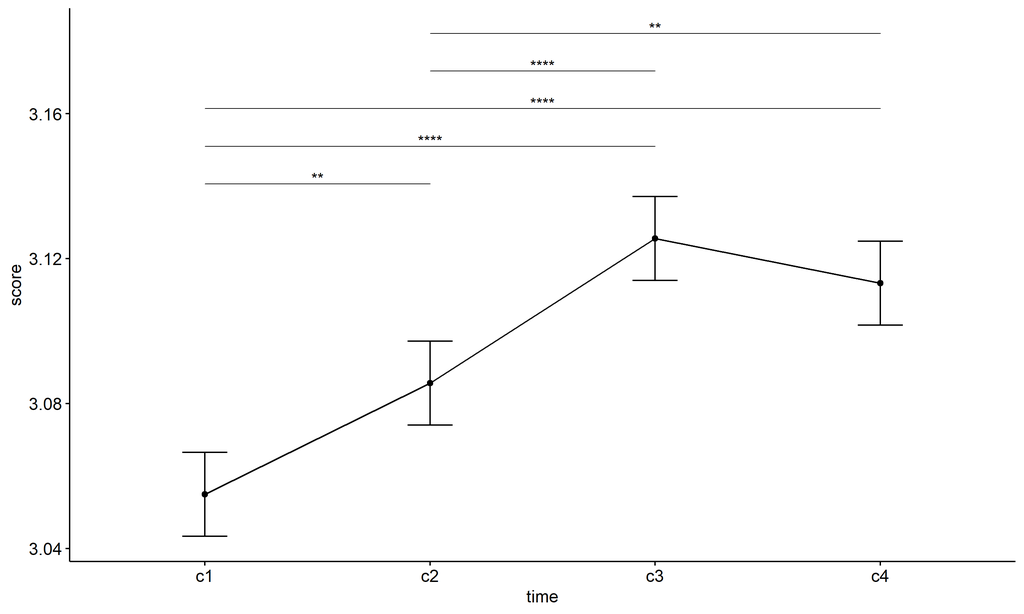

```r
pwc <- add_xy_position(pwc, x = "time", fun = "mean_se")
ggline(get_emmeans(pwc), x = "time", y = "emmean", ylab = "score") +
  geom_errorbar(aes(ymin = conf.low, ymax = conf.high), width = 0.2) +
  stat_pvalue_manual(pwc, hide.ns = T, tip.length = F)
```

# ANOVA: score ~ time*gender + Error(id/time)

## Data Preparation

```r
data <- edat[,c("aluno_id","gender","ciclo","score")]
data$ciclo <- factor(data$ciclo, c("Primeiro Ciclo","Segundo Ciclo",
                                   "Terceiro Ciclo","Quarto Ciclo"))

wdat <- spread(data, ciclo, score)
wdat <- wdat[complete.cases(wdat),]
colnames(wdat) <- c("id","gender","c1","c2","c3","c4")

ldat <- gather(wdat, key = time, value = score, c1, c2, c3, c4) %>%
  convert_as_factor(id, time)
ldat <- remove_group_data(ldat, "score", c("time", "gender"), n.limit = 30)
ldat$gender <- factor(ldat$gender, sort(unique(ldat$gender)))
```

### Check assumptions: Identifying Outliers

```r
outliers <- identify_outliers(group_by(ldat, time, gender), score)
(outliers <- outliers[outliers$is.extreme == T,])
```

```
## # A tibble: 21 × 6
##    gender time  id                   score is.outlier is.extreme
##    <fct>  <fct> <fct>                <dbl> <lgl>      <lgl>
##  1 Female c1    Ru3SPRo97iXBvXbvneKh  3.83 TRUE       TRUE
##  2 Female c1    vc8pPoYau2AIAuCQJipW  3.83 TRUE       TRUE
##  3 Male   c1    0w3VhiMf67CbcpR6aZCL  3.83 TRUE       TRUE
##  4 Male   c1    1Z1Qz8zDaMkaAz1Ah80K  3.83 TRUE       TRUE
##  5 Male   c1    D1HfJKTVqjrpCJx97l3v  3.75 TRUE       TRUE
##  6 Male   c1    uCBI6gnllsawWJlgqkr5  3.83 TRUE       TRUE
##  7 Female c2    oGUJyWRMYYbF9PNegJZh  3.83 TRUE       TRUE
##  8 Male   c2    cuknOzzwN4oCRum5U5ph  4    TRUE       TRUE
##  9 Male   c2    HsQF2J0r79mHSWNe4l6n  3.83 TRUE       TRUE
## 10 Male   c2    j31LU8Xwm0EQ7Mihkhjj  3.83 TRUE       TRUE
## # ℹ 11 more rows
```

| gender | time | id | score | is.outlier | is.extreme |
| --- | --- | --- | --- | --- | --- |
| Female | c1 | Ru3SPRo97iXBvXbvneKh | 3.833 | TRUE | TRUE |
| Female | c1 | vc8pPoYau2AIAuCQJipW | 3.833 | TRUE | TRUE |
| Male | c1 | 0w3VhiMf67CbcpR6aZCL | 3.833 | TRUE | TRUE |
| Male | c1 | 1Z1Qz8zDaMkaAz1Ah80K | 3.833 | TRUE | TRUE |
| Male | c1 | D1HfJKTVqjrpCJx97l3v | 3.750 | TRUE | TRUE |
| Male | c1 | uCBI6gnllsawWJlgqkr5 | 3.833 | TRUE | TRUE |
| Female | c2 | oGUJyWRMYYbF9PNegJZh | 3.833 | TRUE | TRUE |
| Male | c2 | cuknOzzwN4oCRum5U5ph | 4.000 | TRUE | TRUE |
| Male | c2 | HsQF2J0r79mHSWNe4l6n | 3.833 | TRUE | TRUE |
| Male | c2 | j31LU8Xwm0EQ7Mihkhjj | 3.833 | TRUE | TRUE |
| Male | c2 | z3p6Ot4uvkPmGXOS9D3e | 3.833 | TRUE | TRUE |
| Female | c3 | 6bEKmKQpOuvY6PSQvzqj | 4.000 | TRUE | TRUE |
| Female | c3 | CCVIt7MPeYMUOCCyBxPh | 4.000 | TRUE | TRUE |
| Female | c3 | i5EZ8Ck9IgDueyMbw55v | 4.000 | TRUE | TRUE |
| Female | c3 | m5yRlxfIj73j4ossfTOB | 4.000 | TRUE | TRUE |
| Female | c3 | OvwAQTWkdj8SYpPS8dgn | 3.833 | TRUE | TRUE |
| Female | c3 | RkRJsrzuZjQPcgr9Bu7D | 3.833 | TRUE | TRUE |
| Female | c4 | DP1fbT1lGhLiBnOFILLi | 3.833 | TRUE | TRUE |
| Female | c4 | fgNBRPWfCa0TP4bDO8d2 | 3.833 | TRUE | TRUE |
| Female | c4 | kFvRH3RtPD461qVG04iW | 3.833 | TRUE | TRUE |
| Female | c4 | PZJ6CleqURERCau51lXu | 3.750 | TRUE | TRUE |

### Check assumptions: Normality Test

```r
(normality.df <- normality.test.per.groups(ldat, "score", c("time", "gender")))
```

```
##     var variable time gender   n  skewness  kurtosis symmetry statistic     method            p
## 1 score    score   c1 Female 552 0.7680607 2.1004398       NO  75.73653 D'Agostino 0.000000e+00
## 2 score    score   c1   Male 513 0.9177898 2.5970433       NO  91.70099 D'Agostino 0.000000e+00
## 3 score    score   c2 Female 552 0.8773295 1.3594136       NO  74.22015 D'Agostino 1.110223e-16
## 4 score    score   c2   Male 513 0.8790069 2.2926351       NO  83.74395 D'Agostino 0.000000e+00
## 5 score    score   c3 Female 552 1.0802058 1.4927513       NO  97.19295 D'Agostino 0.000000e+00
## 6 score    score   c3   Male 513 0.7849097 0.1975376       NO  44.39819 D'Agostino 2.285888e-10
## 7 score    score   c4 Female 552 0.8261134 0.6660274       NO  57.63845 D'Agostino 3.047562e-13
## 8 score    score   c4   Male 513 0.7876196 0.7049213       NO  50.86628 D'Agostino 9.005907e-12
##   p.signif normality
## 1     ****         -
## 2     ****         -
## 3     ****         -
## 4     ****         -
## 5     ****         -
## 6     ****         -
## 7     ****         -
## 8     ****         -
```

| var | variable | time | gender | n | skewness | kurtosis | symmetry | statistic | method | p | p.signif | normality |
| --- | --- | --- | --- | --- | --- | --- | --- | --- | --- | --- | --- | --- |
| score | score | c1 | Female | 552 | 0.768 | 2.100 | NO | 75.737 | D’Agostino | 0 | **** | - |
| score | score | c1 | Male | 513 | 0.918 | 2.597 | NO | 91.701 | D’Agostino | 0 | **** | - |
| score | score | c2 | Female | 552 | 0.877 | 1.359 | NO | 74.220 | D’Agostino | 0 | **** | - |
| score | score | c2 | Male | 513 | 0.879 | 2.293 | NO | 83.744 | D’Agostino | 0 | **** | - |
| score | score | c3 | Female | 552 | 1.080 | 1.493 | NO | 97.193 | D’Agostino | 0 | **** | - |
| score | score | c3 | Male | 513 | 0.785 | 0.198 | NO | 44.398 | D’Agostino | 0 | **** | - |
| score | score | c4 | Female | 552 | 0.826 | 0.666 | NO | 57.638 | D’Agostino | 0 | **** | - |
| score | score | c4 | Male | 513 | 0.788 | 0.705 | NO | 50.866 | D’Agostino | 0 | **** | - |

```r
(non.ids <- unique(do.call(
  c, lapply(which(normality.df$normality == 'NO'), FUN = function(i) {
  idx = which(ldat$time == normality.df$time[i] &
                ldat$gender == normality.df$gender[i])
  getNonNormal(ldat$"score"[idx], ldat$id[idx])
}))))
```

```r
if (length(non.ids) > 0)
  ldat2 <- ldat[!ldat$id %in% non.ids,]
```

### Summary Statistics

```r
(sdat <- ldat %>% group_by(time, gender) %>%
   get_summary_stats(score, type = "mean_sd"))
```

```
## # A tibble: 8 × 6
##   gender time  variable     n  mean    sd
##   <fct>  <fct> <fct>    <dbl> <dbl> <dbl>
## 1 Female c1    score      552  3.05 0.169
## 2 Male   c1    score      513  3.06 0.185
## 3 Female c2    score      552  3.09 0.184
## 4 Male   c2    score      513  3.08 0.198
## 5 Female c3    score      552  3.12 0.223
## 6 Male   c3    score      513  3.13 0.209
## 7 Female c4    score      552  3.12 0.217
## 8 Male   c4    score      513  3.10 0.201
```

| gender | time | variable | n | mean | sd |
| --- | --- | --- | --- | --- | --- |
| Female | c1 | score | 552 | 3.054 | 0.169 |
| Male | c1 | score | 513 | 3.058 | 0.185 |
| Female | c2 | score | 552 | 3.090 | 0.184 |
| Male | c2 | score | 513 | 3.076 | 0.198 |
| Female | c3 | score | 552 | 3.123 | 0.223 |
| Male | c3 | score | 513 | 3.127 | 0.209 |
| Female | c4 | score | 552 | 3.124 | 0.217 |
| Male | c4 | score | 513 | 3.096 | 0.201 |

```r
if (length(non.ids) > 0)
  (sdat <- ldat2 %>% group_by(time, gender) %>%
      get_summary_stats(score, type = "mean_sd"))
```

| gender | time | variable | n | mean | sd |
| --- | --- | --- | --- | --- | --- |
| Female | c1 | score | 552 | 3.054 | 0.169 |
| Male | c1 | score | 513 | 3.058 | 0.185 |
| Female | c2 | score | 552 | 3.090 | 0.184 |
| Male | c2 | score | 513 | 3.076 | 0.198 |
| Female | c3 | score | 552 | 3.123 | 0.223 |
| Male | c3 | score | 513 | 3.127 | 0.209 |
| Female | c4 | score | 552 | 3.124 | 0.217 |
| Male | c4 | score | 513 | 3.096 | 0.201 |

## ANOVA Computation

```r
(res.aov <- anova_test(ldat, dv = score, wid = id, between = gender, within = time))
```

```
## ANOVA Table (type III tests)
##
## $ANOVA
##        Effect DFn  DFd      F        p p<.05      ges
## 1      gender   1 1063  1.553 2.13e-01       0.000439
## 2        time   3 3189 26.585 5.59e-17     * 0.017000
## 3 gender:time   3 3189  1.783 1.48e-01       0.001000
##
## $`Mauchly's Test for Sphericity`
##        Effect     W     p p<.05
## 1        time 0.984 0.005     *
## 2 gender:time 0.984 0.005     *
##
## $`Sphericity Corrections`
##        Effect  GGe     DF[GG]    p[GG] p[GG]<.05   HFe        DF[HF]    p[HF] p[HF]<.05
## 1        time 0.99 2.97, 3157 7.81e-17         * 0.993 2.98, 3166.82 7.05e-17         *
## 2 gender:time 0.99 2.97, 3157 1.49e-01           0.993 2.98, 3166.82 1.49e-01
```

| Effect | DFn | DFd | F | p | p<.05 | ges |
| --- | --- | --- | --- | --- | --- | --- |
| gender | 1 | 1063 | 1.553 | 0.213 |  | 0.000 |
| time | 3 | 3189 | 26.585 | 0.000 | * | 0.017 |
| gender:time | 3 | 3189 | 1.783 | 0.148 |  | 0.001 |

| Effect | W | p | p<.05 |
| --- | --- | --- | --- |
| time | 0.984 | 0.005 | * |
| gender:time | 0.984 | 0.005 | * |

| Effect | GGe | DF[GG] | p[GG] | p[GG]<.05 | HFe | DF[HF] | p[HF] | p[HF]<.05 |
| --- | --- | --- | --- | --- | --- | --- | --- | --- |
| time | 0.99 | 2.97, 3157 | 0.000 | * | 0.993 | 2.98, 3166.82 | 0.000 | * |
| gender:time | 0.99 | 2.97, 3157 | 0.149 |  | 0.993 | 2.98, 3166.82 | 0.149 |  |

## ANOVA Computation after removing non.normal data

```r
if (length(non.ids) > 0)
  (res.aov2 <- anova_test(ldat2, dv = score, wid = id, between = gender , within = time))
```

## PairWise Computation

```r
(pwc <- ldat %>% group_by(time) %>%
   emmeans_test(score ~ gender, detailed = T, p.adjust.method = "bonferroni"))
```

```
## # A tibble: 4 × 15
##   time  term   .y.   group1 group2 null.value estimate     se    df conf.low conf.high statistic
## * <fct> <chr>  <chr> <chr>  <chr>       <dbl>    <dbl>  <dbl> <dbl>    <dbl>     <dbl>     <dbl>
## 1 c1    gender score Female Male            0 -0.00427 0.0122  4252 -0.0282     0.0196    -0.350
## 2 c2    gender score Female Male            0  0.0134  0.0122  4252 -0.0105     0.0373     1.10
## 3 c3    gender score Female Male            0 -0.00413 0.0122  4252 -0.0280     0.0198    -0.339
## 4 c4    gender score Female Male            0  0.0284  0.0122  4252  0.00448    0.0523     2.33
## # ℹ 3 more variables: p <dbl>, p.adj <dbl>, p.adj.signif <chr>
```

| time | term | .y. | group1 | group2 | null.value | estimate | se | df | conf.low | conf.high | statistic | p | p.adj | p.adj.signif |
| --- | --- | --- | --- | --- | --- | --- | --- | --- | --- | --- | --- | --- | --- | --- |
| c1 | gender | score | Female | Male | 0 | -0.004 | 0.012 | 4252 | -0.028 | 0.020 | -0.350 | 0.726 | 0.726 | ns |
| c2 | gender | score | Female | Male | 0 | 0.013 | 0.012 | 4252 | -0.011 | 0.037 | 1.096 | 0.273 | 0.273 | ns |
| c3 | gender | score | Female | Male | 0 | -0.004 | 0.012 | 4252 | -0.028 | 0.020 | -0.339 | 0.735 | 0.735 | ns |
| c4 | gender | score | Female | Male | 0 | 0.028 | 0.012 | 4252 | 0.004 | 0.052 | 2.328 | 0.020 | 0.020 | * |

```r
(emms <- get_emmeans(pwc))
```

```
## # A tibble: 8 × 8
##   time  gender emmean      se    df conf.low conf.high method
##   <fct> <fct>   <dbl>   <dbl> <dbl>    <dbl>     <dbl> <chr>
## 1 c1    Female   3.05 0.00847  4252     3.04      3.07 Emmeans test
## 2 c1    Male     3.06 0.00878  4252     3.04      3.08 Emmeans test
## 3 c2    Female   3.09 0.00847  4252     3.07      3.11 Emmeans test
## 4 c2    Male     3.08 0.00878  4252     3.06      3.09 Emmeans test
## 5 c3    Female   3.12 0.00847  4252     3.11      3.14 Emmeans test
## 6 c3    Male     3.13 0.00878  4252     3.11      3.14 Emmeans test
## 7 c4    Female   3.12 0.00847  4252     3.11      3.14 Emmeans test
## 8 c4    Male     3.10 0.00878  4252     3.08      3.11 Emmeans test
```

| time | gender | emmean | se | df | conf.low | conf.high | method |
| --- | --- | --- | --- | --- | --- | --- | --- |
| c1 | Female | 3.054 | 0.008 | 4252 | 3.037 | 3.071 | Emmeans test |
| c1 | Male | 3.058 | 0.009 | 4252 | 3.041 | 3.076 | Emmeans test |
| c2 | Female | 3.090 | 0.008 | 4252 | 3.073 | 3.106 | Emmeans test |
| c2 | Male | 3.076 | 0.009 | 4252 | 3.059 | 3.093 | Emmeans test |
| c3 | Female | 3.123 | 0.008 | 4252 | 3.106 | 3.139 | Emmeans test |
| c3 | Male | 3.127 | 0.009 | 4252 | 3.110 | 3.144 | Emmeans test |
| c4 | Female | 3.124 | 0.008 | 4252 | 3.108 | 3.141 | Emmeans test |
| c4 | Male | 3.096 | 0.009 | 4252 | 3.079 | 3.113 | Emmeans test |

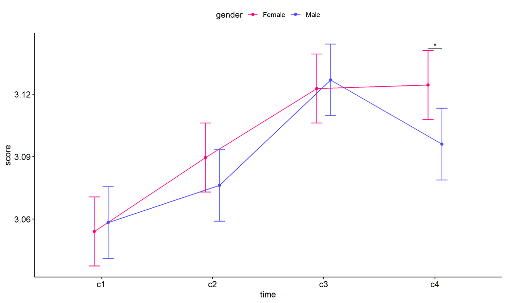

```r
pwc <- add_xy_position(pwc, x = "time", fun = "mean_se", dodge = 0.25)
pd <- position_dodge(width = 0.25)
ggline(emms, x = "time", y = "emmean", color = "gender",
       palette = c("#FF007F","#4D4DFF"),
       position = pd, ylab = "score") +
  geom_errorbar(aes(ymin = conf.low, ymax = conf.high, color = gender),
                position = pd, width = 0.2) +
  stat_pvalue_manual(pwc, hide.ns = T, tip.length = F, linetype = 1)
```

```r
(pwc <- ldat %>% group_by(gender) %>%
    emmeans_test(score ~ time, detailed = T, p.adjust.method = "bonferroni"))
```

```
## # A tibble: 12 × 15
##    gender term  .y.   group1 group2 null.value estimate     se    df conf.low conf.high statistic
##  * <fct>  <chr> <chr> <chr>  <chr>       <dbl>    <dbl>  <dbl> <dbl>    <dbl>     <dbl>     <dbl>
##  1 Female time  score c1     c2              0 -0.0355  0.0120  4252 -0.0589   -0.0120     -2.96
##  2 Female time  score c1     c3              0 -0.0687  0.0120  4252 -0.0922   -0.0452     -5.74
##  3 Female time  score c1     c4              0 -0.0704  0.0120  4252 -0.0938   -0.0469     -5.88
##  4 Female time  score c2     c3              0 -0.0332  0.0120  4252 -0.0567   -0.00974    -2.77
##  5 Female time  score c2     c4              0 -0.0349  0.0120  4252 -0.0583   -0.0114     -2.91
##  6 Female time  score c3     c4              0 -0.00166 0.0120  4252 -0.0251    0.0218     -0.139
##  7 Male   time  score c1     c2              0 -0.0178  0.0124  4252 -0.0422    0.00651    -1.44
##  8 Male   time  score c1     c3              0 -0.0686  0.0124  4252 -0.0929   -0.0442     -5.52
##  9 Male   time  score c1     c4              0 -0.0377  0.0124  4252 -0.0620   -0.0133     -3.03
## 10 Male   time  score c2     c3              0 -0.0507  0.0124  4252 -0.0751   -0.0264     -4.08
## 11 Male   time  score c2     c4              0 -0.0198  0.0124  4252 -0.0442    0.00450    -1.60
## 12 Male   time  score c3     c4              0  0.0309  0.0124  4252  0.00652   0.0552      2.49
## # ℹ 3 more variables: p <dbl>, p.adj <dbl>, p.adj.signif <chr>
```

| gender | term | .y. | group1 | group2 | null.value | estimate | se | df | conf.low | conf.high | statistic | p | p.adj | p.adj.signif |
| --- | --- | --- | --- | --- | --- | --- | --- | --- | --- | --- | --- | --- | --- | --- |
| Female | time | score | c1 | c2 | 0 | -0.035 | 0.012 | 4252 | -0.059 | -0.012 | -2.963 | 0.003 | 0.018 | * |
| Female | time | score | c1 | c3 | 0 | -0.069 | 0.012 | 4252 | -0.092 | -0.045 | -5.738 | 0.000 | 0.000 | **** |
| Female | time | score | c1 | c4 | 0 | -0.070 | 0.012 | 4252 | -0.094 | -0.047 | -5.876 | 0.000 | 0.000 | **** |
| Female | time | score | c2 | c3 | 0 | -0.033 | 0.012 | 4252 | -0.057 | -0.010 | -2.774 | 0.006 | 0.033 | * |
| Female | time | score | c2 | c4 | 0 | -0.035 | 0.012 | 4252 | -0.058 | -0.011 | -2.913 | 0.004 | 0.022 | * |
| Female | time | score | c3 | c4 | 0 | -0.002 | 0.012 | 4252 | -0.025 | 0.022 | -0.139 | 0.890 | 1.000 | ns |
| Male | time | score | c1 | c2 | 0 | -0.018 | 0.012 | 4252 | -0.042 | 0.007 | -1.437 | 0.151 | 0.905 | ns |
| Male | time | score | c1 | c3 | 0 | -0.069 | 0.012 | 4252 | -0.093 | -0.044 | -5.520 | 0.000 | 0.000 | **** |
| Male | time | score | c1 | c4 | 0 | -0.038 | 0.012 | 4252 | -0.062 | -0.013 | -3.035 | 0.002 | 0.015 | * |
| Male | time | score | c2 | c3 | 0 | -0.051 | 0.012 | 4252 | -0.075 | -0.026 | -4.083 | 0.000 | 0.000 | *** |
| Male | time | score | c2 | c4 | 0 | -0.020 | 0.012 | 4252 | -0.044 | 0.005 | -1.598 | 0.110 | 0.661 | ns |
| Male | time | score | c3 | c4 | 0 | 0.031 | 0.012 | 4252 | 0.007 | 0.055 | 2.485 | 0.013 | 0.078 | ns |

```r
(emms <- get_emmeans(pwc))
```

```
## # A tibble: 8 × 8
##   gender time  emmean      se    df conf.low conf.high method
##   <fct>  <fct>  <dbl>   <dbl> <dbl>    <dbl>     <dbl> <chr>
## 1 Female c1      3.05 0.00847  4252     3.04      3.07 Emmeans test
## 2 Female c2      3.09 0.00847  4252     3.07      3.11 Emmeans test
## 3 Female c3      3.12 0.00847  4252     3.11      3.14 Emmeans test
## 4 Female c4      3.12 0.00847  4252     3.11      3.14 Emmeans test
## 5 Male   c1      3.06 0.00878  4252     3.04      3.08 Emmeans test
## 6 Male   c2      3.08 0.00878  4252     3.06      3.09 Emmeans test
## 7 Male   c3      3.13 0.00878  4252     3.11      3.14 Emmeans test
## 8 Male   c4      3.10 0.00878  4252     3.08      3.11 Emmeans test
```

| gender | time | emmean | se | df | conf.low | conf.high | method |
| --- | --- | --- | --- | --- | --- | --- | --- |
| Female | c1 | 3.054 | 0.008 | 4252 | 3.037 | 3.071 | Emmeans test |
| Female | c2 | 3.090 | 0.008 | 4252 | 3.073 | 3.106 | Emmeans test |
| Female | c3 | 3.123 | 0.008 | 4252 | 3.106 | 3.139 | Emmeans test |
| Female | c4 | 3.124 | 0.008 | 4252 | 3.108 | 3.141 | Emmeans test |
| Male | c1 | 3.058 | 0.009 | 4252 | 3.041 | 3.076 | Emmeans test |
| Male | c2 | 3.076 | 0.009 | 4252 | 3.059 | 3.093 | Emmeans test |
| Male | c3 | 3.127 | 0.009 | 4252 | 3.110 | 3.144 | Emmeans test |
| Male | c4 | 3.096 | 0.009 | 4252 | 3.079 | 3.113 | Emmeans test |

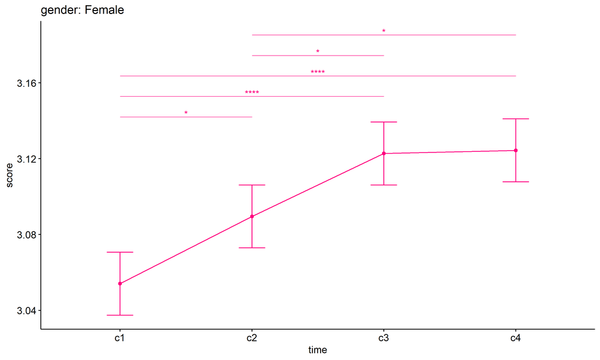

```r
emms.gg <- emms[which(emms$gender == "Female"),]
if (nrow(emms.gg) > 0)
  ggline(emms.gg, x = "time", y = "emmean", color = "#FF007F", ylab = "score") +
    geom_errorbar(aes(ymin = conf.low, ymax = conf.high),
                  width = 0.2, color = "#FF007F") +
    stat_pvalue_manual(
      add_xy_position(pwc[which(pwc$gender == "Female"),],
                      x = "time", fun = "mean_se"),
      hide.ns = T, color = "#FF007F", tip.length = F) +
    labs(title = "gender: Female")+
    theme(legend.text = element_blank())
```

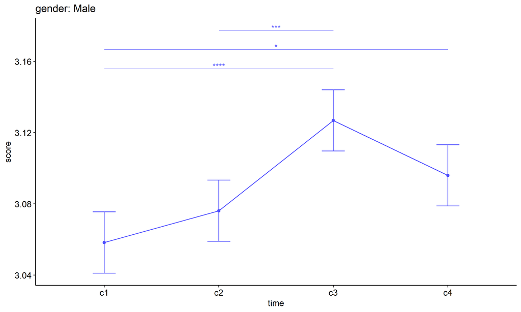

```r
emms.gg <- emms[which(emms$gender == "Male"),]
if (nrow(emms.gg) > 0)
  ggline(emms.gg, x = "time", y = "emmean", color = "#4D4DFF", ylab = "score") +
    geom_errorbar(aes(ymin = conf.low, ymax = conf.high),
                  width = 0.2, color = "#4D4DFF") +
    stat_pvalue_manual(
      add_xy_position(pwc[which(pwc$gender == "Male"),],
                      x = "time", fun = "mean_se"),
      hide.ns = T, color = "#4D4DFF", tip.length = F) +
    labs(title = "gender: Male")+
    theme(legend.text = element_blank())
```

## PairWise Computation after removing non.normal data

```r
if (length(non.ids) > 0)
  (pwc2 <- ldat2 %>% group_by(time) %>%
     emmeans_test(score ~ gender, detailed = T, p.adjust.method = "bonferroni"))
```

```r
if (length(non.ids) > 0)
  (emms2 <- get_emmeans(pwc2))
```

```r
if (length(non.ids) > 0) {
  pwc2 <- add_xy_position(pwc2, x = "time", fun = "mean_se", dodge = 0.25)
  pd2 <- position_dodge(width = 0.25)

  ggline(emms2, x = "time", y = "emmean", color = "gender",
         palette = c("#FF007F","#4D4DFF"),
         position = pd, ylab = "score") +
    geom_errorbar(aes(ymin = conf.low, ymax = conf.high, color = gender),
                position = pd, width = 0.2) +
    stat_pvalue_manual(pwc2, hide.ns = T, tip.length = F, linetype = 1)
}
```

```r
if (length(non.ids) > 0)
  (pwc2 <- ldat2 %>% group_by(gender) %>%
     emmeans_test(score ~ time, detailed = T, p.adjust.method = "bonferroni"))
```

```r
if (length(non.ids) > 0)
  (emms2 <- get_emmeans(pwc2))
```

```r
if (length(non.ids) > 0) {
  emms.gg <- emms2[which(emms2$gender == "Female"),]
  if (nrow(emms.gg) > 0)
    ggline(emms.gg, x = "time", y = "emmean", color = "#FF007F", ylab = "score") +
    geom_errorbar(aes(ymin = conf.low, ymax = conf.high),
                  width = 0.2, color = "#FF007F") +
    stat_pvalue_manual(
      add_xy_position(pwc[which(pwc$gender == "Female"),],
                      x = "time", fun = "mean_se"),
      hide.ns = T, color = "#FF007F", tip.length = F) +
    labs(title = "gender: Female") +
    theme(legend.text = element_blank())
}
```

```r
if (length(non.ids) > 0) {
  emms.gg <- emms2[which(emms2$gender == "Male"),]
  if (nrow(emms.gg) > 0)
    ggline(emms.gg, x = "time", y = "emmean", color = "#4D4DFF", ylab = "score") +
    geom_errorbar(aes(ymin = conf.low, ymax = conf.high),
                  width = 0.2, color = "#4D4DFF") +
    stat_pvalue_manual(
      add_xy_position(pwc[which(pwc$gender == "Male"),],
                      x = "time", fun = "mean_se"),
      hide.ns = T, color = "#4D4DFF", tip.length = F) +
    labs(title = "gender: Male") +
    theme(legend.text = element_blank())
}
```

# ANOVA: score ~ time*localizacao + Error(id/time)

## Data Preparation

```r
data <- edat[,c("aluno_id","localizacao","ciclo","score")]
data$ciclo <- factor(data$ciclo, c("Primeiro Ciclo","Segundo Ciclo",
                                   "Terceiro Ciclo","Quarto Ciclo"))

wdat <- spread(data, ciclo, score)
wdat <- wdat[complete.cases(wdat),]
colnames(wdat) <- c("id","localizacao","c1","c2","c3","c4")

ldat <- gather(wdat, key = time, value = score, c1, c2, c3, c4) %>%
  convert_as_factor(id, time)
ldat <- remove_group_data(ldat, "score", c("time", "localizacao"), n.limit = 30)
ldat$localizacao <- factor(ldat$localizacao, sort(unique(ldat$localizacao)))
```

### Check assumptions: Identifying Outliers

```r
outliers <- identify_outliers(group_by(ldat, time, localizacao), score)
(outliers <- outliers[outliers$is.extreme == T,])
```

```
## # A tibble: 22 × 6
##    localizacao time  id                   score is.outlier is.extreme
##    <fct>       <fct> <fct>                <dbl> <lgl>      <lgl>
##  1 Rural       c1    0w3VhiMf67CbcpR6aZCL  3.83 TRUE       TRUE
##  2 Rural       c1    D1HfJKTVqjrpCJx97l3v  3.75 TRUE       TRUE
##  3 Urbana      c1    1Z1Qz8zDaMkaAz1Ah80K  3.83 TRUE       TRUE
##  4 Urbana      c1    Ru3SPRo97iXBvXbvneKh  3.83 TRUE       TRUE
##  5 Urbana      c1    uCBI6gnllsawWJlgqkr5  3.83 TRUE       TRUE
##  6 Urbana      c1    vc8pPoYau2AIAuCQJipW  3.83 TRUE       TRUE
##  7 Rural       c2    z3p6Ot4uvkPmGXOS9D3e  3.83 TRUE       TRUE
##  8 Urbana      c2    cuknOzzwN4oCRum5U5ph  4    TRUE       TRUE
##  9 Urbana      c2    HsQF2J0r79mHSWNe4l6n  3.83 TRUE       TRUE
## 10 Urbana      c2    j31LU8Xwm0EQ7Mihkhjj  3.83 TRUE       TRUE
## # ℹ 12 more rows
```

| localizacao | time | id | score | is.outlier | is.extreme |
| --- | --- | --- | --- | --- | --- |
| Rural | c1 | 0w3VhiMf67CbcpR6aZCL | 3.833 | TRUE | TRUE |
| Rural | c1 | D1HfJKTVqjrpCJx97l3v | 3.750 | TRUE | TRUE |
| Urbana | c1 | 1Z1Qz8zDaMkaAz1Ah80K | 3.833 | TRUE | TRUE |
| Urbana | c1 | Ru3SPRo97iXBvXbvneKh | 3.833 | TRUE | TRUE |
| Urbana | c1 | uCBI6gnllsawWJlgqkr5 | 3.833 | TRUE | TRUE |
| Urbana | c1 | vc8pPoYau2AIAuCQJipW | 3.833 | TRUE | TRUE |
| Rural | c2 | z3p6Ot4uvkPmGXOS9D3e | 3.833 | TRUE | TRUE |
| Urbana | c2 | cuknOzzwN4oCRum5U5ph | 4.000 | TRUE | TRUE |
| Urbana | c2 | HsQF2J0r79mHSWNe4l6n | 3.833 | TRUE | TRUE |
| Urbana | c2 | j31LU8Xwm0EQ7Mihkhjj | 3.833 | TRUE | TRUE |
| Urbana | c2 | oGUJyWRMYYbF9PNegJZh | 3.833 | TRUE | TRUE |
| Urbana | c3 | 6bEKmKQpOuvY6PSQvzqj | 4.000 | TRUE | TRUE |
| Urbana | c3 | CCVIt7MPeYMUOCCyBxPh | 4.000 | TRUE | TRUE |
| Urbana | c3 | i5EZ8Ck9IgDueyMbw55v | 4.000 | TRUE | TRUE |
| Urbana | c3 | m5yRlxfIj73j4ossfTOB | 4.000 | TRUE | TRUE |
| Urbana | c3 | OvwAQTWkdj8SYpPS8dgn | 3.833 | TRUE | TRUE |
| Urbana | c3 | RkRJsrzuZjQPcgr9Bu7D | 3.833 | TRUE | TRUE |
| Rural | c4 | 1OE4fvPj9Y2Q9Bnwr0xz | 3.833 | TRUE | TRUE |
| Rural | c4 | fgNBRPWfCa0TP4bDO8d2 | 3.833 | TRUE | TRUE |
| Rural | c4 | kFvRH3RtPD461qVG04iW | 3.833 | TRUE | TRUE |
| Urbana | c4 | DP1fbT1lGhLiBnOFILLi | 3.833 | TRUE | TRUE |
| Urbana | c4 | PZJ6CleqURERCau51lXu | 3.750 | TRUE | TRUE |

### Check assumptions: Normality Test

```r
(normality.df <- normality.test.per.groups(ldat, "score", c("time", "localizacao")))
```

```
##     var variable time localizacao   n  skewness   kurtosis symmetry statistic     method
## 1 score    score   c1       Rural 181 0.9626195  3.5205113       NO  43.73800 D'Agostino
## 2 score    score   c1      Urbana 945 0.8433006  2.3341529       NO 143.91565 D'Agostino
## 3 score    score   c2       Rural 181 0.6264629  0.5975063       NO  14.03047 D'Agostino
## 4 score    score   c2      Urbana 945 0.9166824  2.1625749       NO 151.87838 D'Agostino
## 5 score    score   c3       Rural 181 0.6994970 -0.2000273       NO  13.56569 D'Agostino
## 6 score    score   c3      Urbana 945 1.0039431  1.2140906       NO 141.22856 D'Agostino
## 7 score    score   c4       Rural 181 1.1238038  1.0836762       NO  34.69333 D'Agostino
## 8 score    score   c4      Urbana 945 0.7781698  0.6478032       NO  88.08347 D'Agostino
##              p p.signif normality
## 1 3.179896e-10     ****        QQ
## 2 0.000000e+00     ****         -
## 3 8.980943e-04       **        QQ
## 4 0.000000e+00     ****         -
## 5 1.133045e-03        *        QQ
## 6 0.000000e+00     ****         -
## 7 2.927114e-08     ****        QQ
## 8 0.000000e+00     ****         -
```

| var | variable | time | localizacao | n | skewness | kurtosis | symmetry | statistic | method | p | p.signif | normality |
| --- | --- | --- | --- | --- | --- | --- | --- | --- | --- | --- | --- | --- |
| score | score | c1 | Rural | 181 | 0.963 | 3.521 | NO | 43.738 | D’Agostino | 0.000 | **** | QQ |
| score | score | c1 | Urbana | 945 | 0.843 | 2.334 | NO | 143.916 | D’Agostino | 0.000 | **** | - |
| score | score | c2 | Rural | 181 | 0.626 | 0.598 | NO | 14.030 | D’Agostino | 0.001 | ** | QQ |
| score | score | c2 | Urbana | 945 | 0.917 | 2.163 | NO | 151.878 | D’Agostino | 0.000 | **** | - |
| score | score | c3 | Rural | 181 | 0.699 | -0.200 | NO | 13.566 | D’Agostino | 0.001 | * | QQ |
| score | score | c3 | Urbana | 945 | 1.004 | 1.214 | NO | 141.229 | D’Agostino | 0.000 | **** | - |
| score | score | c4 | Rural | 181 | 1.124 | 1.084 | NO | 34.693 | D’Agostino | 0.000 | **** | QQ |
| score | score | c4 | Urbana | 945 | 0.778 | 0.648 | NO | 88.083 | D’Agostino | 0.000 | **** | - |

```r
(non.ids <- unique(do.call(
  c, lapply(which(normality.df$normality == 'NO'), FUN = function(i) {
  idx = which(ldat$time == normality.df$time[i] &
                ldat$localizacao == normality.df$localizacao[i])
  getNonNormal(ldat$"score"[idx], ldat$id[idx])
}))))
```

```r
if (length(non.ids) > 0)
  ldat2 <- ldat[!ldat$id %in% non.ids,]
```

### Summary Statistics

```r
(sdat <- ldat %>% group_by(time, localizacao) %>%
   get_summary_stats(score, type = "mean_sd"))
```

```
## # A tibble: 8 × 6
##   localizacao time  variable     n  mean    sd
##   <fct>       <fct> <fct>    <dbl> <dbl> <dbl>
## 1 Rural       c1    score      181  3.06 0.166
## 2 Urbana      c1    score      945  3.05 0.176
## 3 Rural       c2    score      181  3.11 0.211
## 4 Urbana      c2    score      945  3.08 0.186
## 5 Rural       c3    score      181  3.16 0.224
## 6 Urbana      c3    score      945  3.12 0.213
## 7 Rural       c4    score      181  3.13 0.218
## 8 Urbana      c4    score      945  3.11 0.209
```

| localizacao | time | variable | n | mean | sd |
| --- | --- | --- | --- | --- | --- |
| Rural | c1 | score | 181 | 3.063 | 0.166 |
| Urbana | c1 | score | 945 | 3.053 | 0.176 |
| Rural | c2 | score | 181 | 3.107 | 0.211 |
| Urbana | c2 | score | 945 | 3.081 | 0.186 |
| Rural | c3 | score | 181 | 3.159 | 0.224 |
| Urbana | c3 | score | 945 | 3.119 | 0.213 |
| Rural | c4 | score | 181 | 3.128 | 0.218 |
| Urbana | c4 | score | 945 | 3.110 | 0.209 |

```r
if (length(non.ids) > 0)
  (sdat <- ldat2 %>% group_by(time, localizacao) %>%
      get_summary_stats(score, type = "mean_sd"))
```

| localizacao | time | variable | n | mean | sd |
| --- | --- | --- | --- | --- | --- |
| Rural | c1 | score | 181 | 3.063 | 0.166 |
| Urbana | c1 | score | 945 | 3.053 | 0.176 |
| Rural | c2 | score | 181 | 3.107 | 0.211 |
| Urbana | c2 | score | 945 | 3.081 | 0.186 |
| Rural | c3 | score | 181 | 3.159 | 0.224 |
| Urbana | c3 | score | 945 | 3.119 | 0.213 |
| Rural | c4 | score | 181 | 3.128 | 0.218 |
| Urbana | c4 | score | 945 | 3.110 | 0.209 |

## ANOVA Computation

```r
(res.aov <- anova_test(ldat, dv = score, wid = id, between = localizacao, within = time))
```

```
## ANOVA Table (type III tests)
##
## $ANOVA
##             Effect DFn  DFd      F        p p<.05      ges
## 1      localizacao   1 1124  7.004 8.00e-03     * 0.002000
## 2             time   3 3372 20.281 5.05e-13     * 0.012000
## 3 localizacao:time   3 3372  0.702 5.51e-01       0.000435
##
## $`Mauchly's Test for Sphericity`
##             Effect     W     p p<.05
## 1             time 0.985 0.005     *
## 2 localizacao:time 0.985 0.005     *
##
## $`Sphericity Corrections`
##             Effect   GGe        DF[GG]    p[GG] p[GG]<.05   HFe        DF[HF]    p[HF] p[HF]<.05
## 1             time 0.991 2.97, 3340.16 6.36e-13         * 0.993 2.98, 3349.99 5.92e-13         *
## 2 localizacao:time 0.991 2.97, 3340.16 5.49e-01           0.993 2.98, 3349.99 5.50e-01
```

| Effect | DFn | DFd | F | p | p<.05 | ges |
| --- | --- | --- | --- | --- | --- | --- |
| localizacao | 1 | 1124 | 7.004 | 0.008 | * | 0.002 |
| time | 3 | 3372 | 20.281 | 0.000 | * | 0.012 |
| localizacao:time | 3 | 3372 | 0.702 | 0.551 |  | 0.000 |

| Effect | W | p | p<.05 |
| --- | --- | --- | --- |
| time | 0.985 | 0.005 | * |
| localizacao:time | 0.985 | 0.005 | * |

| Effect | GGe | DF[GG] | p[GG] | p[GG]<.05 | HFe | DF[HF] | p[HF] | p[HF]<.05 |
| --- | --- | --- | --- | --- | --- | --- | --- | --- |
| time | 0.991 | 2.97, 3340.16 | 0.000 | * | 0.993 | 2.98, 3349.99 | 0.00 | * |
| localizacao:time | 0.991 | 2.97, 3340.16 | 0.549 |  | 0.993 | 2.98, 3349.99 | 0.55 |  |

## ANOVA Computation after removing non.normal data

```r
if (length(non.ids) > 0)
  (res.aov2 <- anova_test(ldat2, dv = score, wid = id, between = localizacao , within = time))
```

## PairWise Computation

```r
(pwc <- ldat %>% group_by(time) %>%
   emmeans_test(score ~ localizacao, detailed = T, p.adjust.method = "bonferroni"))
```

```
## # A tibble: 4 × 15
##   time  term    .y.   group1 group2 null.value estimate     se    df conf.low conf.high statistic
## * <fct> <chr>   <chr> <chr>  <chr>       <dbl>    <dbl>  <dbl> <dbl>    <dbl>     <dbl>     <dbl>
## 1 c1    locali… score Rural  Urbana          0  0.00967 0.0161  4496 -0.0219     0.0412     0.601
## 2 c2    locali… score Rural  Urbana          0  0.0258  0.0161  4496 -0.00573    0.0573     1.60
## 3 c3    locali… score Rural  Urbana          0  0.0403  0.0161  4496  0.00871    0.0718     2.50
## 4 c4    locali… score Rural  Urbana          0  0.0181  0.0161  4496 -0.0134     0.0497     1.13
## # ℹ 3 more variables: p <dbl>, p.adj <dbl>, p.adj.signif <chr>
```

| time | term | .y. | group1 | group2 | null.value | estimate | se | df | conf.low | conf.high | statistic | p | p.adj | p.adj.signif |
| --- | --- | --- | --- | --- | --- | --- | --- | --- | --- | --- | --- | --- | --- | --- |
| c1 | localizacao | score | Rural | Urbana | 0 | 0.010 | 0.016 | 4496 | -0.022 | 0.041 | 0.601 | 0.548 | 0.548 | ns |
| c2 | localizacao | score | Rural | Urbana | 0 | 0.026 | 0.016 | 4496 | -0.006 | 0.057 | 1.604 | 0.109 | 0.109 | ns |
| c3 | localizacao | score | Rural | Urbana | 0 | 0.040 | 0.016 | 4496 | 0.009 | 0.072 | 2.502 | 0.012 | 0.012 | * |
| c4 | localizacao | score | Rural | Urbana | 0 | 0.018 | 0.016 | 4496 | -0.013 | 0.050 | 1.127 | 0.260 | 0.260 | ns |

```r
(emms <- get_emmeans(pwc))
```

```
## # A tibble: 8 × 8
##   time  localizacao emmean      se    df conf.low conf.high method
##   <fct> <fct>        <dbl>   <dbl> <dbl>    <dbl>     <dbl> <chr>
## 1 c1    Rural         3.06 0.0147   4496     3.03      3.09 Emmeans test
## 2 c1    Urbana        3.05 0.00645  4496     3.04      3.07 Emmeans test
## 3 c2    Rural         3.11 0.0147   4496     3.08      3.14 Emmeans test
## 4 c2    Urbana        3.08 0.00645  4496     3.07      3.09 Emmeans test
## 5 c3    Rural         3.16 0.0147   4496     3.13      3.19 Emmeans test
## 6 c3    Urbana        3.12 0.00645  4496     3.11      3.13 Emmeans test
## 7 c4    Rural         3.13 0.0147   4496     3.10      3.16 Emmeans test
## 8 c4    Urbana        3.11 0.00645  4496     3.10      3.12 Emmeans test
```

| time | localizacao | emmean | se | df | conf.low | conf.high | method |
| --- | --- | --- | --- | --- | --- | --- | --- |
| c1 | Rural | 3.063 | 0.015 | 4496 | 3.034 | 3.092 | Emmeans test |
| c1 | Urbana | 3.053 | 0.006 | 4496 | 3.041 | 3.066 | Emmeans test |
| c2 | Rural | 3.107 | 0.015 | 4496 | 3.078 | 3.136 | Emmeans test |
| c2 | Urbana | 3.081 | 0.006 | 4496 | 3.069 | 3.094 | Emmeans test |
| c3 | Rural | 3.159 | 0.015 | 4496 | 3.130 | 3.188 | Emmeans test |
| c3 | Urbana | 3.119 | 0.006 | 4496 | 3.106 | 3.132 | Emmeans test |
| c4 | Rural | 3.128 | 0.015 | 4496 | 3.100 | 3.157 | Emmeans test |
| c4 | Urbana | 3.110 | 0.006 | 4496 | 3.098 | 3.123 | Emmeans test |

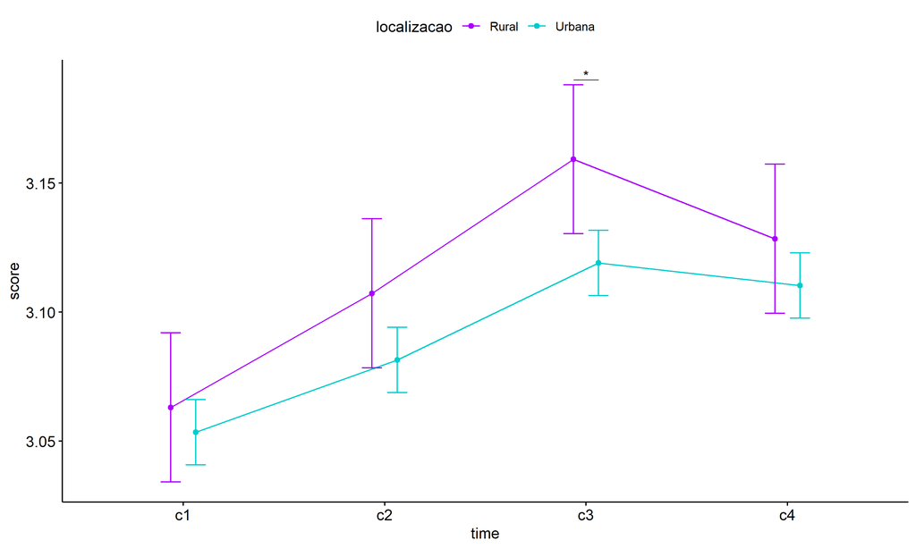

```r
pwc <- add_xy_position(pwc, x = "time", fun = "mean_se", dodge = 0.25)
pd <- position_dodge(width = 0.25)
ggline(emms, x = "time", y = "emmean", color = "localizacao",
       palette = c("#AA00FF","#00CCCC"),
       position = pd, ylab = "score") +
  geom_errorbar(aes(ymin = conf.low, ymax = conf.high, color = localizacao),
                position = pd, width = 0.2) +
  stat_pvalue_manual(pwc, hide.ns = T, tip.length = F, linetype = 1)
```

```r
(pwc <- ldat %>% group_by(localizacao) %>%
    emmeans_test(score ~ time, detailed = T, p.adjust.method = "bonferroni"))
```

```
## # A tibble: 12 × 15
##    localizacao term  .y.   group1 group2 null.value estimate      se    df conf.low conf.high
##  * <fct>       <chr> <chr> <chr>  <chr>       <dbl>    <dbl>   <dbl> <dbl>    <dbl>     <dbl>
##  1 Rural       time  score c1     c2              0 -0.0442  0.0208   4496 -0.0851   -0.00334
##  2 Rural       time  score c1     c3              0 -0.0962  0.0208   4496 -0.137    -0.0554
##  3 Rural       time  score c1     c4              0 -0.0654  0.0208   4496 -0.106    -0.0245
##  4 Rural       time  score c2     c3              0 -0.0520  0.0208   4496 -0.0929   -0.0112
##  5 Rural       time  score c2     c4              0 -0.0212  0.0208   4496 -0.0620    0.0197
##  6 Rural       time  score c3     c4              0  0.0308  0.0208   4496 -0.0100    0.0717
##  7 Urbana      time  score c1     c2              0 -0.0281  0.00912  4496 -0.0459   -0.0102
##  8 Urbana      time  score c1     c3              0 -0.0656  0.00912  4496 -0.0835   -0.0478
##  9 Urbana      time  score c1     c4              0 -0.0569  0.00912  4496 -0.0748   -0.0390
## 10 Urbana      time  score c2     c3              0 -0.0376  0.00912  4496 -0.0555   -0.0197
## 11 Urbana      time  score c2     c4              0 -0.0289  0.00912  4496 -0.0467   -0.0110
## 12 Urbana      time  score c3     c4              0  0.00873 0.00912  4496 -0.00915   0.0266
## # ℹ 4 more variables: statistic <dbl>, p <dbl>, p.adj <dbl>, p.adj.signif <chr>
```

| localizacao | term | .y. | group1 | group2 | null.value | estimate | se | df | conf.low | conf.high | statistic | p | p.adj | p.adj.signif |
| --- | --- | --- | --- | --- | --- | --- | --- | --- | --- | --- | --- | --- | --- | --- |
| Rural | time | score | c1 | c2 | 0 | -0.044 | 0.021 | 4496 | -0.085 | -0.003 | -2.121 | 0.034 | 0.204 | ns |
| Rural | time | score | c1 | c3 | 0 | -0.096 | 0.021 | 4496 | -0.137 | -0.055 | -4.617 | 0.000 | 0.000 | **** |
| Rural | time | score | c1 | c4 | 0 | -0.065 | 0.021 | 4496 | -0.106 | -0.025 | -3.137 | 0.002 | 0.010 | * |
| Rural | time | score | c2 | c3 | 0 | -0.052 | 0.021 | 4496 | -0.093 | -0.011 | -2.496 | 0.013 | 0.076 | ns |
| Rural | time | score | c2 | c4 | 0 | -0.021 | 0.021 | 4496 | -0.062 | 0.020 | -1.016 | 0.310 | 1.000 | ns |
| Rural | time | score | c3 | c4 | 0 | 0.031 | 0.021 | 4496 | -0.010 | 0.072 | 1.480 | 0.139 | 0.834 | ns |
| Urbana | time | score | c1 | c2 | 0 | -0.028 | 0.009 | 4496 | -0.046 | -0.010 | -3.076 | 0.002 | 0.013 | * |
| Urbana | time | score | c1 | c3 | 0 | -0.066 | 0.009 | 4496 | -0.084 | -0.048 | -7.196 | 0.000 | 0.000 | **** |
| Urbana | time | score | c1 | c4 | 0 | -0.057 | 0.009 | 4496 | -0.075 | -0.039 | -6.239 | 0.000 | 0.000 | **** |
| Urbana | time | score | c2 | c3 | 0 | -0.038 | 0.009 | 4496 | -0.055 | -0.020 | -4.120 | 0.000 | 0.000 | *** |
| Urbana | time | score | c2 | c4 | 0 | -0.029 | 0.009 | 4496 | -0.047 | -0.011 | -3.163 | 0.002 | 0.009 | ** |
| Urbana | time | score | c3 | c4 | 0 | 0.009 | 0.009 | 4496 | -0.009 | 0.027 | 0.957 | 0.339 | 1.000 | ns |

```r
(emms <- get_emmeans(pwc))
```

```
## # A tibble: 8 × 8
##   localizacao time  emmean      se    df conf.low conf.high method
##   <fct>       <fct>  <dbl>   <dbl> <dbl>    <dbl>     <dbl> <chr>
## 1 Rural       c1      3.06 0.0147   4496     3.03      3.09 Emmeans test
## 2 Rural       c2      3.11 0.0147   4496     3.08      3.14 Emmeans test
## 3 Rural       c3      3.16 0.0147   4496     3.13      3.19 Emmeans test
## 4 Rural       c4      3.13 0.0147   4496     3.10      3.16 Emmeans test
## 5 Urbana      c1      3.05 0.00645  4496     3.04      3.07 Emmeans test
## 6 Urbana      c2      3.08 0.00645  4496     3.07      3.09 Emmeans test
## 7 Urbana      c3      3.12 0.00645  4496     3.11      3.13 Emmeans test
## 8 Urbana      c4      3.11 0.00645  4496     3.10      3.12 Emmeans test
```

| localizacao | time | emmean | se | df | conf.low | conf.high | method |
| --- | --- | --- | --- | --- | --- | --- | --- |
| Rural | c1 | 3.063 | 0.015 | 4496 | 3.034 | 3.092 | Emmeans test |
| Rural | c2 | 3.107 | 0.015 | 4496 | 3.078 | 3.136 | Emmeans test |
| Rural | c3 | 3.159 | 0.015 | 4496 | 3.130 | 3.188 | Emmeans test |
| Rural | c4 | 3.128 | 0.015 | 4496 | 3.100 | 3.157 | Emmeans test |
| Urbana | c1 | 3.053 | 0.006 | 4496 | 3.041 | 3.066 | Emmeans test |
| Urbana | c2 | 3.081 | 0.006 | 4496 | 3.069 | 3.094 | Emmeans test |
| Urbana | c3 | 3.119 | 0.006 | 4496 | 3.106 | 3.132 | Emmeans test |
| Urbana | c4 | 3.110 | 0.006 | 4496 | 3.098 | 3.123 | Emmeans test |

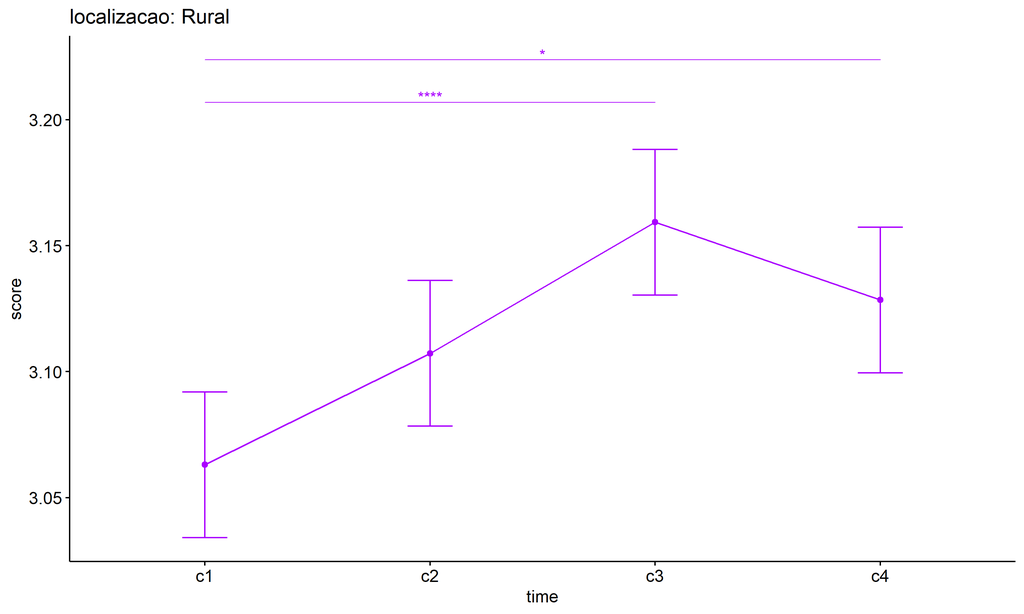

```r
emms.gg <- emms[which(emms$localizacao == "Rural"),]
if (nrow(emms.gg) > 0)
  ggline(emms.gg, x = "time", y = "emmean", color = "#AA00FF", ylab = "score") +
    geom_errorbar(aes(ymin = conf.low, ymax = conf.high),
                  width = 0.2, color = "#AA00FF") +
    stat_pvalue_manual(
      add_xy_position(pwc[which(pwc$localizacao == "Rural"),],
                      x = "time", fun = "mean_se"),
      hide.ns = T, color = "#AA00FF", tip.length = F) +
    labs(title = "localizacao: Rural")+
    theme(legend.text = element_blank())
```

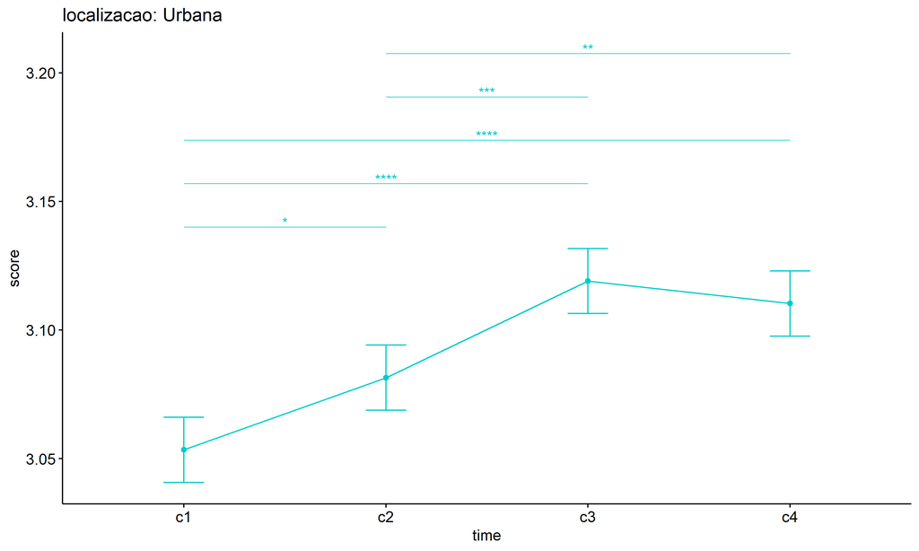

```r
emms.gg <- emms[which(emms$localizacao == "Urbana"),]
if (nrow(emms.gg) > 0)
  ggline(emms.gg, x = "time", y = "emmean", color = "#00CCCC", ylab = "score") +
    geom_errorbar(aes(ymin = conf.low, ymax = conf.high),
                  width = 0.2, color = "#00CCCC") +
    stat_pvalue_manual(
      add_xy_position(pwc[which(pwc$localizacao == "Urbana"),],
                      x = "time", fun = "mean_se"),
      hide.ns = T, color = "#00CCCC", tip.length = F) +
    labs(title = "localizacao: Urbana")+
    theme(legend.text = element_blank())
```

## PairWise Computation after removing non.normal data

```r
if (length(non.ids) > 0)
  (pwc2 <- ldat2 %>% group_by(time) %>%
     emmeans_test(score ~ localizacao, detailed = T, p.adjust.method = "bonferroni"))
```

```r
if (length(non.ids) > 0)
  (emms2 <- get_emmeans(pwc2))
```

```r
if (length(non.ids) > 0) {
  pwc2 <- add_xy_position(pwc2, x = "time", fun = "mean_se", dodge = 0.25)
  pd2 <- position_dodge(width = 0.25)

  ggline(emms2, x = "time", y = "emmean", color = "localizacao",
         palette = c("#AA00FF","#00CCCC"),
         position = pd, ylab = "score") +
    geom_errorbar(aes(ymin = conf.low, ymax = conf.high, color = localizacao),
                position = pd, width = 0.2) +
    stat_pvalue_manual(pwc2, hide.ns = T, tip.length = F, linetype = 1)
}
```

```r
if (length(non.ids) > 0)
  (pwc2 <- ldat2 %>% group_by(localizacao) %>%
     emmeans_test(score ~ time, detailed = T, p.adjust.method = "bonferroni"))
```

```r
if (length(non.ids) > 0)
  (emms2 <- get_emmeans(pwc2))
```

```r
if (length(non.ids) > 0) {
  emms.gg <- emms2[which(emms2$localizacao == "Rural"),]
  if (nrow(emms.gg) > 0)
    ggline(emms.gg, x = "time", y = "emmean", color = "#AA00FF", ylab = "score") +
    geom_errorbar(aes(ymin = conf.low, ymax = conf.high),
                  width = 0.2, color = "#AA00FF") +
    stat_pvalue_manual(
      add_xy_position(pwc[which(pwc$localizacao == "Rural"),],
                      x = "time", fun = "mean_se"),
      hide.ns = T, color = "#AA00FF", tip.length = F) +
    labs(title = "localizacao: Rural") +
    theme(legend.text = element_blank())
}
```

```r
if (length(non.ids) > 0) {
  emms.gg <- emms2[which(emms2$localizacao == "Urbana"),]
  if (nrow(emms.gg) > 0)
    ggline(emms.gg, x = "time", y = "emmean", color = "#00CCCC", ylab = "score") +
    geom_errorbar(aes(ymin = conf.low, ymax = conf.high),
                  width = 0.2, color = "#00CCCC") +
    stat_pvalue_manual(
      add_xy_position(pwc[which(pwc$localizacao == "Urbana"),],
                      x = "time", fun = "mean_se"),
      hide.ns = T, color = "#00CCCC", tip.length = F) +
    labs(title = "localizacao: Urbana") +
    theme(legend.text = element_blank())
}
```

# ANOVA: score ~ time*regiao + Error(id/time)

## Data Preparation

```r
data <- edat[,c("aluno_id","regiao","ciclo","score")]
data$ciclo <- factor(data$ciclo, c("Primeiro Ciclo","Segundo Ciclo",
                                   "Terceiro Ciclo","Quarto Ciclo"))

wdat <- spread(data, ciclo, score)
wdat <- wdat[complete.cases(wdat),]
colnames(wdat) <- c("id","regiao","c1","c2","c3","c4")

ldat <- gather(wdat, key = time, value = score, c1, c2, c3, c4) %>%
  convert_as_factor(id, time)
ldat <- remove_group_data(ldat, "score", c("time", "regiao"), n.limit = 30)
ldat$regiao <- factor(ldat$regiao, sort(unique(ldat$regiao)))
```

### Check assumptions: Identifying Outliers

```r
outliers <- identify_outliers(group_by(ldat, time, regiao), score)
(outliers <- outliers[outliers$is.extreme == T,])
```

```
## # A tibble: 17 × 6
##    regiao   time  id                   score is.outlier is.extreme
##    <fct>    <fct> <fct>                <dbl> <lgl>      <lgl>
##  1 Nordeste c1    0w3VhiMf67CbcpR6aZCL  3.83 TRUE       TRUE
##  2 Nordeste c1    D1HfJKTVqjrpCJx97l3v  3.75 TRUE       TRUE
##  3 Nordeste c1    Ru3SPRo97iXBvXbvneKh  3.83 TRUE       TRUE
##  4 Nordeste c1    uCBI6gnllsawWJlgqkr5  3.83 TRUE       TRUE
##  5 Nordeste c1    vc8pPoYau2AIAuCQJipW  3.83 TRUE       TRUE
##  6 Nordeste c2    cuknOzzwN4oCRum5U5ph  4    TRUE       TRUE
##  7 Nordeste c2    oGUJyWRMYYbF9PNegJZh  3.83 TRUE       TRUE
##  8 Nordeste c2    z3p6Ot4uvkPmGXOS9D3e  3.83 TRUE       TRUE
##  9 Sudeste  c2    HsQF2J0r79mHSWNe4l6n  3.83 TRUE       TRUE
## 10 Sudeste  c2    j31LU8Xwm0EQ7Mihkhjj  3.83 TRUE       TRUE
## 11 Nordeste c3    CCVIt7MPeYMUOCCyBxPh  4    TRUE       TRUE
## 12 Nordeste c3    i5EZ8Ck9IgDueyMbw55v  4    TRUE       TRUE
## 13 Nordeste c3    m5yRlxfIj73j4ossfTOB  4    TRUE       TRUE
## 14 Nordeste c3    RkRJsrzuZjQPcgr9Bu7D  3.83 TRUE       TRUE
## 15 Nordeste c4    1OE4fvPj9Y2Q9Bnwr0xz  3.83 TRUE       TRUE
## 16 Nordeste c4    kFvRH3RtPD461qVG04iW  3.83 TRUE       TRUE
## 17 Nordeste c4    PZJ6CleqURERCau51lXu  3.75 TRUE       TRUE
```

| regiao | time | id | score | is.outlier | is.extreme |
| --- | --- | --- | --- | --- | --- |
| Nordeste | c1 | 0w3VhiMf67CbcpR6aZCL | 3.833 | TRUE | TRUE |
| Nordeste | c1 | D1HfJKTVqjrpCJx97l3v | 3.750 | TRUE | TRUE |
| Nordeste | c1 | Ru3SPRo97iXBvXbvneKh | 3.833 | TRUE | TRUE |
| Nordeste | c1 | uCBI6gnllsawWJlgqkr5 | 3.833 | TRUE | TRUE |
| Nordeste | c1 | vc8pPoYau2AIAuCQJipW | 3.833 | TRUE | TRUE |
| Nordeste | c2 | cuknOzzwN4oCRum5U5ph | 4.000 | TRUE | TRUE |
| Nordeste | c2 | oGUJyWRMYYbF9PNegJZh | 3.833 | TRUE | TRUE |
| Nordeste | c2 | z3p6Ot4uvkPmGXOS9D3e | 3.833 | TRUE | TRUE |
| Sudeste | c2 | HsQF2J0r79mHSWNe4l6n | 3.833 | TRUE | TRUE |
| Sudeste | c2 | j31LU8Xwm0EQ7Mihkhjj | 3.833 | TRUE | TRUE |
| Nordeste | c3 | CCVIt7MPeYMUOCCyBxPh | 4.000 | TRUE | TRUE |
| Nordeste | c3 | i5EZ8Ck9IgDueyMbw55v | 4.000 | TRUE | TRUE |
| Nordeste | c3 | m5yRlxfIj73j4ossfTOB | 4.000 | TRUE | TRUE |
| Nordeste | c3 | RkRJsrzuZjQPcgr9Bu7D | 3.833 | TRUE | TRUE |
| Nordeste | c4 | 1OE4fvPj9Y2Q9Bnwr0xz | 3.833 | TRUE | TRUE |
| Nordeste | c4 | kFvRH3RtPD461qVG04iW | 3.833 | TRUE | TRUE |
| Nordeste | c4 | PZJ6CleqURERCau51lXu | 3.750 | TRUE | TRUE |

### Check assumptions: Normality Test

```r
(normality.df <- normality.test.per.groups(ldat, "score", c("time", "regiao")))
```

```
##      var variable time       regiao   n    skewness    kurtosis symmetry   statistic
## 1  score    score   c1 Centro-Oeste  48  1.49462737  3.87523302       NO   0.8603051
## 2  score    score   c1     Nordeste 545  0.93748206  2.75683441       NO 101.2637654
## 3  score    score   c1        Norte  78  0.38150092  0.05709334      YES   2.5458637
## 4  score    score   c1      Sudeste 393  0.57704959  1.21599484       NO  32.1482328
## 5  score    score   c1          Sul  62  0.60989205  0.58781560       NO   6.2481067
## 6  score    score   c2 Centro-Oeste  48  0.09312193 -0.81019032      YES   0.9346137
## 7  score    score   c2     Nordeste 545  0.85100607  1.76346567       NO  77.4447656
## 8  score    score   c2        Norte  78  0.20352434  0.30673735      YES   1.7054526
## 9  score    score   c2      Sudeste 393  0.95634123  1.62265432       NO  63.2834519
## 10 score    score   c2          Sul  62 -0.22520685  0.87650652      YES   3.5931948
## 11 score    score   c3 Centro-Oeste  48  1.06032260  0.31589047       NO   0.8697445
## 12 score    score   c3     Nordeste 545  1.08351447  1.31095456       NO  93.3343213
## 13 score    score   c3        Norte  78  0.36547003 -0.21658994      YES   2.0034155
## 14 score    score   c3      Sudeste 393  0.73840973  0.20764987       NO  31.3786296
```

[output cut: 27 more lines]

| var | variable | time | regiao | n | skewness | kurtosis | symmetry | statistic | method | p | p.signif | normality |
| --- | --- | --- | --- | --- | --- | --- | --- | --- | --- | --- | --- | --- |
| score | score | c1 | Centro-Oeste | 48 | 1.495 | 3.875 | NO | 0.860 | Shapiro-Wilk | 0.000 | **** | NO |
| score | score | c1 | Nordeste | 545 | 0.937 | 2.757 | NO | 101.264 | D’Agostino | 0.000 | **** | - |
| score | score | c1 | Norte | 78 | 0.382 | 0.057 | YES | 2.546 | D’Agostino | 0.280 | ns | YES |
| score | score | c1 | Sudeste | 393 | 0.577 | 1.216 | NO | 32.148 | D’Agostino | 0.000 | **** | - |
| score | score | c1 | Sul | 62 | 0.610 | 0.588 | NO | 6.248 | D’Agostino | 0.044 | * | NO |
| score | score | c2 | Centro-Oeste | 48 | 0.093 | -0.810 | YES | 0.935 | Shapiro-Wilk | 0.010 | * | NO |
| score | score | c2 | Nordeste | 545 | 0.851 | 1.763 | NO | 77.445 | D’Agostino | 0.000 | **** | - |
| score | score | c2 | Norte | 78 | 0.204 | 0.307 | YES | 1.705 | D’Agostino | 0.426 | ns | YES |
| score | score | c2 | Sudeste | 393 | 0.956 | 1.623 | NO | 63.283 | D’Agostino | 0.000 | **** | - |
| score | score | c2 | Sul | 62 | -0.225 | 0.877 | YES | 3.593 | D’Agostino | 0.166 | ns | YES |
| score | score | c3 | Centro-Oeste | 48 | 1.060 | 0.316 | NO | 0.870 | Shapiro-Wilk | 0.000 | **** | NO |
| score | score | c3 | Nordeste | 545 | 1.084 | 1.311 | NO | 93.334 | D’Agostino | 0.000 | **** | - |
| score | score | c3 | Norte | 78 | 0.365 | -0.217 | YES | 2.003 | D’Agostino | 0.367 | ns | YES |
| score | score | c3 | Sudeste | 393 | 0.738 | 0.208 | NO | 31.379 | D’Agostino | 0.000 | **** | - |
| score | score | c3 | Sul | 62 | 0.815 | 0.481 | NO | 8.698 | D’Agostino | 0.013 | * | NO |
| score | score | c4 | Centro-Oeste | 48 | 0.673 | 1.007 | NO | 0.912 | Shapiro-Wilk | 0.002 | ** | NO |
| score | score | c4 | Nordeste | 545 | 1.019 | 1.380 | NO | 87.915 | D’Agostino | 0.000 | **** | - |
| score | score | c4 | Norte | 78 | 0.815 | 1.275 | NO | 13.194 | D’Agostino | 0.001 | ** | NO |
| score | score | c4 | Sudeste | 393 | 0.673 | 0.171 | NO | 26.783 | D’Agostino | 0.000 | **** | - |
| score | score | c4 | Sul | 62 | 0.479 | -0.300 | YES | 2.767 | D’Agostino | 0.251 | ns | YES |

```r
(non.ids <- unique(do.call(
  c, lapply(which(normality.df$normality == 'NO'), FUN = function(i) {
  idx = which(ldat$time == normality.df$time[i] &
                ldat$regiao == normality.df$regiao[i])
  getNonNormal(ldat$"score"[idx], ldat$id[idx])
}))))
```

```
##  [1] "1Z1Qz8zDaMkaAz1Ah80K" "3fTmP8cTTJq8WUIEU0Xl" "3mBgwnK6Vvt3dkhVOTAf" "8p6QYQYkfhR3QOACXZvj"
##  [5] "ZwZKuoXF7JaYzVxPoHvk" "WCSObSsiS3xWwGKtJ3Wu" "9jd1C85ixCoJf3EINYfx" "gzBUwnjjYHnioTnd4stC"
##  [9] "0HZYO8qt2G3sqgoXITwe" "uqX7aPoHn8tMaKAp9y3I" "sXB3m8f7P40lRXYwY22p" "D5ZRR3Ps7EtPoEi233KU"
## [13] "sRR37KpbkBZSh9H2UpSB" "LC1uBEBe3hZn8Q1mQe7A" "OTNUMYnL8AF930i7Db8H" "wSTeItj2YyZhZQ0kiCqW"
## [17] "vSolOA78V6l7oYJ1h4LA" "18EWxrJZtjBVpzckkv21" "pX3oKxaMTnCJ8g1GtRWG" "fCbOJlY4s8hncfy108S2"
## [21] "TupwpKp0mSf2xCyx7nhJ" "3ETydorel7bIDQKYclir" "OvwAQTWkdj8SYpPS8dgn" "edONhkMBY1DIsXNuuodO"
## [25] "t7y3FwNYyKYp3l9JHFSZ" "LSOWrW4dOhXZ9uMW17va" "q2OHBM4WxXWQPFhPS0zC" "XPDsLJmk5xRPBBQTOEFf"
## [29] "AIyVJKr8sUUkQIogcjw3" "AIzwxJCfbDsO8ZT4ZZ4h" "vvjX443BD3mkWYYMec2R" "dKIqav6TRc1lClMWW6hS"
## [33] "AH1sCf7O5jOA17AZz4Sv" "knPmAE3VLSnirKKQgoQL"
```

```r
if (length(non.ids) > 0)
  ldat2 <- ldat[!ldat$id %in% non.ids,]
```

### Summary Statistics

```r
(sdat <- ldat %>% group_by(time, regiao) %>%
   get_summary_stats(score, type = "mean_sd"))
```

```
## # A tibble: 20 × 6
##    regiao       time  variable     n  mean    sd
##    <fct>        <fct> <fct>    <dbl> <dbl> <dbl>
##  1 Centro-Oeste c1    score       48  3.05 0.189
##  2 Nordeste     c1    score      545  3.07 0.185
##  3 Norte        c1    score       78  3.06 0.114
##  4 Sudeste      c1    score      393  3.04 0.168
##  5 Sul          c1    score       62  3.01 0.162
##  6 Centro-Oeste c2    score       48  3.09 0.144
##  7 Nordeste     c2    score      545  3.10 0.195
##  8 Norte        c2    score       78  3.04 0.156
##  9 Sudeste      c2    score      393  3.09 0.2
## 10 Sul          c2    score       62  3.04 0.143
## 11 Centro-Oeste c3    score       48  3.16 0.202
## 12 Nordeste     c3    score      545  3.13 0.215
## 13 Norte        c3    score       78  3.08 0.127
## 14 Sudeste      c3    score      393  3.12 0.228
## 15 Sul          c3    score       62  3.14 0.223
## 16 Centro-Oeste c4    score       48  3.13 0.193
## 17 Nordeste     c4    score      545  3.10 0.202
## 18 Norte        c4    score       78  3.1  0.175
## 19 Sudeste      c4    score      393  3.13 0.225
## 20 Sul          c4    score       62  3.16 0.236
```

| regiao | time | variable | n | mean | sd |
| --- | --- | --- | --- | --- | --- |
| Centro-Oeste | c1 | score | 48 | 3.054 | 0.189 |
| Nordeste | c1 | score | 545 | 3.069 | 0.185 |
| Norte | c1 | score | 78 | 3.056 | 0.114 |
| Sudeste | c1 | score | 393 | 3.043 | 0.168 |
| Sul | c1 | score | 62 | 3.012 | 0.162 |
| Centro-Oeste | c2 | score | 48 | 3.091 | 0.144 |
| Nordeste | c2 | score | 545 | 3.096 | 0.195 |
| Norte | c2 | score | 78 | 3.036 | 0.156 |
| Sudeste | c2 | score | 393 | 3.088 | 0.200 |
| Sul | c2 | score | 62 | 3.036 | 0.143 |
| Centro-Oeste | c3 | score | 48 | 3.156 | 0.202 |
| Nordeste | c3 | score | 545 | 3.128 | 0.215 |
| Norte | c3 | score | 78 | 3.081 | 0.127 |
| Sudeste | c3 | score | 393 | 3.125 | 0.228 |
| Sul | c3 | score | 62 | 3.138 | 0.223 |
| Centro-Oeste | c4 | score | 48 | 3.128 | 0.193 |
| Nordeste | c4 | score | 545 | 3.098 | 0.202 |
| Norte | c4 | score | 78 | 3.100 | 0.175 |
| Sudeste | c4 | score | 393 | 3.127 | 0.225 |
| Sul | c4 | score | 62 | 3.163 | 0.236 |

```r
if (length(non.ids) > 0)
  (sdat <- ldat2 %>% group_by(time, regiao) %>%
      get_summary_stats(score, type = "mean_sd"))
```

```
## # A tibble: 20 × 6
##    regiao       time  variable     n  mean    sd
##    <fct>        <fct> <fct>    <dbl> <dbl> <dbl>
##  1 Centro-Oeste c1    score       18  3.07 0.167
##  2 Nordeste     c1    score      545  3.07 0.185
##  3 Norte        c1    score       76  3.06 0.115
##  4 Sudeste      c1    score      393  3.04 0.168
##  5 Sul          c1    score       60  3.00 0.152
##  6 Centro-Oeste c2    score       18  3.10 0.118
##  7 Nordeste     c2    score      545  3.10 0.195
##  8 Norte        c2    score       76  3.04 0.157
##  9 Sudeste      c2    score      393  3.09 0.2
## 10 Sul          c2    score       60  3.03 0.144
## 11 Centro-Oeste c3    score       18  3.12 0.125
## 12 Nordeste     c3    score      545  3.13 0.215
## 13 Norte        c3    score       76  3.08 0.123
## 14 Sudeste      c3    score      393  3.12 0.228
## 15 Sul          c3    score       60  3.13 0.208
## 16 Centro-Oeste c4    score       18  3.08 0.15
## 17 Nordeste     c4    score      545  3.10 0.202
## 18 Norte        c4    score       76  3.09 0.151
## 19 Sudeste      c4    score      393  3.13 0.225
## 20 Sul          c4    score       60  3.16 0.24
```

| regiao | time | variable | n | mean | sd |
| --- | --- | --- | --- | --- | --- |
| Centro-Oeste | c1 | score | 18 | 3.069 | 0.167 |
| Nordeste | c1 | score | 545 | 3.069 | 0.185 |
| Norte | c1 | score | 76 | 3.055 | 0.115 |
| Sudeste | c1 | score | 393 | 3.043 | 0.168 |
| Sul | c1 | score | 60 | 3.003 | 0.152 |
| Centro-Oeste | c2 | score | 18 | 3.105 | 0.118 |
| Nordeste | c2 | score | 545 | 3.096 | 0.195 |
| Norte | c2 | score | 76 | 3.036 | 0.157 |
| Sudeste | c2 | score | 393 | 3.088 | 0.200 |
| Sul | c2 | score | 60 | 3.034 | 0.144 |
| Centro-Oeste | c3 | score | 18 | 3.116 | 0.125 |
| Nordeste | c3 | score | 545 | 3.128 | 0.215 |
| Norte | c3 | score | 76 | 3.078 | 0.123 |
| Sudeste | c3 | score | 393 | 3.125 | 0.228 |
| Sul | c3 | score | 60 | 3.126 | 0.208 |
| Centro-Oeste | c4 | score | 18 | 3.079 | 0.150 |
| Nordeste | c4 | score | 545 | 3.098 | 0.202 |
| Norte | c4 | score | 76 | 3.086 | 0.151 |
| Sudeste | c4 | score | 393 | 3.127 | 0.225 |
| Sul | c4 | score | 60 | 3.163 | 0.240 |

## ANOVA Computation

```r
(res.aov <- anova_test(ldat, dv = score, wid = id, between = regiao, within = time))
```

```
## ANOVA Table (type III tests)
##
## $ANOVA
##        Effect DFn  DFd      F        p p<.05   ges
## 1      regiao   4 1121  1.463 2.11e-01       0.002
## 2        time   3 3363 19.826 9.76e-13     * 0.012
## 3 regiao:time  12 3363  2.279 7.00e-03     * 0.006
##
## $`Mauchly's Test for Sphericity`
##        Effect     W     p p<.05
## 1        time 0.986 0.008     *
## 2 regiao:time 0.986 0.008     *
##
## $`Sphericity Corrections`
##        Effect   GGe        DF[GG]   p[GG] p[GG]<.05   HFe         DF[HF]    p[HF] p[HF]<.05
## 1        time 0.991  2.97, 3333.5 1.2e-12         * 0.994  2.98, 3343.34 1.12e-12         *
## 2 regiao:time 0.991 11.89, 3333.5 7.0e-03         * 0.994 11.93, 3343.34 7.00e-03         *
```

| Effect | DFn | DFd | F | p | p<.05 | ges |
| --- | --- | --- | --- | --- | --- | --- |
| regiao | 4 | 1121 | 1.463 | 0.211 |  | 0.002 |
| time | 3 | 3363 | 19.826 | 0.000 | * | 0.012 |
| regiao:time | 12 | 3363 | 2.279 | 0.007 | * | 0.006 |

| Effect | W | p | p<.05 |
| --- | --- | --- | --- |
| time | 0.986 | 0.008 | * |
| regiao:time | 0.986 | 0.008 | * |

| Effect | GGe | DF[GG] | p[GG] | p[GG]<.05 | HFe | DF[HF] | p[HF] | p[HF]<.05 |
| --- | --- | --- | --- | --- | --- | --- | --- | --- |
| time | 0.991 | 2.97, 3333.5 | 0.000 | * | 0.994 | 2.98, 3343.34 | 0.000 | * |
| regiao:time | 0.991 | 11.89, 3333.5 | 0.007 | * | 0.994 | 11.93, 3343.34 | 0.007 | * |

## ANOVA Computation after removing non.normal data

```r
if (length(non.ids) > 0)
  (res.aov2 <- anova_test(ldat2, dv = score, wid = id, between = regiao , within = time))
```

```
## ANOVA Table (type III tests)
##
## $ANOVA
##        Effect DFn  DFd     F        p p<.05   ges
## 1      regiao   4 1087 1.840 1.19e-01       0.002
## 2        time   3 3261 7.968 2.72e-05     * 0.005
## 3 regiao:time  12 3261 2.281 7.00e-03     * 0.006
##
## $`Mauchly's Test for Sphericity`
##        Effect     W     p p<.05
## 1        time 0.989 0.037     *
## 2 regiao:time 0.989 0.037     *
##
## $`Sphericity Corrections`
##        Effect   GGe         DF[GG]    p[GG] p[GG]<.05   HFe        DF[HF]    p[HF] p[HF]<.05
## 1        time 0.993  2.98, 3238.32 2.87e-05         * 0.996  2.99, 3248.2 2.81e-05         *
## 2 regiao:time 0.993 11.92, 3238.32 7.00e-03         * 0.996 11.95, 3248.2 7.00e-03         *
```

| Effect | DFn | DFd | F | p | p<.05 | ges |
| --- | --- | --- | --- | --- | --- | --- |
| regiao | 4 | 1087 | 1.840 | 0.119 |  | 0.002 |
| time | 3 | 3261 | 7.968 | 0.000 | * | 0.005 |
| regiao:time | 12 | 3261 | 2.281 | 0.007 | * | 0.006 |

| Effect | W | p | p<.05 |
| --- | --- | --- | --- |
| time | 0.989 | 0.037 | * |
| regiao:time | 0.989 | 0.037 | * |

| Effect | GGe | DF[GG] | p[GG] | p[GG]<.05 | HFe | DF[HF] | p[HF] | p[HF]<.05 |
| --- | --- | --- | --- | --- | --- | --- | --- | --- |
| time | 0.993 | 2.98, 3238.32 | 0.000 | * | 0.996 | 2.99, 3248.2 | 0.000 | * |
| regiao:time | 0.993 | 11.92, 3238.32 | 0.007 | * | 0.996 | 11.95, 3248.2 | 0.007 | * |

## PairWise Computation

```r
(pwc <- ldat %>% group_by(time) %>%
   emmeans_test(score ~ regiao, detailed = T, p.adjust.method = "bonferroni"))
```

[output not shown]

```r
(emms <- get_emmeans(pwc))
```

```
## # A tibble: 20 × 8
##    time  regiao       emmean      se    df conf.low conf.high method
##    <fct> <fct>         <dbl>   <dbl> <dbl>    <dbl>     <dbl> <chr>
##  1 c1    Centro-Oeste   3.05 0.0286   4484     3.00      3.11 Emmeans test
##  2 c1    Nordeste       3.07 0.00848  4484     3.05      3.09 Emmeans test
##  3 c1    Norte          3.06 0.0224   4484     3.01      3.10 Emmeans test
##  4 c1    Sudeste        3.04 0.00999  4484     3.02      3.06 Emmeans test
##  5 c1    Sul            3.01 0.0252   4484     2.96      3.06 Emmeans test
##  6 c2    Centro-Oeste   3.09 0.0286   4484     3.04      3.15 Emmeans test
##  7 c2    Nordeste       3.10 0.00848  4484     3.08      3.11 Emmeans test
##  8 c2    Norte          3.04 0.0224   4484     2.99      3.08 Emmeans test
##  9 c2    Sudeste        3.09 0.00999  4484     3.07      3.11 Emmeans test
## 10 c2    Sul            3.04 0.0252   4484     2.99      3.08 Emmeans test
## 11 c3    Centro-Oeste   3.16 0.0286   4484     3.10      3.21 Emmeans test
## 12 c3    Nordeste       3.13 0.00848  4484     3.11      3.14 Emmeans test
## 13 c3    Norte          3.08 0.0224   4484     3.04      3.13 Emmeans test
## 14 c3    Sudeste        3.12 0.00999  4484     3.11      3.14 Emmeans test
## 15 c3    Sul            3.14 0.0252   4484     3.09      3.19 Emmeans test
## 16 c4    Centro-Oeste   3.13 0.0286   4484     3.07      3.18 Emmeans test
## 17 c4    Nordeste       3.10 0.00848  4484     3.08      3.11 Emmeans test
## 18 c4    Norte          3.10 0.0224   4484     3.06      3.14 Emmeans test
## 19 c4    Sudeste        3.13 0.00999  4484     3.11      3.15 Emmeans test
## 20 c4    Sul            3.16 0.0252   4484     3.11      3.21 Emmeans test
```

| time | regiao | emmean | se | df | conf.low | conf.high | method |
| --- | --- | --- | --- | --- | --- | --- | --- |
| c1 | Centro-Oeste | 3.054 | 0.029 | 4484 | 2.998 | 3.110 | Emmeans test |
| c1 | Nordeste | 3.069 | 0.008 | 4484 | 3.052 | 3.085 | Emmeans test |
| c1 | Norte | 3.056 | 0.022 | 4484 | 3.012 | 3.100 | Emmeans test |
| c1 | Sudeste | 3.043 | 0.010 | 4484 | 3.023 | 3.062 | Emmeans test |
| c1 | Sul | 3.012 | 0.025 | 4484 | 2.963 | 3.061 | Emmeans test |
| c2 | Centro-Oeste | 3.091 | 0.029 | 4484 | 3.035 | 3.147 | Emmeans test |
| c2 | Nordeste | 3.096 | 0.008 | 4484 | 3.080 | 3.113 | Emmeans test |
| c2 | Norte | 3.036 | 0.022 | 4484 | 2.992 | 3.080 | Emmeans test |
| c2 | Sudeste | 3.088 | 0.010 | 4484 | 3.068 | 3.107 | Emmeans test |
| c2 | Sul | 3.036 | 0.025 | 4484 | 2.986 | 3.085 | Emmeans test |
| c3 | Centro-Oeste | 3.156 | 0.029 | 4484 | 3.100 | 3.212 | Emmeans test |
| c3 | Nordeste | 3.128 | 0.008 | 4484 | 3.112 | 3.145 | Emmeans test |
| c3 | Norte | 3.081 | 0.022 | 4484 | 3.037 | 3.125 | Emmeans test |
| c3 | Sudeste | 3.125 | 0.010 | 4484 | 3.105 | 3.144 | Emmeans test |
| c3 | Sul | 3.138 | 0.025 | 4484 | 3.089 | 3.188 | Emmeans test |
| c4 | Centro-Oeste | 3.128 | 0.029 | 4484 | 3.072 | 3.185 | Emmeans test |
| c4 | Nordeste | 3.098 | 0.008 | 4484 | 3.081 | 3.115 | Emmeans test |
| c4 | Norte | 3.100 | 0.022 | 4484 | 3.056 | 3.144 | Emmeans test |
| c4 | Sudeste | 3.127 | 0.010 | 4484 | 3.108 | 3.147 | Emmeans test |
| c4 | Sul | 3.163 | 0.025 | 4484 | 3.113 | 3.212 | Emmeans test |

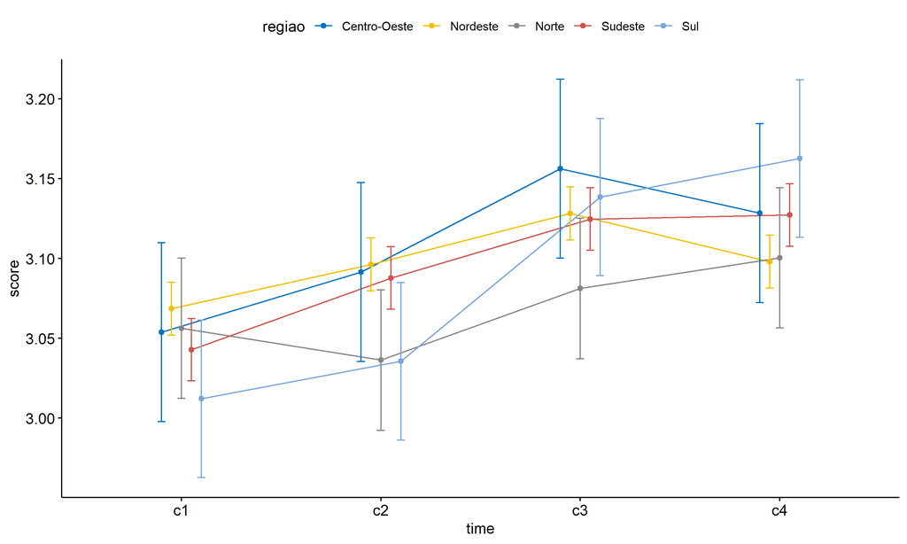

```r
pwc <- add_xy_position(pwc, x = "time", fun = "mean_se", dodge = 0.25)
pd <- position_dodge(width = 0.25)
ggline(emms, x = "time", y = "emmean", color = "regiao",
       palette = c("#0073C2FF","#EFC000FF","#868686FF","#CD534CFF","#7AA6DCFF"),
       position = pd, ylab = "score") +
  geom_errorbar(aes(ymin = conf.low, ymax = conf.high, color = regiao),
                position = pd, width = 0.2) +
  stat_pvalue_manual(pwc, hide.ns = T, tip.length = F, linetype = 1)
```

```r
(pwc <- ldat %>% group_by(regiao) %>%
    emmeans_test(score ~ time, detailed = T, p.adjust.method = "bonferroni"))
```

```
## # A tibble: 30 × 15
##    regiao term  .y.   group1 group2 null.value estimate     se    df conf.low conf.high statistic
##  * <fct>  <chr> <chr> <chr>  <chr>       <dbl>    <dbl>  <dbl> <dbl>    <dbl>     <dbl>     <dbl>
##  1 Centr… time  score c1     c2              0  -0.0376 0.0404  4484  -0.117    0.0416     -0.930
##  2 Centr… time  score c1     c3              0  -0.102  0.0404  4484  -0.182   -0.0232     -2.53
##  3 Centr… time  score c1     c4              0  -0.0747 0.0404  4484  -0.154    0.00461    -1.85
##  4 Centr… time  score c2     c3              0  -0.0648 0.0404  4484  -0.144    0.0144     -1.60
##  5 Centr… time  score c2     c4              0  -0.0370 0.0404  4484  -0.116    0.0422     -0.916
##  6 Centr… time  score c3     c4              0   0.0278 0.0404  4484  -0.0515   0.107       0.687
##  7 Norde… time  score c1     c2              0  -0.0278 0.0120  4484  -0.0513  -0.00428    -2.32
##  8 Norde… time  score c1     c3              0  -0.0598 0.0120  4484  -0.0833  -0.0363     -4.98
##  9 Norde… time  score c1     c4              0  -0.0295 0.0120  4484  -0.0530  -0.00599    -2.46
## 10 Norde… time  score c2     c3              0  -0.0320 0.0120  4484  -0.0555  -0.00846    -2.67
## # ℹ 20 more rows
## # ℹ 3 more variables: p <dbl>, p.adj <dbl>, p.adj.signif <chr>
```

| regiao | term | .y. | group1 | group2 | null.value | estimate | se | df | conf.low | conf.high | statistic | p | p.adj | p.adj.signif |
| --- | --- | --- | --- | --- | --- | --- | --- | --- | --- | --- | --- | --- | --- | --- |
| Centro-Oeste | time | score | c1 | c2 | 0 | -0.038 | 0.040 | 4484 | -0.117 | 0.042 | -0.930 | 0.352 | 1.000 | ns |
| Centro-Oeste | time | score | c1 | c3 | 0 | -0.102 | 0.040 | 4484 | -0.182 | -0.023 | -2.534 | 0.011 | 0.068 | ns |
| Centro-Oeste | time | score | c1 | c4 | 0 | -0.075 | 0.040 | 4484 | -0.154 | 0.005 | -1.847 | 0.065 | 0.389 | ns |
| Centro-Oeste | time | score | c2 | c3 | 0 | -0.065 | 0.040 | 4484 | -0.144 | 0.014 | -1.603 | 0.109 | 0.654 | ns |
| Centro-Oeste | time | score | c2 | c4 | 0 | -0.037 | 0.040 | 4484 | -0.116 | 0.042 | -0.916 | 0.360 | 1.000 | ns |
| Centro-Oeste | time | score | c3 | c4 | 0 | 0.028 | 0.040 | 4484 | -0.051 | 0.107 | 0.687 | 0.492 | 1.000 | ns |
| Nordeste | time | score | c1 | c2 | 0 | -0.028 | 0.012 | 4484 | -0.051 | -0.004 | -2.317 | 0.021 | 0.123 | ns |
| Nordeste | time | score | c1 | c3 | 0 | -0.060 | 0.012 | 4484 | -0.083 | -0.036 | -4.983 | 0.000 | 0.000 | **** |
| Nordeste | time | score | c1 | c4 | 0 | -0.030 | 0.012 | 4484 | -0.053 | -0.006 | -2.460 | 0.014 | 0.084 | ns |
| Nordeste | time | score | c2 | c3 | 0 | -0.032 | 0.012 | 4484 | -0.056 | -0.008 | -2.666 | 0.008 | 0.046 | * |
| Nordeste | time | score | c2 | c4 | 0 | -0.002 | 0.012 | 4484 | -0.025 | 0.022 | -0.142 | 0.887 | 1.000 | ns |
| Nordeste | time | score | c3 | c4 | 0 | 0.030 | 0.012 | 4484 | 0.007 | 0.054 | 2.523 | 0.012 | 0.070 | ns |
| Norte | time | score | c1 | c2 | 0 | 0.020 | 0.032 | 4484 | -0.042 | 0.082 | 0.629 | 0.529 | 1.000 | ns |
| Norte | time | score | c1 | c3 | 0 | -0.025 | 0.032 | 4484 | -0.087 | 0.037 | -0.786 | 0.432 | 1.000 | ns |
| Norte | time | score | c1 | c4 | 0 | -0.044 | 0.032 | 4484 | -0.106 | 0.018 | -1.392 | 0.164 | 0.983 | ns |
| Norte | time | score | c2 | c3 | 0 | -0.045 | 0.032 | 4484 | -0.107 | 0.017 | -1.415 | 0.157 | 0.943 | ns |
| Norte | time | score | c2 | c4 | 0 | -0.064 | 0.032 | 4484 | -0.126 | -0.002 | -2.021 | 0.043 | 0.260 | ns |
| Norte | time | score | c3 | c4 | 0 | -0.019 | 0.032 | 4484 | -0.081 | 0.043 | -0.606 | 0.544 | 1.000 | ns |
| Sudeste | time | score | c1 | c2 | 0 | -0.045 | 0.014 | 4484 | -0.073 | -0.017 | -3.179 | 0.001 | 0.009 | ** |
| Sudeste | time | score | c1 | c3 | 0 | -0.082 | 0.014 | 4484 | -0.110 | -0.054 | -5.793 | 0.000 | 0.000 | **** |
| Sudeste | time | score | c1 | c4 | 0 | -0.084 | 0.014 | 4484 | -0.112 | -0.057 | -5.973 | 0.000 | 0.000 | **** |
| Sudeste | time | score | c2 | c3 | 0 | -0.037 | 0.014 | 4484 | -0.065 | -0.009 | -2.614 | 0.009 | 0.054 | ns |
| Sudeste | time | score | c2 | c4 | 0 | -0.039 | 0.014 | 4484 | -0.067 | -0.012 | -2.794 | 0.005 | 0.031 | * |
| Sudeste | time | score | c3 | c4 | 0 | -0.003 | 0.014 | 4484 | -0.030 | 0.025 | -0.180 | 0.857 | 1.000 | ns |
| Sul | time | score | c1 | c2 | 0 | -0.024 | 0.036 | 4484 | -0.093 | 0.046 | -0.661 | 0.509 | 1.000 | ns |
| Sul | time | score | c1 | c3 | 0 | -0.126 | 0.036 | 4484 | -0.196 | -0.057 | -3.552 | 0.000 | 0.002 | ** |
| Sul | time | score | c1 | c4 | 0 | -0.151 | 0.036 | 4484 | -0.220 | -0.081 | -4.232 | 0.000 | 0.000 | *** |
| Sul | time | score | c2 | c3 | 0 | -0.103 | 0.036 | 4484 | -0.173 | -0.033 | -2.891 | 0.004 | 0.023 | * |
| Sul | time | score | c2 | c4 | 0 | -0.127 | 0.036 | 4484 | -0.197 | -0.057 | -3.571 | 0.000 | 0.002 | ** |
| Sul | time | score | c3 | c4 | 0 | -0.024 | 0.036 | 4484 | -0.094 | 0.046 | -0.680 | 0.496 | 1.000 | ns |

```r
(emms <- get_emmeans(pwc))
```

```
## # A tibble: 20 × 8
##    regiao       time  emmean      se    df conf.low conf.high method
##    <fct>        <fct>  <dbl>   <dbl> <dbl>    <dbl>     <dbl> <chr>
##  1 Centro-Oeste c1      3.05 0.0286   4484     3.00      3.11 Emmeans test
##  2 Centro-Oeste c2      3.09 0.0286   4484     3.04      3.15 Emmeans test
##  3 Centro-Oeste c3      3.16 0.0286   4484     3.10      3.21 Emmeans test
##  4 Centro-Oeste c4      3.13 0.0286   4484     3.07      3.18 Emmeans test
##  5 Nordeste     c1      3.07 0.00848  4484     3.05      3.09 Emmeans test
##  6 Nordeste     c2      3.10 0.00848  4484     3.08      3.11 Emmeans test
##  7 Nordeste     c3      3.13 0.00848  4484     3.11      3.14 Emmeans test
##  8 Nordeste     c4      3.10 0.00848  4484     3.08      3.11 Emmeans test
##  9 Norte        c1      3.06 0.0224   4484     3.01      3.10 Emmeans test
## 10 Norte        c2      3.04 0.0224   4484     2.99      3.08 Emmeans test
## 11 Norte        c3      3.08 0.0224   4484     3.04      3.13 Emmeans test
## 12 Norte        c4      3.10 0.0224   4484     3.06      3.14 Emmeans test
## 13 Sudeste      c1      3.04 0.00999  4484     3.02      3.06 Emmeans test
## 14 Sudeste      c2      3.09 0.00999  4484     3.07      3.11 Emmeans test
## 15 Sudeste      c3      3.12 0.00999  4484     3.11      3.14 Emmeans test
## 16 Sudeste      c4      3.13 0.00999  4484     3.11      3.15 Emmeans test
## 17 Sul          c1      3.01 0.0252   4484     2.96      3.06 Emmeans test
## 18 Sul          c2      3.04 0.0252   4484     2.99      3.08 Emmeans test
## 19 Sul          c3      3.14 0.0252   4484     3.09      3.19 Emmeans test
## 20 Sul          c4      3.16 0.0252   4484     3.11      3.21 Emmeans test
```

| regiao | time | emmean | se | df | conf.low | conf.high | method |
| --- | --- | --- | --- | --- | --- | --- | --- |
| Centro-Oeste | c1 | 3.054 | 0.029 | 4484 | 2.998 | 3.110 | Emmeans test |
| Centro-Oeste | c2 | 3.091 | 0.029 | 4484 | 3.035 | 3.147 | Emmeans test |
| Centro-Oeste | c3 | 3.156 | 0.029 | 4484 | 3.100 | 3.212 | Emmeans test |
| Centro-Oeste | c4 | 3.128 | 0.029 | 4484 | 3.072 | 3.185 | Emmeans test |
| Nordeste | c1 | 3.069 | 0.008 | 4484 | 3.052 | 3.085 | Emmeans test |
| Nordeste | c2 | 3.096 | 0.008 | 4484 | 3.080 | 3.113 | Emmeans test |
| Nordeste | c3 | 3.128 | 0.008 | 4484 | 3.112 | 3.145 | Emmeans test |
| Nordeste | c4 | 3.098 | 0.008 | 4484 | 3.081 | 3.115 | Emmeans test |
| Norte | c1 | 3.056 | 0.022 | 4484 | 3.012 | 3.100 | Emmeans test |
| Norte | c2 | 3.036 | 0.022 | 4484 | 2.992 | 3.080 | Emmeans test |
| Norte | c3 | 3.081 | 0.022 | 4484 | 3.037 | 3.125 | Emmeans test |
| Norte | c4 | 3.100 | 0.022 | 4484 | 3.056 | 3.144 | Emmeans test |
| Sudeste | c1 | 3.043 | 0.010 | 4484 | 3.023 | 3.062 | Emmeans test |
| Sudeste | c2 | 3.088 | 0.010 | 4484 | 3.068 | 3.107 | Emmeans test |
| Sudeste | c3 | 3.125 | 0.010 | 4484 | 3.105 | 3.144 | Emmeans test |
| Sudeste | c4 | 3.127 | 0.010 | 4484 | 3.108 | 3.147 | Emmeans test |
| Sul | c1 | 3.012 | 0.025 | 4484 | 2.963 | 3.061 | Emmeans test |
| Sul | c2 | 3.036 | 0.025 | 4484 | 2.986 | 3.085 | Emmeans test |
| Sul | c3 | 3.138 | 0.025 | 4484 | 3.089 | 3.188 | Emmeans test |
| Sul | c4 | 3.163 | 0.025 | 4484 | 3.113 | 3.212 | Emmeans test |

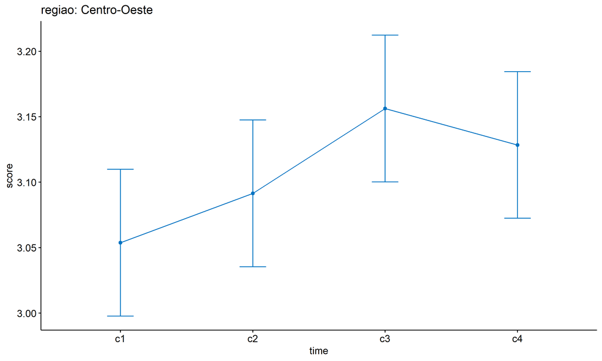

```r
emms.gg <- emms[which(emms$regiao == "Centro-Oeste"),]
if (nrow(emms.gg) > 0)
  ggline(emms.gg, x = "time", y = "emmean", color = "#0073C2FF", ylab = "score") +
    geom_errorbar(aes(ymin = conf.low, ymax = conf.high),
                  width = 0.2, color = "#0073C2FF") +
    stat_pvalue_manual(
      add_xy_position(pwc[which(pwc$regiao == "Centro-Oeste"),],
                      x = "time", fun = "mean_se"),
      hide.ns = T, color = "#0073C2FF", tip.length = F) +
    labs(title = "regiao: Centro-Oeste")+
    theme(legend.text = element_blank())
```

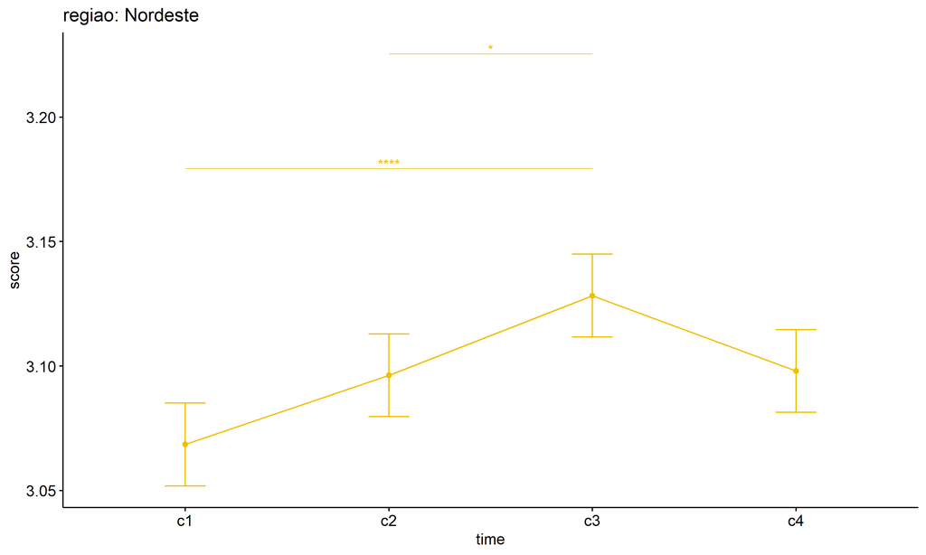

```r
emms.gg <- emms[which(emms$regiao == "Nordeste"),]
if (nrow(emms.gg) > 0)
  ggline(emms.gg, x = "time", y = "emmean", color = "#EFC000FF", ylab = "score") +
    geom_errorbar(aes(ymin = conf.low, ymax = conf.high),
                  width = 0.2, color = "#EFC000FF") +
    stat_pvalue_manual(
      add_xy_position(pwc[which(pwc$regiao == "Nordeste"),],
                      x = "time", fun = "mean_se"),
      hide.ns = T, color = "#EFC000FF", tip.length = F) +
    labs(title = "regiao: Nordeste")+
    theme(legend.text = element_blank())
```

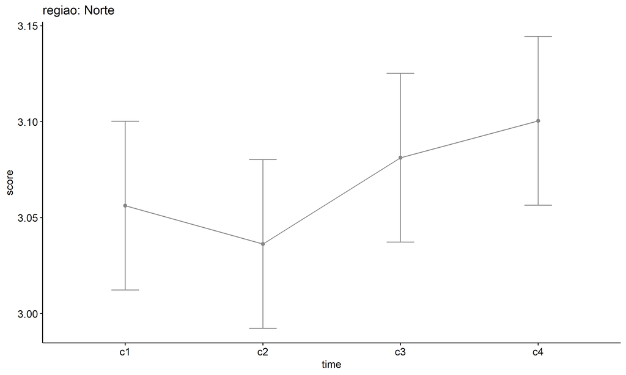

```r
emms.gg <- emms[which(emms$regiao == "Norte"),]
if (nrow(emms.gg) > 0)
  ggline(emms.gg, x = "time", y = "emmean", color = "#868686FF", ylab = "score") +
    geom_errorbar(aes(ymin = conf.low, ymax = conf.high),
                  width = 0.2, color = "#868686FF") +
    stat_pvalue_manual(
      add_xy_position(pwc[which(pwc$regiao == "Norte"),],
                      x = "time", fun = "mean_se"),
      hide.ns = T, color = "#868686FF", tip.length = F) +
    labs(title = "regiao: Norte")+
    theme(legend.text = element_blank())
```

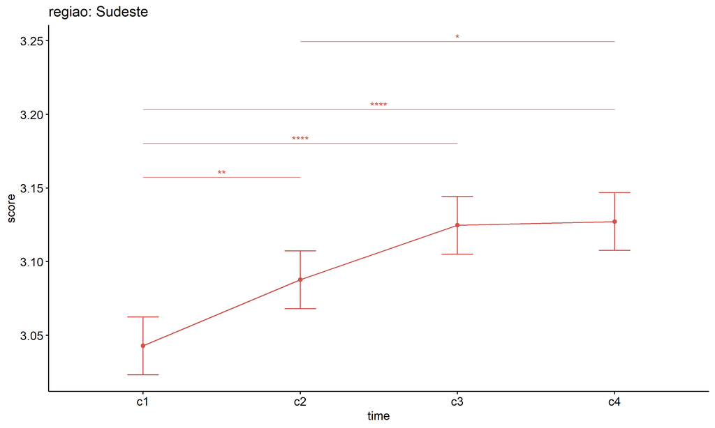

```r
emms.gg <- emms[which(emms$regiao == "Sudeste"),]
if (nrow(emms.gg) > 0)
  ggline(emms.gg, x = "time", y = "emmean", color = "#CD534CFF", ylab = "score") +
    geom_errorbar(aes(ymin = conf.low, ymax = conf.high),
                  width = 0.2, color = "#CD534CFF") +
    stat_pvalue_manual(
      add_xy_position(pwc[which(pwc$regiao == "Sudeste"),],
                      x = "time", fun = "mean_se"),
      hide.ns = T, color = "#CD534CFF", tip.length = F) +
    labs(title = "regiao: Sudeste")+
    theme(legend.text = element_blank())
```

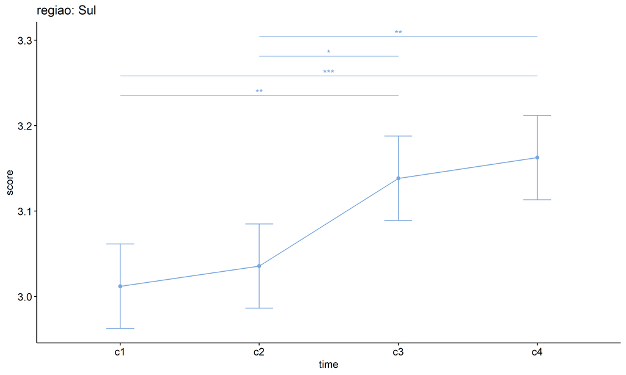

```r
emms.gg <- emms[which(emms$regiao == "Sul"),]
if (nrow(emms.gg) > 0)
  ggline(emms.gg, x = "time", y = "emmean", color = "#7AA6DCFF", ylab = "score") +
    geom_errorbar(aes(ymin = conf.low, ymax = conf.high),
                  width = 0.2, color = "#7AA6DCFF") +
    stat_pvalue_manual(
      add_xy_position(pwc[which(pwc$regiao == "Sul"),],
                      x = "time", fun = "mean_se"),
      hide.ns = T, color = "#7AA6DCFF", tip.length = F) +
    labs(title = "regiao: Sul")+
    theme(legend.text = element_blank())
```

## PairWise Computation after removing non.normal data

```r
if (length(non.ids) > 0)
  (pwc2 <- ldat2 %>% group_by(time) %>%
     emmeans_test(score ~ regiao, detailed = T, p.adjust.method = "bonferroni"))
```

| time | term | .y. | group1 | group2 | null.value | estimate | se | df | conf.low | conf.high | statistic | p | p.adj | p.adj.signif |
| --- | --- | --- | --- | --- | --- | --- | --- | --- | --- | --- | --- | --- | --- | --- |
| c1 | regiao | score | Centro | Oeste | 0 | 0.001 | 0.047 | 4348 | -0.092 | 0.094 | 0.020 | 0.984 | 1.000 | ns |
| c1 | regiao | score | Centro | Oeste | 0 | 0.015 | 0.052 | 4348 | -0.087 | 0.116 | 0.283 | 0.777 | 1.000 | ns |
| c1 | regiao | score | Centro | Oeste | 0 | 0.027 | 0.048 | 4348 | -0.067 | 0.120 | 0.559 | 0.576 | 1.000 | ns |
| c1 | regiao | score | Centro | Oeste | 0 | 0.067 | 0.053 | 4348 | -0.037 | 0.171 | 1.257 | 0.209 | 1.000 | ns |
| c1 | regiao | score | Nordeste | Norte | 0 | 0.014 | 0.024 | 4348 | -0.034 | 0.061 | 0.566 | 0.571 | 1.000 | ns |
| c1 | regiao | score | Nordeste | Sudeste | 0 | 0.026 | 0.013 | 4348 | 0.000 | 0.051 | 1.965 | 0.049 | 0.494 | ns |
| c1 | regiao | score | Nordeste | Sul | 0 | 0.066 | 0.027 | 4348 | 0.013 | 0.118 | 2.448 | 0.014 | 0.144 | ns |
| c1 | regiao | score | Norte | Sudeste | 0 | 0.012 | 0.025 | 4348 | -0.036 | 0.060 | 0.485 | 0.628 | 1.000 | ns |
| c1 | regiao | score | Norte | Sul | 0 | 0.052 | 0.034 | 4348 | -0.015 | 0.119 | 1.527 | 0.127 | 1.000 | ns |
| c1 | regiao | score | Sudeste | Sul | 0 | 0.040 | 0.027 | 4348 | -0.014 | 0.094 | 1.464 | 0.143 | 1.000 | ns |
| c2 | regiao | score | Centro | Oeste | 0 | 0.009 | 0.047 | 4348 | -0.084 | 0.101 | 0.183 | 0.855 | 1.000 | ns |
| c2 | regiao | score | Centro | Oeste | 0 | 0.069 | 0.052 | 4348 | -0.033 | 0.170 | 1.329 | 0.184 | 1.000 | ns |
| c2 | regiao | score | Centro | Oeste | 0 | 0.017 | 0.048 | 4348 | -0.076 | 0.110 | 0.361 | 0.718 | 1.000 | ns |
| c2 | regiao | score | Centro | Oeste | 0 | 0.071 | 0.053 | 4348 | -0.033 | 0.175 | 1.337 | 0.181 | 1.000 | ns |
| c2 | regiao | score | Nordeste | Norte | 0 | 0.060 | 0.024 | 4348 | 0.013 | 0.107 | 2.488 | 0.013 | 0.129 | ns |
| c2 | regiao | score | Nordeste | Sudeste | 0 | 0.009 | 0.013 | 4348 | -0.017 | 0.034 | 0.655 | 0.513 | 1.000 | ns |
| c2 | regiao | score | Nordeste | Sul | 0 | 0.062 | 0.027 | 4348 | 0.010 | 0.115 | 2.320 | 0.020 | 0.204 | ns |
| c2 | regiao | score | Norte | Sudeste | 0 | -0.052 | 0.025 | 4348 | -0.100 | -0.003 | -2.085 | 0.037 | 0.371 | ns |
| c2 | regiao | score | Norte | Sul | 0 | 0.002 | 0.034 | 4348 | -0.065 | 0.069 | 0.063 | 0.950 | 1.000 | ns |
| c2 | regiao | score | Sudeste | Sul | 0 | 0.054 | 0.027 | 4348 | 0.000 | 0.107 | 1.964 | 0.050 | 0.496 | ns |
| c3 | regiao | score | Centro | Oeste | 0 | -0.013 | 0.047 | 4348 | -0.105 | 0.080 | -0.265 | 0.791 | 1.000 | ns |
| c3 | regiao | score | Centro | Oeste | 0 | 0.038 | 0.052 | 4348 | -0.064 | 0.139 | 0.732 | 0.464 | 1.000 | ns |
| c3 | regiao | score | Centro | Oeste | 0 | -0.009 | 0.048 | 4348 | -0.102 | 0.084 | -0.188 | 0.851 | 1.000 | ns |
| c3 | regiao | score | Centro | Oeste | 0 | -0.011 | 0.053 | 4348 | -0.115 | 0.093 | -0.201 | 0.841 | 1.000 | ns |
| c3 | regiao | score | Nordeste | Norte | 0 | 0.050 | 0.024 | 4348 | 0.003 | 0.098 | 2.087 | 0.037 | 0.369 | ns |
| c3 | regiao | score | Nordeste | Sudeste | 0 | 0.004 | 0.013 | 4348 | -0.022 | 0.029 | 0.276 | 0.783 | 1.000 | ns |
| c3 | regiao | score | Nordeste | Sul | 0 | 0.002 | 0.027 | 4348 | -0.051 | 0.055 | 0.071 | 0.944 | 1.000 | ns |
| c3 | regiao | score | Norte | Sudeste | 0 | -0.047 | 0.025 | 4348 | -0.095 | 0.002 | -1.894 | 0.058 | 0.583 | ns |
| c3 | regiao | score | Norte | Sul | 0 | -0.049 | 0.034 | 4348 | -0.115 | 0.018 | -1.424 | 0.154 | 1.000 | ns |
| c3 | regiao | score | Sudeste | Sul | 0 | -0.002 | 0.027 | 4348 | -0.055 | 0.052 | -0.062 | 0.950 | 1.000 | ns |
| c4 | regiao | score | Centro | Oeste | 0 | -0.019 | 0.047 | 4348 | -0.112 | 0.073 | -0.408 | 0.683 | 1.000 | ns |
| c4 | regiao | score | Centro | Oeste | 0 | -0.007 | 0.052 | 4348 | -0.108 | 0.095 | -0.132 | 0.895 | 1.000 | ns |
| c4 | regiao | score | Centro | Oeste | 0 | -0.049 | 0.048 | 4348 | -0.142 | 0.045 | -1.020 | 0.308 | 1.000 | ns |
| c4 | regiao | score | Centro | Oeste | 0 | -0.084 | 0.053 | 4348 | -0.188 | 0.020 | -1.580 | 0.114 | 1.000 | ns |
| c4 | regiao | score | Nordeste | Norte | 0 | 0.012 | 0.024 | 4348 | -0.035 | 0.060 | 0.517 | 0.605 | 1.000 | ns |
| c4 | regiao | score | Nordeste | Sudeste | 0 | -0.029 | 0.013 | 4348 | -0.055 | -0.004 | -2.237 | 0.025 | 0.253 | ns |
| c4 | regiao | score | Nordeste | Sul | 0 | -0.064 | 0.027 | 4348 | -0.117 | -0.012 | -2.402 | 0.016 | 0.163 | ns |
| c4 | regiao | score | Norte | Sudeste | 0 | -0.042 | 0.025 | 4348 | -0.090 | 0.007 | -1.686 | 0.092 | 0.918 | ns |
| c4 | regiao | score | Norte | Sul | 0 | -0.077 | 0.034 | 4348 | -0.144 | -0.010 | -2.258 | 0.024 | 0.240 | ns |
| c4 | regiao | score | Sudeste | Sul | 0 | -0.035 | 0.027 | 4348 | -0.089 | 0.018 | -1.289 | 0.197 | 1.000 | ns |

```r
if (length(non.ids) > 0)
  (emms2 <- get_emmeans(pwc2))
```

```
## # A tibble: 20 × 8
##    time  regiao       emmean      se    df conf.low conf.high method
##    <fct> <fct>         <dbl>   <dbl> <dbl>    <dbl>     <dbl> <chr>
##  1 c1    Centro-Oeste   3.07 0.0465   4348     2.98      3.16 Emmeans test
##  2 c1    Nordeste       3.07 0.00845  4348     3.05      3.09 Emmeans test
##  3 c1    Norte          3.05 0.0226   4348     3.01      3.10 Emmeans test
##  4 c1    Sudeste        3.04 0.00996  4348     3.02      3.06 Emmeans test
##  5 c1    Sul            3.00 0.0255   4348     2.95      3.05 Emmeans test
##  6 c2    Centro-Oeste   3.10 0.0465   4348     3.01      3.20 Emmeans test
##  7 c2    Nordeste       3.10 0.00845  4348     3.08      3.11 Emmeans test
##  8 c2    Norte          3.04 0.0226   4348     2.99      3.08 Emmeans test
##  9 c2    Sudeste        3.09 0.00996  4348     3.07      3.11 Emmeans test
## 10 c2    Sul            3.03 0.0255   4348     2.98      3.08 Emmeans test
## 11 c3    Centro-Oeste   3.12 0.0465   4348     3.02      3.21 Emmeans test
## 12 c3    Nordeste       3.13 0.00845  4348     3.11      3.14 Emmeans test
## 13 c3    Norte          3.08 0.0226   4348     3.03      3.12 Emmeans test
## 14 c3    Sudeste        3.12 0.00996  4348     3.11      3.14 Emmeans test
## 15 c3    Sul            3.13 0.0255   4348     3.08      3.18 Emmeans test
## 16 c4    Centro-Oeste   3.08 0.0465   4348     2.99      3.17 Emmeans test
## 17 c4    Nordeste       3.10 0.00845  4348     3.08      3.11 Emmeans test
## 18 c4    Norte          3.09 0.0226   4348     3.04      3.13 Emmeans test
## 19 c4    Sudeste        3.13 0.00996  4348     3.11      3.15 Emmeans test
## 20 c4    Sul            3.16 0.0255   4348     3.11      3.21 Emmeans test
```

| time | regiao | emmean | se | df | conf.low | conf.high | method |
| --- | --- | --- | --- | --- | --- | --- | --- |
| c1 | Centro-Oeste | 3.069 | 0.047 | 4348 | 2.978 | 3.161 | Emmeans test |
| c1 | Nordeste | 3.069 | 0.008 | 4348 | 3.052 | 3.085 | Emmeans test |
| c1 | Norte | 3.055 | 0.023 | 4348 | 3.010 | 3.099 | Emmeans test |
| c1 | Sudeste | 3.043 | 0.010 | 4348 | 3.023 | 3.062 | Emmeans test |
| c1 | Sul | 3.003 | 0.025 | 4348 | 2.953 | 3.053 | Emmeans test |
| c2 | Centro-Oeste | 3.105 | 0.047 | 4348 | 3.014 | 3.196 | Emmeans test |
| c2 | Nordeste | 3.096 | 0.008 | 4348 | 3.080 | 3.113 | Emmeans test |
| c2 | Norte | 3.036 | 0.023 | 4348 | 2.992 | 3.081 | Emmeans test |
| c2 | Sudeste | 3.088 | 0.010 | 4348 | 3.068 | 3.107 | Emmeans test |
| c2 | Sul | 3.034 | 0.025 | 4348 | 2.984 | 3.084 | Emmeans test |
| c3 | Centro-Oeste | 3.116 | 0.047 | 4348 | 3.025 | 3.207 | Emmeans test |
| c3 | Nordeste | 3.128 | 0.008 | 4348 | 3.112 | 3.145 | Emmeans test |
| c3 | Norte | 3.078 | 0.023 | 4348 | 3.033 | 3.122 | Emmeans test |
| c3 | Sudeste | 3.125 | 0.010 | 4348 | 3.105 | 3.144 | Emmeans test |
| c3 | Sul | 3.126 | 0.025 | 4348 | 3.076 | 3.176 | Emmeans test |
| c4 | Centro-Oeste | 3.079 | 0.047 | 4348 | 2.988 | 3.170 | Emmeans test |
| c4 | Nordeste | 3.098 | 0.008 | 4348 | 3.081 | 3.115 | Emmeans test |
| c4 | Norte | 3.086 | 0.023 | 4348 | 3.041 | 3.130 | Emmeans test |
| c4 | Sudeste | 3.127 | 0.010 | 4348 | 3.108 | 3.147 | Emmeans test |
| c4 | Sul | 3.163 | 0.025 | 4348 | 3.113 | 3.212 | Emmeans test |

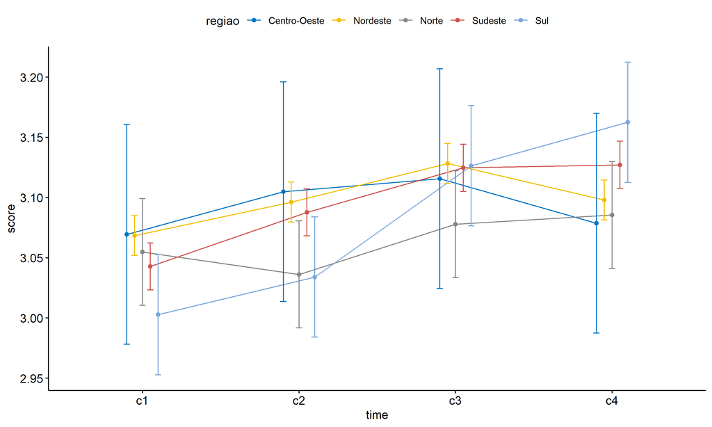

```r
if (length(non.ids) > 0) {
  pwc2 <- add_xy_position(pwc2, x = "time", fun = "mean_se", dodge = 0.25)
  pd2 <- position_dodge(width = 0.25)

  ggline(emms2, x = "time", y = "emmean", color = "regiao",
         palette = c("#0073C2FF","#EFC000FF","#868686FF","#CD534CFF","#7AA6DCFF"),
         position = pd, ylab = "score") +
    geom_errorbar(aes(ymin = conf.low, ymax = conf.high, color = regiao),
                position = pd, width = 0.2) +
    stat_pvalue_manual(pwc2, hide.ns = T, tip.length = F, linetype = 1)
}
```

```r
if (length(non.ids) > 0)
  (pwc2 <- ldat2 %>% group_by(regiao) %>%
     emmeans_test(score ~ time, detailed = T, p.adjust.method = "bonferroni"))
```

```
## # A tibble: 30 × 15
##    regiao term  .y.   group1 group2 null.value estimate     se    df conf.low conf.high statistic
##  * <fct>  <chr> <chr> <chr>  <chr>       <dbl>    <dbl>  <dbl> <dbl>    <dbl>     <dbl>     <dbl>
##  1 Centr… time  score c1     c2              0 -0.0355  0.0658  4348  -0.164    0.0935     -0.540
##  2 Centr… time  score c1     c3              0 -0.0463  0.0658  4348  -0.175    0.0827     -0.704
##  3 Centr… time  score c1     c4              0 -0.00926 0.0658  4348  -0.138    0.120      -0.141
##  4 Centr… time  score c2     c3              0 -0.0108  0.0658  4348  -0.140    0.118      -0.164
##  5 Centr… time  score c2     c4              0  0.0262  0.0658  4348  -0.103    0.155       0.399
##  6 Centr… time  score c3     c4              0  0.0370  0.0658  4348  -0.0919   0.166       0.563
##  7 Norde… time  score c1     c2              0 -0.0278  0.0120  4348  -0.0512  -0.00436    -2.33
##  8 Norde… time  score c1     c3              0 -0.0598  0.0120  4348  -0.0832  -0.0363     -5.00
##  9 Norde… time  score c1     c4              0 -0.0295  0.0120  4348  -0.0529  -0.00607    -2.47
## 10 Norde… time  score c2     c3              0 -0.0320  0.0120  4348  -0.0554  -0.00854    -2.68
## # ℹ 20 more rows
## # ℹ 3 more variables: p <dbl>, p.adj <dbl>, p.adj.signif <chr>
```

| regiao | term | .y. | group1 | group2 | null.value | estimate | se | df | conf.low | conf.high | statistic | p | p.adj | p.adj.signif |
| --- | --- | --- | --- | --- | --- | --- | --- | --- | --- | --- | --- | --- | --- | --- |
| Centro-Oeste | time | score | c1 | c2 | 0 | -0.035 | 0.066 | 4348 | -0.164 | 0.093 | -0.540 | 0.590 | 1.000 | ns |
| Centro-Oeste | time | score | c1 | c3 | 0 | -0.046 | 0.066 | 4348 | -0.175 | 0.083 | -0.704 | 0.482 | 1.000 | ns |
| Centro-Oeste | time | score | c1 | c4 | 0 | -0.009 | 0.066 | 4348 | -0.138 | 0.120 | -0.141 | 0.888 | 1.000 | ns |
| Centro-Oeste | time | score | c2 | c3 | 0 | -0.011 | 0.066 | 4348 | -0.140 | 0.118 | -0.164 | 0.870 | 1.000 | ns |
| Centro-Oeste | time | score | c2 | c4 | 0 | 0.026 | 0.066 | 4348 | -0.103 | 0.155 | 0.399 | 0.690 | 1.000 | ns |
| Centro-Oeste | time | score | c3 | c4 | 0 | 0.037 | 0.066 | 4348 | -0.092 | 0.166 | 0.563 | 0.573 | 1.000 | ns |
| Nordeste | time | score | c1 | c2 | 0 | -0.028 | 0.012 | 4348 | -0.051 | -0.004 | -2.326 | 0.020 | 0.121 | ns |
| Nordeste | time | score | c1 | c3 | 0 | -0.060 | 0.012 | 4348 | -0.083 | -0.036 | -5.001 | 0.000 | 0.000 | **** |
| Nordeste | time | score | c1 | c4 | 0 | -0.030 | 0.012 | 4348 | -0.053 | -0.006 | -2.468 | 0.014 | 0.082 | ns |
| Nordeste | time | score | c2 | c3 | 0 | -0.032 | 0.012 | 4348 | -0.055 | -0.009 | -2.675 | 0.007 | 0.045 | * |
| Nordeste | time | score | c2 | c4 | 0 | -0.002 | 0.012 | 4348 | -0.025 | 0.022 | -0.143 | 0.886 | 1.000 | ns |
| Nordeste | time | score | c3 | c4 | 0 | 0.030 | 0.012 | 4348 | 0.007 | 0.054 | 2.532 | 0.011 | 0.068 | ns |
| Norte | time | score | c1 | c2 | 0 | 0.019 | 0.032 | 4348 | -0.044 | 0.081 | 0.582 | 0.560 | 1.000 | ns |
| Norte | time | score | c1 | c3 | 0 | -0.023 | 0.032 | 4348 | -0.086 | 0.040 | -0.719 | 0.472 | 1.000 | ns |
| Norte | time | score | c1 | c4 | 0 | -0.031 | 0.032 | 4348 | -0.093 | 0.032 | -0.959 | 0.338 | 1.000 | ns |
| Norte | time | score | c2 | c3 | 0 | -0.042 | 0.032 | 4348 | -0.104 | 0.021 | -1.301 | 0.193 | 1.000 | ns |
| Norte | time | score | c2 | c4 | 0 | -0.049 | 0.032 | 4348 | -0.112 | 0.013 | -1.541 | 0.123 | 0.740 | ns |
| Norte | time | score | c3 | c4 | 0 | -0.008 | 0.032 | 4348 | -0.070 | 0.055 | -0.240 | 0.811 | 1.000 | ns |
| Sudeste | time | score | c1 | c2 | 0 | -0.045 | 0.014 | 4348 | -0.073 | -0.017 | -3.190 | 0.001 | 0.009 | ** |
| Sudeste | time | score | c1 | c3 | 0 | -0.082 | 0.014 | 4348 | -0.109 | -0.054 | -5.814 | 0.000 | 0.000 | **** |
| Sudeste | time | score | c1 | c4 | 0 | -0.084 | 0.014 | 4348 | -0.112 | -0.057 | -5.994 | 0.000 | 0.000 | **** |
| Sudeste | time | score | c2 | c3 | 0 | -0.037 | 0.014 | 4348 | -0.065 | -0.009 | -2.623 | 0.009 | 0.052 | ns |
| Sudeste | time | score | c2 | c4 | 0 | -0.039 | 0.014 | 4348 | -0.067 | -0.012 | -2.804 | 0.005 | 0.030 | * |
| Sudeste | time | score | c3 | c4 | 0 | -0.003 | 0.014 | 4348 | -0.030 | 0.025 | -0.181 | 0.857 | 1.000 | ns |
| Sul | time | score | c1 | c2 | 0 | -0.031 | 0.036 | 4348 | -0.102 | 0.039 | -0.867 | 0.386 | 1.000 | ns |
| Sul | time | score | c1 | c3 | 0 | -0.124 | 0.036 | 4348 | -0.194 | -0.053 | -3.431 | 0.001 | 0.004 | ** |
| Sul | time | score | c1 | c4 | 0 | -0.160 | 0.036 | 4348 | -0.230 | -0.089 | -4.433 | 0.000 | 0.000 | **** |
| Sul | time | score | c2 | c3 | 0 | -0.092 | 0.036 | 4348 | -0.163 | -0.022 | -2.563 | 0.010 | 0.062 | ns |
| Sul | time | score | c2 | c4 | 0 | -0.128 | 0.036 | 4348 | -0.199 | -0.058 | -3.565 | 0.000 | 0.002 | ** |
| Sul | time | score | c3 | c4 | 0 | -0.036 | 0.036 | 4348 | -0.107 | 0.035 | -1.002 | 0.316 | 1.000 | ns |

```r
if (length(non.ids) > 0)
  (emms2 <- get_emmeans(pwc2))
```

```
## # A tibble: 20 × 8
##    regiao       time  emmean      se    df conf.low conf.high method
##    <fct>        <fct>  <dbl>   <dbl> <dbl>    <dbl>     <dbl> <chr>
##  1 Centro-Oeste c1      3.07 0.0465   4348     2.98      3.16 Emmeans test
##  2 Centro-Oeste c2      3.10 0.0465   4348     3.01      3.20 Emmeans test
##  3 Centro-Oeste c3      3.12 0.0465   4348     3.02      3.21 Emmeans test
##  4 Centro-Oeste c4      3.08 0.0465   4348     2.99      3.17 Emmeans test
##  5 Nordeste     c1      3.07 0.00845  4348     3.05      3.09 Emmeans test
##  6 Nordeste     c2      3.10 0.00845  4348     3.08      3.11 Emmeans test
##  7 Nordeste     c3      3.13 0.00845  4348     3.11      3.14 Emmeans test
##  8 Nordeste     c4      3.10 0.00845  4348     3.08      3.11 Emmeans test
##  9 Norte        c1      3.05 0.0226   4348     3.01      3.10 Emmeans test
## 10 Norte        c2      3.04 0.0226   4348     2.99      3.08 Emmeans test
## 11 Norte        c3      3.08 0.0226   4348     3.03      3.12 Emmeans test
## 12 Norte        c4      3.09 0.0226   4348     3.04      3.13 Emmeans test
## 13 Sudeste      c1      3.04 0.00996  4348     3.02      3.06 Emmeans test
## 14 Sudeste      c2      3.09 0.00996  4348     3.07      3.11 Emmeans test
## 15 Sudeste      c3      3.12 0.00996  4348     3.11      3.14 Emmeans test
## 16 Sudeste      c4      3.13 0.00996  4348     3.11      3.15 Emmeans test
## 17 Sul          c1      3.00 0.0255   4348     2.95      3.05 Emmeans test
## 18 Sul          c2      3.03 0.0255   4348     2.98      3.08 Emmeans test
## 19 Sul          c3      3.13 0.0255   4348     3.08      3.18 Emmeans test
## 20 Sul          c4      3.16 0.0255   4348     3.11      3.21 Emmeans test
```

| regiao | time | emmean | se | df | conf.low | conf.high | method |
| --- | --- | --- | --- | --- | --- | --- | --- |
| Centro-Oeste | c1 | 3.069 | 0.047 | 4348 | 2.978 | 3.161 | Emmeans test |
| Centro-Oeste | c2 | 3.105 | 0.047 | 4348 | 3.014 | 3.196 | Emmeans test |
| Centro-Oeste | c3 | 3.116 | 0.047 | 4348 | 3.025 | 3.207 | Emmeans test |
| Centro-Oeste | c4 | 3.079 | 0.047 | 4348 | 2.988 | 3.170 | Emmeans test |
| Nordeste | c1 | 3.069 | 0.008 | 4348 | 3.052 | 3.085 | Emmeans test |
| Nordeste | c2 | 3.096 | 0.008 | 4348 | 3.080 | 3.113 | Emmeans test |
| Nordeste | c3 | 3.128 | 0.008 | 4348 | 3.112 | 3.145 | Emmeans test |
| Nordeste | c4 | 3.098 | 0.008 | 4348 | 3.081 | 3.115 | Emmeans test |
| Norte | c1 | 3.055 | 0.023 | 4348 | 3.010 | 3.099 | Emmeans test |
| Norte | c2 | 3.036 | 0.023 | 4348 | 2.992 | 3.081 | Emmeans test |
| Norte | c3 | 3.078 | 0.023 | 4348 | 3.033 | 3.122 | Emmeans test |
| Norte | c4 | 3.086 | 0.023 | 4348 | 3.041 | 3.130 | Emmeans test |
| Sudeste | c1 | 3.043 | 0.010 | 4348 | 3.023 | 3.062 | Emmeans test |
| Sudeste | c2 | 3.088 | 0.010 | 4348 | 3.068 | 3.107 | Emmeans test |
| Sudeste | c3 | 3.125 | 0.010 | 4348 | 3.105 | 3.144 | Emmeans test |
| Sudeste | c4 | 3.127 | 0.010 | 4348 | 3.108 | 3.147 | Emmeans test |
| Sul | c1 | 3.003 | 0.025 | 4348 | 2.953 | 3.053 | Emmeans test |
| Sul | c2 | 3.034 | 0.025 | 4348 | 2.984 | 3.084 | Emmeans test |
| Sul | c3 | 3.126 | 0.025 | 4348 | 3.076 | 3.176 | Emmeans test |
| Sul | c4 | 3.163 | 0.025 | 4348 | 3.113 | 3.212 | Emmeans test |

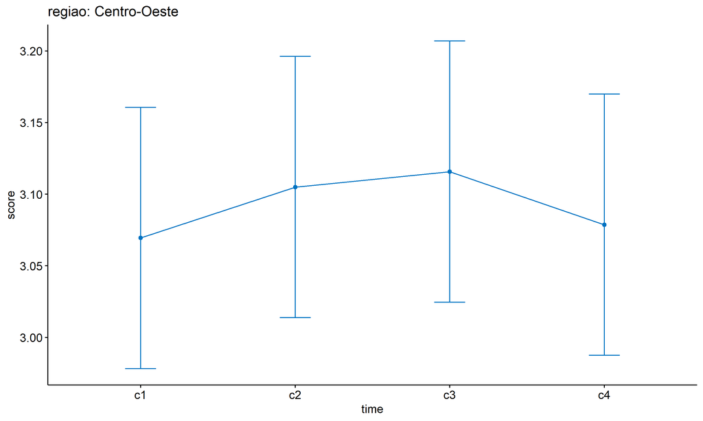

```r
if (length(non.ids) > 0) {
  emms.gg <- emms2[which(emms2$regiao == "Centro-Oeste"),]
  if (nrow(emms.gg) > 0)
    ggline(emms.gg, x = "time", y = "emmean", color = "#0073C2FF", ylab = "score") +
    geom_errorbar(aes(ymin = conf.low, ymax = conf.high),
                  width = 0.2, color = "#0073C2FF") +
    stat_pvalue_manual(
      add_xy_position(pwc[which(pwc$regiao == "Centro-Oeste"),],
                      x = "time", fun = "mean_se"),
      hide.ns = T, color = "#0073C2FF", tip.length = F) +
    labs(title = "regiao: Centro-Oeste") +
    theme(legend.text = element_blank())
}
```

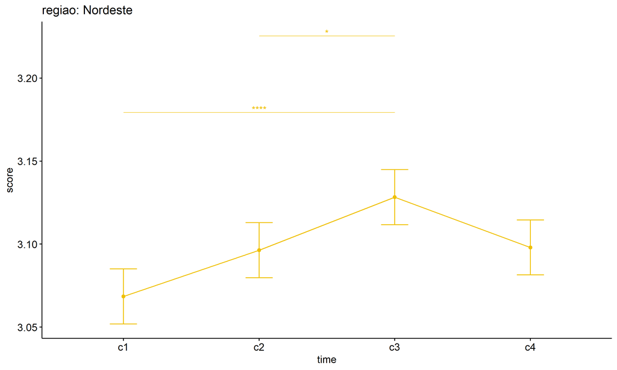

```r
if (length(non.ids) > 0) {
  emms.gg <- emms2[which(emms2$regiao == "Nordeste"),]
  if (nrow(emms.gg) > 0)
    ggline(emms.gg, x = "time", y = "emmean", color = "#EFC000FF", ylab = "score") +
    geom_errorbar(aes(ymin = conf.low, ymax = conf.high),
                  width = 0.2, color = "#EFC000FF") +
    stat_pvalue_manual(
      add_xy_position(pwc[which(pwc$regiao == "Nordeste"),],
                      x = "time", fun = "mean_se"),
      hide.ns = T, color = "#EFC000FF", tip.length = F) +
    labs(title = "regiao: Nordeste") +
    theme(legend.text = element_blank())
}
```

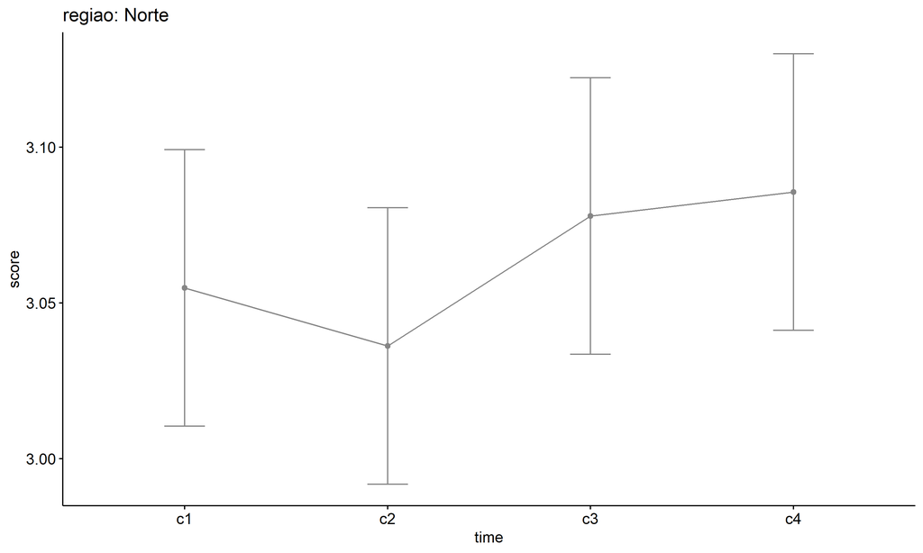

```r
if (length(non.ids) > 0) {
  emms.gg <- emms2[which(emms2$regiao == "Norte"),]
  if (nrow(emms.gg) > 0)
    ggline(emms.gg, x = "time", y = "emmean", color = "#868686FF", ylab = "score") +
    geom_errorbar(aes(ymin = conf.low, ymax = conf.high),
                  width = 0.2, color = "#868686FF") +
    stat_pvalue_manual(
      add_xy_position(pwc[which(pwc$regiao == "Norte"),],
                      x = "time", fun = "mean_se"),
      hide.ns = T, color = "#868686FF", tip.length = F) +
    labs(title = "regiao: Norte") +
    theme(legend.text = element_blank())
}
```

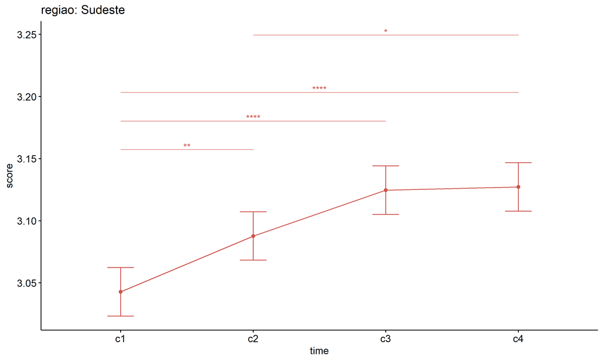

```r
if (length(non.ids) > 0) {
  emms.gg <- emms2[which(emms2$regiao == "Sudeste"),]
  if (nrow(emms.gg) > 0)
    ggline(emms.gg, x = "time", y = "emmean", color = "#CD534CFF", ylab = "score") +
    geom_errorbar(aes(ymin = conf.low, ymax = conf.high),
                  width = 0.2, color = "#CD534CFF") +
    stat_pvalue_manual(
      add_xy_position(pwc[which(pwc$regiao == "Sudeste"),],
                      x = "time", fun = "mean_se"),
      hide.ns = T, color = "#CD534CFF", tip.length = F) +
    labs(title = "regiao: Sudeste") +
    theme(legend.text = element_blank())
}
```

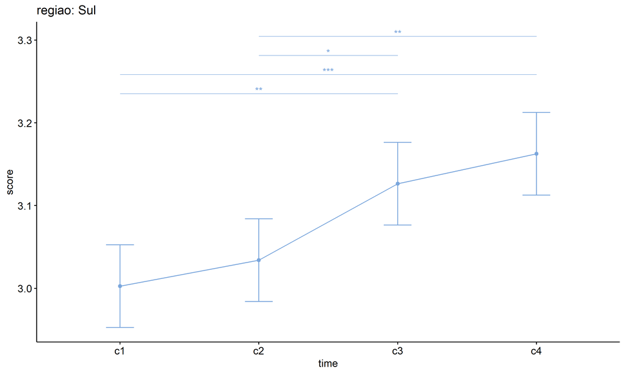

```r
if (length(non.ids) > 0) {
  emms.gg <- emms2[which(emms2$regiao == "Sul"),]
  if (nrow(emms.gg) > 0)
    ggline(emms.gg, x = "time", y = "emmean", color = "#7AA6DCFF", ylab = "score") +
    geom_errorbar(aes(ymin = conf.low, ymax = conf.high),
                  width = 0.2, color = "#7AA6DCFF") +
    stat_pvalue_manual(
      add_xy_position(pwc[which(pwc$regiao == "Sul"),],
                      x = "time", fun = "mean_se"),
      hide.ns = T, color = "#7AA6DCFF", tip.length = F) +
    labs(title = "regiao: Sul") +
    theme(legend.text = element_blank())
}
```

# ANOVA: score ~ time*porte + Error(id/time)

## Data Preparation

```r
data <- edat[,c("aluno_id","porte","ciclo","score")]
data$ciclo <- factor(data$ciclo, c("Primeiro Ciclo","Segundo Ciclo",
                                   "Terceiro Ciclo","Quarto Ciclo"))

wdat <- spread(data, ciclo, score)
wdat <- wdat[complete.cases(wdat),]
colnames(wdat) <- c("id","porte","c1","c2","c3","c4")

ldat <- gather(wdat, key = time, value = score, c1, c2, c3, c4) %>%
  convert_as_factor(id, time)
ldat <- remove_group_data(ldat, "score", c("time", "porte"), n.limit = 30)
ldat$porte <- factor(ldat$porte, sort(unique(ldat$porte)))
```

### Check assumptions: Identifying Outliers

```r
outliers <- identify_outliers(group_by(ldat, time, porte), score)
(outliers <- outliers[outliers$is.extreme == T,])
```

```
## # A tibble: 18 × 6
##    porte                                        time  id              score is.outlier is.extreme
##    <fct>                                        <fct> <fct>           <dbl> <lgl>      <lgl>
##  1 Até 50 matrículas de escolarização           c1    0w3VhiMf67Cbcp…  3.83 TRUE       TRUE
##  2 Entre 201 e 500 matrículas de escolarização  c1    Ru3SPRo97iXBvX…  3.83 TRUE       TRUE
##  3 Entre 201 e 500 matrículas de escolarização  c1    uCBI6gnllsawWJ…  3.83 TRUE       TRUE
##  4 Entre 201 e 500 matrículas de escolarização  c1    vc8pPoYau2AIAu…  3.83 TRUE       TRUE
##  5 Entre 501 e 1000 matrículas de escolarização c1    D1HfJKTVqjrpCJ…  3.75 TRUE       TRUE
##  6 Entre 201 e 500 matrículas de escolarização  c2    cuknOzzwN4oCRu…  4    TRUE       TRUE
##  7 Entre 201 e 500 matrículas de escolarização  c2    HsQF2J0r79mHSW…  3.83 TRUE       TRUE
##  8 Entre 201 e 500 matrículas de escolarização  c2    j31LU8Xwm0EQ7M…  3.83 TRUE       TRUE
##  9 Entre 201 e 500 matrículas de escolarização  c2    oGUJyWRMYYbF9P…  3.83 TRUE       TRUE
## 10 Entre 201 e 500 matrículas de escolarização  c2    z3p6Ot4uvkPmGX…  3.83 TRUE       TRUE
## 11 Entre 201 e 500 matrículas de escolarização  c3    CCVIt7MPeYMUOC…  4    TRUE       TRUE
## 12 Entre 201 e 500 matrículas de escolarização  c3    i5EZ8Ck9IgDuey…  4    TRUE       TRUE
## 13 Entre 201 e 500 matrículas de escolarização  c3    m5yRlxfIj73j4o…  4    TRUE       TRUE
## 14 Entre 201 e 500 matrículas de escolarização  c3    OvwAQTWkdj8SYp…  3.83 TRUE       TRUE
## 15 Entre 201 e 500 matrículas de escolarização  c3    RkRJsrzuZjQPcg…  3.83 TRUE       TRUE
## 16 Entre 201 e 500 matrículas de escolarização  c4    1OE4fvPj9Y2Q9B…  3.83 TRUE       TRUE
## 17 Entre 201 e 500 matrículas de escolarização  c4    kFvRH3RtPD461q…  3.83 TRUE       TRUE
## 18 Entre 51 e 200 matrículas de escolarização   c4    fgNBRPWfCa0TP4…  3.83 TRUE       TRUE
```

| porte | time | id | score | is.outlier | is.extreme |
| --- | --- | --- | --- | --- | --- |
| Até 50 matrículas de escolarização | c1 | 0w3VhiMf67CbcpR6aZCL | 3.833 | TRUE | TRUE |
| Entre 201 e 500 matrículas de escolarização | c1 | Ru3SPRo97iXBvXbvneKh | 3.833 | TRUE | TRUE |
| Entre 201 e 500 matrículas de escolarização | c1 | uCBI6gnllsawWJlgqkr5 | 3.833 | TRUE | TRUE |
| Entre 201 e 500 matrículas de escolarização | c1 | vc8pPoYau2AIAuCQJipW | 3.833 | TRUE | TRUE |
| Entre 501 e 1000 matrículas de escolarização | c1 | D1HfJKTVqjrpCJx97l3v | 3.750 | TRUE | TRUE |
| Entre 201 e 500 matrículas de escolarização | c2 | cuknOzzwN4oCRum5U5ph | 4.000 | TRUE | TRUE |
| Entre 201 e 500 matrículas de escolarização | c2 | HsQF2J0r79mHSWNe4l6n | 3.833 | TRUE | TRUE |
| Entre 201 e 500 matrículas de escolarização | c2 | j31LU8Xwm0EQ7Mihkhjj | 3.833 | TRUE | TRUE |
| Entre 201 e 500 matrículas de escolarização | c2 | oGUJyWRMYYbF9PNegJZh | 3.833 | TRUE | TRUE |
| Entre 201 e 500 matrículas de escolarização | c2 | z3p6Ot4uvkPmGXOS9D3e | 3.833 | TRUE | TRUE |
| Entre 201 e 500 matrículas de escolarização | c3 | CCVIt7MPeYMUOCCyBxPh | 4.000 | TRUE | TRUE |
| Entre 201 e 500 matrículas de escolarização | c3 | i5EZ8Ck9IgDueyMbw55v | 4.000 | TRUE | TRUE |
| Entre 201 e 500 matrículas de escolarização | c3 | m5yRlxfIj73j4ossfTOB | 4.000 | TRUE | TRUE |
| Entre 201 e 500 matrículas de escolarização | c3 | OvwAQTWkdj8SYpPS8dgn | 3.833 | TRUE | TRUE |
| Entre 201 e 500 matrículas de escolarização | c3 | RkRJsrzuZjQPcgr9Bu7D | 3.833 | TRUE | TRUE |
| Entre 201 e 500 matrículas de escolarização | c4 | 1OE4fvPj9Y2Q9Bnwr0xz | 3.833 | TRUE | TRUE |
| Entre 201 e 500 matrículas de escolarização | c4 | kFvRH3RtPD461qVG04iW | 3.833 | TRUE | TRUE |
| Entre 51 e 200 matrículas de escolarização | c4 | fgNBRPWfCa0TP4bDO8d2 | 3.833 | TRUE | TRUE |

### Check assumptions: Normality Test

```r
(normality.df <- normality.test.per.groups(ldat, "score", c("time", "porte")))
```

```
##      var variable time                                        porte   n  skewness   kurtosis
## 1  score    score   c1           Até 50 matrículas de escolarização  33 1.5877386  5.8183189
## 2  score    score   c1  Entre 201 e 500 matrículas de escolarização 675 0.8669586  2.2374109
## 3  score    score   c1 Entre 501 e 1000 matrículas de escolarização 249 1.1732479  3.7329947
## 4  score    score   c1   Entre 51 e 200 matrículas de escolarização 162 0.6515187  1.2539110
## 5  score    score   c2           Até 50 matrículas de escolarização  33 0.5251623 -0.6208665
## 6  score    score   c2  Entre 201 e 500 matrículas de escolarização 675 0.9220391  2.0402341
## 7  score    score   c2 Entre 501 e 1000 matrículas de escolarização 249 0.9441657  1.1956636
## 8  score    score   c2   Entre 51 e 200 matrículas de escolarização 162 0.3811939  1.0379864
## 9  score    score   c3           Até 50 matrículas de escolarização  33 0.8677136  0.2563912
## 10 score    score   c3  Entre 201 e 500 matrículas de escolarização 675 0.9779737  1.2973995
## 11 score    score   c3 Entre 501 e 1000 matrículas de escolarização 249 0.7746906  0.0280816
## 12 score    score   c3   Entre 51 e 200 matrículas de escolarização 162 1.1169901  0.9889998
## 13 score    score   c4           Até 50 matrículas de escolarização  33 0.9846119 -0.0181759
## 14 score    score   c4  Entre 201 e 500 matrículas de escolarização 675 0.8822207  0.9355434
```

[output cut: 19 more lines]

| var | variable | time | porte | n | skewness | kurtosis | symmetry | statistic | method | p | p.signif | normality |
| --- | --- | --- | --- | --- | --- | --- | --- | --- | --- | --- | --- | --- |
| score | score | c1 | Até 50 matrículas de escolarização | 33 | 1.588 | 5.818 | NO | 0.820 | Shapiro-Wilk | 0.000 | **** | NO |
| score | score | c1 | Entre 201 e 500 matrículas de escolarização | 675 | 0.867 | 2.237 | NO | 105.669 | D’Agostino | 0.000 | **** | - |
| score | score | c1 | Entre 501 e 1000 matrículas de escolarização | 249 | 1.173 | 3.733 | NO | 68.671 | D’Agostino | 0.000 | **** | - |
| score | score | c1 | Entre 51 e 200 matrículas de escolarização | 162 | 0.652 | 1.254 | NO | 17.546 | D’Agostino | 0.000 | ** | QQ |
| score | score | c2 | Até 50 matrículas de escolarização | 33 | 0.525 | -0.621 | NO | 0.915 | Shapiro-Wilk | 0.013 | * | NO |
| score | score | c2 | Entre 201 e 500 matrículas de escolarização | 675 | 0.922 | 2.040 | NO | 108.643 | D’Agostino | 0.000 | **** | - |
| score | score | c2 | Entre 501 e 1000 matrículas de escolarização | 249 | 0.944 | 1.196 | NO | 37.868 | D’Agostino | 0.000 | **** | - |
| score | score | c2 | Entre 51 e 200 matrículas de escolarização | 162 | 0.381 | 1.038 | YES | 9.462 | D’Agostino | 0.009 | * | QQ |
| score | score | c3 | Até 50 matrículas de escolarização | 33 | 0.868 | 0.256 | NO | 0.895 | Shapiro-Wilk | 0.004 | ** | NO |
| score | score | c3 | Entre 201 e 500 matrículas de escolarização | 675 | 0.978 | 1.297 | NO | 100.787 | D’Agostino | 0.000 | **** | - |
| score | score | c3 | Entre 501 e 1000 matrículas de escolarização | 249 | 0.775 | 0.028 | NO | 21.564 | D’Agostino | 0.000 | *** | - |
| score | score | c3 | Entre 51 e 200 matrículas de escolarização | 162 | 1.117 | 0.989 | NO | 30.793 | D’Agostino | 0.000 | **** | QQ |
| score | score | c4 | Até 50 matrículas de escolarização | 33 | 0.985 | -0.018 | NO | 0.833 | Shapiro-Wilk | 0.000 | *** | NO |
| score | score | c4 | Entre 201 e 500 matrículas de escolarização | 675 | 0.882 | 0.936 | NO | 81.714 | D’Agostino | 0.000 | **** | - |
| score | score | c4 | Entre 501 e 1000 matrículas de escolarização | 249 | 0.698 | 0.316 | NO | 19.468 | D’Agostino | 0.000 | *** | - |
| score | score | c4 | Entre 51 e 200 matrículas de escolarização | 162 | 0.852 | 0.814 | NO | 20.921 | D’Agostino | 0.000 | *** | QQ |

```r
(non.ids <- unique(do.call(
  c, lapply(which(normality.df$normality == 'NO'), FUN = function(i) {
  idx = which(ldat$time == normality.df$time[i] &
                ldat$porte == normality.df$porte[i])
  getNonNormal(ldat$"score"[idx], ldat$id[idx])
}))))
```

```
##  [1] "0w3VhiMf67CbcpR6aZCL" "ADdqL4oAf1WRDDiOJwkj" "VNQYsv3kH0OTOqJH3yYT" "xD1wHpF1gkJCyVbkGGdU"
##  [5] "xAo0TzCEx1bIrmjqKgbj" "1ZE6i0Is22PBIAZbrM0J" "vgyELVyPKZx09yEhXnEW" "L0gX2yfP95da5eDy6w4E"
##  [9] "4fSdH8m80yxwok1ooZYh" "w7548cNc0knlzDezHzBq" "U2EyQT1K48KPitv2x16k" "8QJX5P6FygYXzjqA5njF"
## [13] "iutpBZMAtM92qcbyCDHB" "i84ihNmDZFogrHoxo3Im" "z2bvFgOm1tRPAL3buvNQ" "ygCWEOBsngyfEt5hGLmw"
## [17] "Lbwu9s0newf9Wi294FdL" "d7fkDImOtMuiednMD3E1" "7gsjMtGuUxQPUSVFnNcm" "UgYoK4SY4Mtbi2xic7Rv"
## [21] "MdfO8FPiIZis82vN8Qvn" "ltYX0dLBB2brT2djXB5i" "KBTZEriJAFvcWw48Xxgc" "jljcKPNPjBo1MdiK1ffQ"
```

```r
if (length(non.ids) > 0)
  ldat2 <- ldat[!ldat$id %in% non.ids,]
```

### Summary Statistics

```r
(sdat <- ldat %>% group_by(time, porte) %>%
   get_summary_stats(score, type = "mean_sd"))
```

```
## # A tibble: 16 × 6
##    porte                                        time  variable     n  mean    sd
##    <fct>                                        <fct> <fct>    <dbl> <dbl> <dbl>
##  1 Até 50 matrículas de escolarização           c1    score       33  3.08 0.189
##  2 Entre 201 e 500 matrículas de escolarização  c1    score      675  3.06 0.175
##  3 Entre 501 e 1000 matrículas de escolarização c1    score      249  3.06 0.144
##  4 Entre 51 e 200 matrículas de escolarização   c1    score      162  3.04 0.209
##  5 Até 50 matrículas de escolarização           c2    score       33  3.08 0.176
##  6 Entre 201 e 500 matrículas de escolarização  c2    score      675  3.09 0.197
##  7 Entre 501 e 1000 matrículas de escolarização c2    score      249  3.10 0.184
##  8 Entre 51 e 200 matrículas de escolarização   c2    score      162  3.03 0.17
##  9 Até 50 matrículas de escolarização           c3    score       33  3.12 0.204
## 10 Entre 201 e 500 matrículas de escolarização  c3    score      675  3.12 0.215
## 11 Entre 501 e 1000 matrículas de escolarização c3    score      249  3.17 0.226
## 12 Entre 51 e 200 matrículas de escolarização   c3    score      162  3.10 0.195
## 13 Até 50 matrículas de escolarização           c4    score       33  3.09 0.192
## 14 Entre 201 e 500 matrículas de escolarização  c4    score      675  3.11 0.205
## 15 Entre 501 e 1000 matrículas de escolarização c4    score      249  3.14 0.22
## 16 Entre 51 e 200 matrículas de escolarização   c4    score      162  3.10 0.224
```

| porte | time | variable | n | mean | sd |
| --- | --- | --- | --- | --- | --- |
| Até 50 matrículas de escolarização | c1 | score | 33 | 3.076 | 0.189 |
| Entre 201 e 500 matrículas de escolarização | c1 | score | 675 | 3.056 | 0.175 |
| Entre 501 e 1000 matrículas de escolarização | c1 | score | 249 | 3.060 | 0.144 |
| Entre 51 e 200 matrículas de escolarização | c1 | score | 162 | 3.038 | 0.209 |
| Até 50 matrículas de escolarização | c2 | score | 33 | 3.083 | 0.176 |
| Entre 201 e 500 matrículas de escolarização | c2 | score | 675 | 3.093 | 0.197 |
| Entre 501 e 1000 matrículas de escolarização | c2 | score | 249 | 3.102 | 0.184 |
| Entre 51 e 200 matrículas de escolarização | c2 | score | 162 | 3.030 | 0.170 |
| Até 50 matrículas de escolarização | c3 | score | 33 | 3.119 | 0.204 |
| Entre 201 e 500 matrículas de escolarização | c3 | score | 675 | 3.117 | 0.215 |
| Entre 501 e 1000 matrículas de escolarização | c3 | score | 249 | 3.167 | 0.226 |
| Entre 51 e 200 matrículas de escolarização | c3 | score | 162 | 3.103 | 0.195 |
| Até 50 matrículas de escolarização | c4 | score | 33 | 3.091 | 0.192 |
| Entre 201 e 500 matrículas de escolarização | c4 | score | 675 | 3.108 | 0.205 |
| Entre 501 e 1000 matrículas de escolarização | c4 | score | 249 | 3.137 | 0.220 |
| Entre 51 e 200 matrículas de escolarização | c4 | score | 162 | 3.103 | 0.224 |

```r
if (length(non.ids) > 0)
  (sdat <- ldat2 %>% group_by(time, porte) %>%
      get_summary_stats(score, type = "mean_sd"))
```

```
## # A tibble: 16 × 6
##    porte                                        time  variable     n  mean    sd
##    <fct>                                        <fct> <fct>    <dbl> <dbl> <dbl>
##  1 Até 50 matrículas de escolarização           c1    score        9  3.06 0.091
##  2 Entre 201 e 500 matrículas de escolarização  c1    score      675  3.06 0.175
##  3 Entre 501 e 1000 matrículas de escolarização c1    score      249  3.06 0.144
##  4 Entre 51 e 200 matrículas de escolarização   c1    score      162  3.04 0.209
##  5 Até 50 matrículas de escolarização           c2    score        9  3.05 0.151
##  6 Entre 201 e 500 matrículas de escolarização  c2    score      675  3.09 0.197
##  7 Entre 501 e 1000 matrículas de escolarização c2    score      249  3.10 0.184
##  8 Entre 51 e 200 matrículas de escolarização   c2    score      162  3.03 0.17
##  9 Até 50 matrículas de escolarização           c3    score        9  3.06 0.143
## 10 Entre 201 e 500 matrículas de escolarização  c3    score      675  3.12 0.215
## 11 Entre 501 e 1000 matrículas de escolarização c3    score      249  3.17 0.226
## 12 Entre 51 e 200 matrículas de escolarização   c3    score      162  3.10 0.195
## 13 Até 50 matrículas de escolarização           c4    score        9  3.02 0.069
## 14 Entre 201 e 500 matrículas de escolarização  c4    score      675  3.11 0.205
## 15 Entre 501 e 1000 matrículas de escolarização c4    score      249  3.14 0.22
## 16 Entre 51 e 200 matrículas de escolarização   c4    score      162  3.10 0.224
```

| porte | time | variable | n | mean | sd |
| --- | --- | --- | --- | --- | --- |
| Até 50 matrículas de escolarização | c1 | score | 9 | 3.065 | 0.091 |
| Entre 201 e 500 matrículas de escolarização | c1 | score | 675 | 3.056 | 0.175 |
| Entre 501 e 1000 matrículas de escolarização | c1 | score | 249 | 3.060 | 0.144 |
| Entre 51 e 200 matrículas de escolarização | c1 | score | 162 | 3.038 | 0.209 |
| Até 50 matrículas de escolarização | c2 | score | 9 | 3.046 | 0.151 |
| Entre 201 e 500 matrículas de escolarização | c2 | score | 675 | 3.093 | 0.197 |
| Entre 501 e 1000 matrículas de escolarização | c2 | score | 249 | 3.102 | 0.184 |
| Entre 51 e 200 matrículas de escolarização | c2 | score | 162 | 3.030 | 0.170 |
| Até 50 matrículas de escolarização | c3 | score | 9 | 3.065 | 0.143 |
| Entre 201 e 500 matrículas de escolarização | c3 | score | 675 | 3.117 | 0.215 |
| Entre 501 e 1000 matrículas de escolarização | c3 | score | 249 | 3.167 | 0.226 |
| Entre 51 e 200 matrículas de escolarização | c3 | score | 162 | 3.103 | 0.195 |
| Até 50 matrículas de escolarização | c4 | score | 9 | 3.019 | 0.069 |
| Entre 201 e 500 matrículas de escolarização | c4 | score | 675 | 3.108 | 0.205 |
| Entre 501 e 1000 matrículas de escolarização | c4 | score | 249 | 3.137 | 0.220 |
| Entre 51 e 200 matrículas de escolarização | c4 | score | 162 | 3.103 | 0.224 |

## ANOVA Computation

```r
(res.aov <- anova_test(ldat, dv = score, wid = id, between = porte, within = time))
```

```
## ANOVA Table (type III tests)
##
## $ANOVA
##       Effect DFn  DFd      F        p p<.05   ges
## 1      porte   3 1115  6.491 2.35e-04     * 0.005
## 2       time   3 3345 10.172 1.15e-06     * 0.006
## 3 porte:time   9 3345  1.561 1.21e-01       0.003
##
## $`Mauchly's Test for Sphericity`
##       Effect     W     p p<.05
## 1       time 0.985 0.005     *
## 2 porte:time 0.985 0.005     *
##
## $`Sphericity Corrections`
##       Effect   GGe        DF[GG]    p[GG] p[GG]<.05   HFe        DF[HF]    p[HF] p[HF]<.05
## 1       time 0.991 2.97, 3313.44 1.27e-06         * 0.994 2.98, 3323.27 1.23e-06         *
## 2 porte:time 0.991 8.92, 3313.44 1.22e-01           0.994 8.94, 3323.27 1.22e-01
```

| Effect | DFn | DFd | F | p | p<.05 | ges |
| --- | --- | --- | --- | --- | --- | --- |
| porte | 3 | 1115 | 6.491 | 0.000 | * | 0.005 |
| time | 3 | 3345 | 10.172 | 0.000 | * | 0.006 |
| porte:time | 9 | 3345 | 1.561 | 0.121 |  | 0.003 |

| Effect | W | p | p<.05 |
| --- | --- | --- | --- |
| time | 0.985 | 0.005 | * |
| porte:time | 0.985 | 0.005 | * |

| Effect | GGe | DF[GG] | p[GG] | p[GG]<.05 | HFe | DF[HF] | p[HF] | p[HF]<.05 |
| --- | --- | --- | --- | --- | --- | --- | --- | --- |
| time | 0.991 | 2.97, 3313.44 | 0.000 | * | 0.994 | 2.98, 3323.27 | 0.000 | * |
| porte:time | 0.991 | 8.92, 3313.44 | 0.122 |  | 0.994 | 8.94, 3323.27 | 0.122 |  |

## ANOVA Computation after removing non.normal data

```r
if (length(non.ids) > 0)
  (res.aov2 <- anova_test(ldat2, dv = score, wid = id, between = porte , within = time))
```

```
## ANOVA Table (type III tests)
##
## $ANOVA
##       Effect DFn  DFd     F        p p<.05   ges
## 1      porte   3 1091 7.083 0.000103     * 0.006
## 2       time   3 3273 2.387 0.067000       0.002
## 3 porte:time   9 3273 1.622 0.103000       0.003
##
## $`Mauchly's Test for Sphericity`
##       Effect     W     p p<.05
## 1       time 0.986 0.009     *
## 2 porte:time 0.986 0.009     *
##
## $`Sphericity Corrections`
##       Effect   GGe        DF[GG] p[GG] p[GG]<.05   HFe        DF[HF] p[HF] p[HF]<.05
## 1       time 0.991 2.97, 3243.98 0.068           0.994 2.98, 3253.82 0.068
## 2 porte:time 0.991 8.92, 3243.98 0.104           0.994 8.95, 3253.82 0.104
```

| Effect | DFn | DFd | F | p | p<.05 | ges |
| --- | --- | --- | --- | --- | --- | --- |
| porte | 3 | 1091 | 7.083 | 0.000 | * | 0.006 |
| time | 3 | 3273 | 2.387 | 0.067 |  | 0.002 |
| porte:time | 9 | 3273 | 1.622 | 0.103 |  | 0.003 |

| Effect | W | p | p<.05 |
| --- | --- | --- | --- |
| time | 0.986 | 0.009 | * |
| porte:time | 0.986 | 0.009 | * |

| Effect | GGe | DF[GG] | p[GG] | p[GG]<.05 | HFe | DF[HF] | p[HF] | p[HF]<.05 |
| --- | --- | --- | --- | --- | --- | --- | --- | --- |
| time | 0.991 | 2.97, 3243.98 | 0.068 |  | 0.994 | 2.98, 3253.82 | 0.068 |  |
| porte:time | 0.991 | 8.92, 3243.98 | 0.104 |  | 0.994 | 8.95, 3253.82 | 0.104 |  |

## PairWise Computation

```r
(pwc <- ldat %>% group_by(time) %>%
   emmeans_test(score ~ porte, detailed = T, p.adjust.method = "bonferroni"))
```

```
## # A tibble: 24 × 15
##    time  term  .y.   group1  group2 null.value estimate     se    df conf.low conf.high statistic
##  * <fct> <chr> <chr> <chr>   <chr>       <dbl>    <dbl>  <dbl> <dbl>    <dbl>     <dbl>     <dbl>
##  1 c1    porte score Até 50… Entre…          0  0.0198  0.0353  4460  -0.0494    0.0890     0.562
##  2 c1    porte score Até 50… Entre…          0  0.0156  0.0367  4460  -0.0563    0.0875     0.426
##  3 c1    porte score Até 50… Entre…          0  0.0377  0.0378  4460  -0.0364    0.112      0.997
##  4 c1    porte score Entre … Entre…          0 -0.00420 0.0147  4460  -0.0330    0.0246    -0.286
##  5 c1    porte score Entre … Entre…          0  0.0179  0.0173  4460  -0.0161    0.0518     1.03
##  6 c1    porte score Entre … Entre…          0  0.0221  0.0200  4460  -0.0171    0.0612     1.10
##  7 c2    porte score Até 50… Entre…          0 -0.00979 0.0353  4460  -0.0790    0.0594    -0.278
##  8 c2    porte score Até 50… Entre…          0 -0.0184  0.0367  4460  -0.0903    0.0535    -0.502
##  9 c2    porte score Até 50… Entre…          0  0.0538  0.0378  4460  -0.0204    0.128      1.42
## 10 c2    porte score Entre … Entre…          0 -0.00861 0.0147  4460  -0.0374    0.0202    -0.587
## # ℹ 14 more rows
## # ℹ 3 more variables: p <dbl>, p.adj <dbl>, p.adj.signif <chr>
```

| time | term | .y. | group1 | group2 | null.value | estimate | se | df | conf.low | conf.high | statistic | p | p.adj | p.adj.signif |
| --- | --- | --- | --- | --- | --- | --- | --- | --- | --- | --- | --- | --- | --- | --- |
| c1 | porte | score | Até 50 matrículas de escolarização | Entre 201 e 500 matrículas de escolarização | 0 | 0.020 | 0.035 | 4460 | -0.049 | 0.089 | 0.562 | 0.574 | 1.000 | ns |
| c1 | porte | score | Até 50 matrículas de escolarização | Entre 501 e 1000 matrículas de escolarização | 0 | 0.016 | 0.037 | 4460 | -0.056 | 0.088 | 0.426 | 0.670 | 1.000 | ns |
| c1 | porte | score | Até 50 matrículas de escolarização | Entre 51 e 200 matrículas de escolarização | 0 | 0.038 | 0.038 | 4460 | -0.036 | 0.112 | 0.997 | 0.319 | 1.000 | ns |
| c1 | porte | score | Entre 201 e 500 matrículas de escolarização | Entre 501 e 1000 matrículas de escolarização | 0 | -0.004 | 0.015 | 4460 | -0.033 | 0.025 | -0.286 | 0.775 | 1.000 | ns |
| c1 | porte | score | Entre 201 e 500 matrículas de escolarização | Entre 51 e 200 matrículas de escolarização | 0 | 0.018 | 0.017 | 4460 | -0.016 | 0.052 | 1.031 | 0.303 | 1.000 | ns |
| c1 | porte | score | Entre 501 e 1000 matrículas de escolarização | Entre 51 e 200 matrículas de escolarização | 0 | 0.022 | 0.020 | 4460 | -0.017 | 0.061 | 1.104 | 0.270 | 1.000 | ns |
| c2 | porte | score | Até 50 matrículas de escolarização | Entre 201 e 500 matrículas de escolarização | 0 | -0.010 | 0.035 | 4460 | -0.079 | 0.059 | -0.278 | 0.781 | 1.000 | ns |
| c2 | porte | score | Até 50 matrículas de escolarização | Entre 501 e 1000 matrículas de escolarização | 0 | -0.018 | 0.037 | 4460 | -0.090 | 0.053 | -0.502 | 0.616 | 1.000 | ns |
| c2 | porte | score | Até 50 matrículas de escolarização | Entre 51 e 200 matrículas de escolarização | 0 | 0.054 | 0.038 | 4460 | -0.020 | 0.128 | 1.422 | 0.155 | 0.931 | ns |
| c2 | porte | score | Entre 201 e 500 matrículas de escolarização | Entre 501 e 1000 matrículas de escolarização | 0 | -0.009 | 0.015 | 4460 | -0.037 | 0.020 | -0.587 | 0.557 | 1.000 | ns |
| c2 | porte | score | Entre 201 e 500 matrículas de escolarização | Entre 51 e 200 matrículas de escolarização | 0 | 0.064 | 0.017 | 4460 | 0.030 | 0.098 | 3.669 | 0.000 | 0.001 | ** |
| c2 | porte | score | Entre 501 e 1000 matrículas de escolarização | Entre 51 e 200 matrículas de escolarização | 0 | 0.072 | 0.020 | 4460 | 0.033 | 0.111 | 3.611 | 0.000 | 0.002 | ** |
| c3 | porte | score | Até 50 matrículas de escolarização | Entre 201 e 500 matrículas de escolarização | 0 | 0.002 | 0.035 | 4460 | -0.067 | 0.071 | 0.054 | 0.957 | 1.000 | ns |
| c3 | porte | score | Até 50 matrículas de escolarização | Entre 501 e 1000 matrículas de escolarização | 0 | -0.049 | 0.037 | 4460 | -0.121 | 0.023 | -1.327 | 0.185 | 1.000 | ns |
| c3 | porte | score | Até 50 matrículas de escolarização | Entre 51 e 200 matrículas de escolarização | 0 | 0.015 | 0.038 | 4460 | -0.059 | 0.089 | 0.404 | 0.686 | 1.000 | ns |
| c3 | porte | score | Entre 201 e 500 matrículas de escolarização | Entre 501 e 1000 matrículas de escolarização | 0 | -0.051 | 0.015 | 4460 | -0.079 | -0.022 | -3.444 | 0.001 | 0.003 | ** |
| c3 | porte | score | Entre 201 e 500 matrículas de escolarização | Entre 51 e 200 matrículas de escolarização | 0 | 0.013 | 0.017 | 4460 | -0.021 | 0.047 | 0.773 | 0.439 | 1.000 | ns |
| c3 | porte | score | Entre 501 e 1000 matrículas de escolarização | Entre 51 e 200 matrículas de escolarização | 0 | 0.064 | 0.020 | 4460 | 0.025 | 0.103 | 3.200 | 0.001 | 0.008 | ** |
| c4 | porte | score | Até 50 matrículas de escolarização | Entre 201 e 500 matrículas de escolarização | 0 | -0.017 | 0.035 | 4460 | -0.086 | 0.052 | -0.488 | 0.625 | 1.000 | ns |
| c4 | porte | score | Até 50 matrículas de escolarização | Entre 501 e 1000 matrículas de escolarização | 0 | -0.046 | 0.037 | 4460 | -0.118 | 0.026 | -1.244 | 0.213 | 1.000 | ns |
| c4 | porte | score | Até 50 matrículas de escolarização | Entre 51 e 200 matrículas de escolarização | 0 | -0.012 | 0.038 | 4460 | -0.086 | 0.062 | -0.317 | 0.752 | 1.000 | ns |
| c4 | porte | score | Entre 201 e 500 matrículas de escolarização | Entre 501 e 1000 matrículas de escolarização | 0 | -0.028 | 0.015 | 4460 | -0.057 | 0.000 | -1.935 | 0.053 | 0.319 | ns |
| c4 | porte | score | Entre 201 e 500 matrículas de escolarização | Entre 51 e 200 matrículas de escolarização | 0 | 0.005 | 0.017 | 4460 | -0.029 | 0.039 | 0.304 | 0.761 | 1.000 | ns |
| c4 | porte | score | Entre 501 e 1000 matrículas de escolarização | Entre 51 e 200 matrículas de escolarização | 0 | 0.034 | 0.020 | 4460 | -0.006 | 0.073 | 1.685 | 0.092 | 0.553 | ns |

```r
(emms <- get_emmeans(pwc))
```

```
## # A tibble: 16 × 8
##    time  porte                                     emmean      se    df conf.low conf.high method
##    <fct> <fct>                                      <dbl>   <dbl> <dbl>    <dbl>     <dbl> <chr>
##  1 c1    Até 50 matrículas de escolarização          3.08 0.0345   4460     3.01      3.14 Emmea…
##  2 c1    Entre 201 e 500 matrículas de escolariza…   3.06 0.00762  4460     3.04      3.07 Emmea…
##  3 c1    Entre 501 e 1000 matrículas de escolariz…   3.06 0.0125   4460     3.04      3.08 Emmea…
##  4 c1    Entre 51 e 200 matrículas de escolarizaç…   3.04 0.0156   4460     3.01      3.07 Emmea…
##  5 c2    Até 50 matrículas de escolarização          3.08 0.0345   4460     3.02      3.15 Emmea…
##  6 c2    Entre 201 e 500 matrículas de escolariza…   3.09 0.00762  4460     3.08      3.11 Emmea…
##  7 c2    Entre 501 e 1000 matrículas de escolariz…   3.10 0.0125   4460     3.08      3.13 Emmea…
##  8 c2    Entre 51 e 200 matrículas de escolarizaç…   3.03 0.0156   4460     3.00      3.06 Emmea…
##  9 c3    Até 50 matrículas de escolarização          3.12 0.0345   4460     3.05      3.19 Emmea…
## 10 c3    Entre 201 e 500 matrículas de escolariza…   3.12 0.00762  4460     3.10      3.13 Emmea…
## 11 c3    Entre 501 e 1000 matrículas de escolariz…   3.17 0.0125   4460     3.14      3.19 Emmea…
## 12 c3    Entre 51 e 200 matrículas de escolarizaç…   3.10 0.0156   4460     3.07      3.13 Emmea…
## 13 c4    Até 50 matrículas de escolarização          3.09 0.0345   4460     3.02      3.16 Emmea…
## 14 c4    Entre 201 e 500 matrículas de escolariza…   3.11 0.00762  4460     3.09      3.12 Emmea…
## 15 c4    Entre 501 e 1000 matrículas de escolariz…   3.14 0.0125   4460     3.11      3.16 Emmea…
## 16 c4    Entre 51 e 200 matrículas de escolarizaç…   3.10 0.0156   4460     3.07      3.13 Emmea…
```

| time | porte | emmean | se | df | conf.low | conf.high | method |
| --- | --- | --- | --- | --- | --- | --- | --- |
| c1 | Até 50 matrículas de escolarização | 3.076 | 0.034 | 4460 | 3.008 | 3.143 | Emmeans test |
| c1 | Entre 201 e 500 matrículas de escolarização | 3.056 | 0.008 | 4460 | 3.041 | 3.071 | Emmeans test |
| c1 | Entre 501 e 1000 matrículas de escolarização | 3.060 | 0.013 | 4460 | 3.036 | 3.085 | Emmeans test |
| c1 | Entre 51 e 200 matrículas de escolarização | 3.038 | 0.016 | 4460 | 3.008 | 3.069 | Emmeans test |
| c2 | Até 50 matrículas de escolarização | 3.083 | 0.034 | 4460 | 3.016 | 3.151 | Emmeans test |
| c2 | Entre 201 e 500 matrículas de escolarização | 3.093 | 0.008 | 4460 | 3.078 | 3.108 | Emmeans test |
| c2 | Entre 501 e 1000 matrículas de escolarização | 3.102 | 0.013 | 4460 | 3.077 | 3.126 | Emmeans test |
| c2 | Entre 51 e 200 matrículas de escolarização | 3.030 | 0.016 | 4460 | 2.999 | 3.060 | Emmeans test |
| c3 | Até 50 matrículas de escolarização | 3.119 | 0.034 | 4460 | 3.051 | 3.186 | Emmeans test |
| c3 | Entre 201 e 500 matrículas de escolarização | 3.117 | 0.008 | 4460 | 3.102 | 3.132 | Emmeans test |
| c3 | Entre 501 e 1000 matrículas de escolarização | 3.167 | 0.013 | 4460 | 3.143 | 3.192 | Emmeans test |
| c3 | Entre 51 e 200 matrículas de escolarização | 3.103 | 0.016 | 4460 | 3.073 | 3.134 | Emmeans test |
| c4 | Até 50 matrículas de escolarização | 3.091 | 0.034 | 4460 | 3.023 | 3.158 | Emmeans test |
| c4 | Entre 201 e 500 matrículas de escolarização | 3.108 | 0.008 | 4460 | 3.093 | 3.123 | Emmeans test |
| c4 | Entre 501 e 1000 matrículas de escolarização | 3.137 | 0.013 | 4460 | 3.112 | 3.161 | Emmeans test |
| c4 | Entre 51 e 200 matrículas de escolarização | 3.103 | 0.016 | 4460 | 3.072 | 3.133 | Emmeans test |

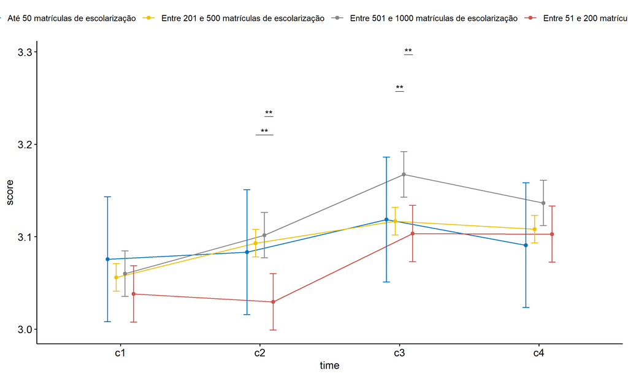

```r
pwc <- add_xy_position(pwc, x = "time", fun = "mean_se", dodge = 0.25)
pd <- position_dodge(width = 0.25)
ggline(emms, x = "time", y = "emmean", color = "porte",
       palette = c("#0073C2FF","#EFC000FF","#868686FF","#CD534CFF","#7AA6DCFF"),
       position = pd, ylab = "score") +
  geom_errorbar(aes(ymin = conf.low, ymax = conf.high, color = porte),
                position = pd, width = 0.2) +
  stat_pvalue_manual(pwc, hide.ns = T, tip.length = F, linetype = 1)
```

```r
(pwc <- ldat %>% group_by(porte) %>%
    emmeans_test(score ~ time, detailed = T, p.adjust.method = "bonferroni"))
```

```
## # A tibble: 24 × 15
##    porte  term  .y.   group1 group2 null.value estimate     se    df conf.low conf.high statistic
##  * <fct>  <chr> <chr> <chr>  <chr>       <dbl>    <dbl>  <dbl> <dbl>    <dbl>     <dbl>     <dbl>
##  1 Até 5… time  score c1     c2              0 -0.00758 0.0487  4460  -0.103    0.0880     -0.155
##  2 Até 5… time  score c1     c3              0 -0.0429  0.0487  4460  -0.138    0.0526     -0.881
##  3 Até 5… time  score c1     c4              0 -0.0152  0.0487  4460  -0.111    0.0804     -0.311
##  4 Até 5… time  score c2     c3              0 -0.0354  0.0487  4460  -0.131    0.0602     -0.725
##  5 Até 5… time  score c2     c4              0 -0.00758 0.0487  4460  -0.103    0.0880     -0.155
##  6 Até 5… time  score c3     c4              0  0.0278  0.0487  4460  -0.0678   0.123       0.570
##  7 Entre… time  score c1     c2              0 -0.0372  0.0108  4460  -0.0583  -0.0161     -3.45
##  8 Entre… time  score c1     c3              0 -0.0609  0.0108  4460  -0.0820  -0.0397     -5.65
##  9 Entre… time  score c1     c4              0 -0.0522  0.0108  4460  -0.0733  -0.0311     -4.85
## 10 Entre… time  score c2     c3              0 -0.0237  0.0108  4460  -0.0448  -0.00254    -2.20
## # ℹ 14 more rows
## # ℹ 3 more variables: p <dbl>, p.adj <dbl>, p.adj.signif <chr>
```

| porte | term | .y. | group1 | group2 | null.value | estimate | se | df | conf.low | conf.high | statistic | p | p.adj | p.adj.signif |
| --- | --- | --- | --- | --- | --- | --- | --- | --- | --- | --- | --- | --- | --- | --- |
| Até 50 matrículas de escolarização | time | score | c1 | c2 | 0 | -0.008 | 0.049 | 4460 | -0.103 | 0.088 | -0.155 | 0.876 | 1.000 | ns |
| Até 50 matrículas de escolarização | time | score | c1 | c3 | 0 | -0.043 | 0.049 | 4460 | -0.138 | 0.053 | -0.881 | 0.378 | 1.000 | ns |
| Até 50 matrículas de escolarização | time | score | c1 | c4 | 0 | -0.015 | 0.049 | 4460 | -0.111 | 0.080 | -0.311 | 0.756 | 1.000 | ns |
| Até 50 matrículas de escolarização | time | score | c2 | c3 | 0 | -0.035 | 0.049 | 4460 | -0.131 | 0.060 | -0.725 | 0.468 | 1.000 | ns |
| Até 50 matrículas de escolarização | time | score | c2 | c4 | 0 | -0.008 | 0.049 | 4460 | -0.103 | 0.088 | -0.155 | 0.876 | 1.000 | ns |
| Até 50 matrículas de escolarização | time | score | c3 | c4 | 0 | 0.028 | 0.049 | 4460 | -0.068 | 0.123 | 0.570 | 0.569 | 1.000 | ns |
| Entre 201 e 500 matrículas de escolarização | time | score | c1 | c2 | 0 | -0.037 | 0.011 | 4460 | -0.058 | -0.016 | -3.452 | 0.001 | 0.003 | ** |
| Entre 201 e 500 matrículas de escolarização | time | score | c1 | c3 | 0 | -0.061 | 0.011 | 4460 | -0.082 | -0.040 | -5.648 | 0.000 | 0.000 | **** |
| Entre 201 e 500 matrículas de escolarização | time | score | c1 | c4 | 0 | -0.052 | 0.011 | 4460 | -0.073 | -0.031 | -4.846 | 0.000 | 0.000 | **** |
| Entre 201 e 500 matrículas de escolarização | time | score | c2 | c3 | 0 | -0.024 | 0.011 | 4460 | -0.045 | -0.003 | -2.196 | 0.028 | 0.169 | ns |
| Entre 201 e 500 matrículas de escolarização | time | score | c2 | c4 | 0 | -0.015 | 0.011 | 4460 | -0.036 | 0.006 | -1.394 | 0.163 | 0.981 | ns |
| Entre 201 e 500 matrículas de escolarização | time | score | c3 | c4 | 0 | 0.009 | 0.011 | 4460 | -0.012 | 0.030 | 0.802 | 0.423 | 1.000 | ns |
| Entre 501 e 1000 matrículas de escolarização | time | score | c1 | c2 | 0 | -0.042 | 0.018 | 4460 | -0.076 | -0.007 | -2.345 | 0.019 | 0.114 | ns |
| Entre 501 e 1000 matrículas de escolarização | time | score | c1 | c3 | 0 | -0.107 | 0.018 | 4460 | -0.142 | -0.072 | -6.042 | 0.000 | 0.000 | **** |
| Entre 501 e 1000 matrículas de escolarização | time | score | c1 | c4 | 0 | -0.076 | 0.018 | 4460 | -0.111 | -0.042 | -4.307 | 0.000 | 0.000 | *** |
| Entre 501 e 1000 matrículas de escolarização | time | score | c2 | c3 | 0 | -0.066 | 0.018 | 4460 | -0.100 | -0.031 | -3.697 | 0.000 | 0.001 | ** |
| Entre 501 e 1000 matrículas de escolarização | time | score | c2 | c4 | 0 | -0.035 | 0.018 | 4460 | -0.070 | 0.000 | -1.962 | 0.050 | 0.299 | ns |
| Entre 501 e 1000 matrículas de escolarização | time | score | c3 | c4 | 0 | 0.031 | 0.018 | 4460 | -0.004 | 0.066 | 1.735 | 0.083 | 0.496 | ns |
| Entre 51 e 200 matrículas de escolarização | time | score | c1 | c2 | 0 | 0.008 | 0.022 | 4460 | -0.035 | 0.052 | 0.386 | 0.700 | 1.000 | ns |
| Entre 51 e 200 matrículas de escolarização | time | score | c1 | c3 | 0 | -0.065 | 0.022 | 4460 | -0.108 | -0.022 | -2.970 | 0.003 | 0.018 | * |
| Entre 51 e 200 matrículas de escolarização | time | score | c1 | c4 | 0 | -0.065 | 0.022 | 4460 | -0.108 | -0.022 | -2.947 | 0.003 | 0.019 | * |
| Entre 51 e 200 matrículas de escolarização | time | score | c2 | c3 | 0 | -0.074 | 0.022 | 4460 | -0.117 | -0.031 | -3.356 | 0.001 | 0.005 | ** |
| Entre 51 e 200 matrículas de escolarização | time | score | c2 | c4 | 0 | -0.073 | 0.022 | 4460 | -0.116 | -0.030 | -3.332 | 0.001 | 0.005 | ** |
| Entre 51 e 200 matrículas de escolarização | time | score | c3 | c4 | 0 | 0.001 | 0.022 | 4460 | -0.043 | 0.044 | 0.023 | 0.981 | 1.000 | ns |

```r
(emms <- get_emmeans(pwc))
```

```
## # A tibble: 16 × 8
##    porte                                     time  emmean      se    df conf.low conf.high method
##    <fct>                                     <fct>  <dbl>   <dbl> <dbl>    <dbl>     <dbl> <chr>
##  1 Até 50 matrículas de escolarização        c1      3.08 0.0345   4460     3.01      3.14 Emmea…
##  2 Até 50 matrículas de escolarização        c2      3.08 0.0345   4460     3.02      3.15 Emmea…
##  3 Até 50 matrículas de escolarização        c3      3.12 0.0345   4460     3.05      3.19 Emmea…
##  4 Até 50 matrículas de escolarização        c4      3.09 0.0345   4460     3.02      3.16 Emmea…
##  5 Entre 201 e 500 matrículas de escolariza… c1      3.06 0.00762  4460     3.04      3.07 Emmea…
##  6 Entre 201 e 500 matrículas de escolariza… c2      3.09 0.00762  4460     3.08      3.11 Emmea…
##  7 Entre 201 e 500 matrículas de escolariza… c3      3.12 0.00762  4460     3.10      3.13 Emmea…
##  8 Entre 201 e 500 matrículas de escolariza… c4      3.11 0.00762  4460     3.09      3.12 Emmea…
##  9 Entre 501 e 1000 matrículas de escolariz… c1      3.06 0.0125   4460     3.04      3.08 Emmea…
## 10 Entre 501 e 1000 matrículas de escolariz… c2      3.10 0.0125   4460     3.08      3.13 Emmea…
## 11 Entre 501 e 1000 matrículas de escolariz… c3      3.17 0.0125   4460     3.14      3.19 Emmea…
## 12 Entre 501 e 1000 matrículas de escolariz… c4      3.14 0.0125   4460     3.11      3.16 Emmea…
## 13 Entre 51 e 200 matrículas de escolarizaç… c1      3.04 0.0156   4460     3.01      3.07 Emmea…
## 14 Entre 51 e 200 matrículas de escolarizaç… c2      3.03 0.0156   4460     3.00      3.06 Emmea…
## 15 Entre 51 e 200 matrículas de escolarizaç… c3      3.10 0.0156   4460     3.07      3.13 Emmea…
## 16 Entre 51 e 200 matrículas de escolarizaç… c4      3.10 0.0156   4460     3.07      3.13 Emmea…
```

| porte | time | emmean | se | df | conf.low | conf.high | method |
| --- | --- | --- | --- | --- | --- | --- | --- |
| Até 50 matrículas de escolarização | c1 | 3.076 | 0.034 | 4460 | 3.008 | 3.143 | Emmeans test |
| Até 50 matrículas de escolarização | c2 | 3.083 | 0.034 | 4460 | 3.016 | 3.151 | Emmeans test |
| Até 50 matrículas de escolarização | c3 | 3.119 | 0.034 | 4460 | 3.051 | 3.186 | Emmeans test |
| Até 50 matrículas de escolarização | c4 | 3.091 | 0.034 | 4460 | 3.023 | 3.158 | Emmeans test |
| Entre 201 e 500 matrículas de escolarização | c1 | 3.056 | 0.008 | 4460 | 3.041 | 3.071 | Emmeans test |
| Entre 201 e 500 matrículas de escolarização | c2 | 3.093 | 0.008 | 4460 | 3.078 | 3.108 | Emmeans test |
| Entre 201 e 500 matrículas de escolarização | c3 | 3.117 | 0.008 | 4460 | 3.102 | 3.132 | Emmeans test |
| Entre 201 e 500 matrículas de escolarização | c4 | 3.108 | 0.008 | 4460 | 3.093 | 3.123 | Emmeans test |
| Entre 501 e 1000 matrículas de escolarização | c1 | 3.060 | 0.013 | 4460 | 3.036 | 3.085 | Emmeans test |
| Entre 501 e 1000 matrículas de escolarização | c2 | 3.102 | 0.013 | 4460 | 3.077 | 3.126 | Emmeans test |
| Entre 501 e 1000 matrículas de escolarização | c3 | 3.167 | 0.013 | 4460 | 3.143 | 3.192 | Emmeans test |
| Entre 501 e 1000 matrículas de escolarização | c4 | 3.137 | 0.013 | 4460 | 3.112 | 3.161 | Emmeans test |
| Entre 51 e 200 matrículas de escolarização | c1 | 3.038 | 0.016 | 4460 | 3.008 | 3.069 | Emmeans test |
| Entre 51 e 200 matrículas de escolarização | c2 | 3.030 | 0.016 | 4460 | 2.999 | 3.060 | Emmeans test |
| Entre 51 e 200 matrículas de escolarização | c3 | 3.103 | 0.016 | 4460 | 3.073 | 3.134 | Emmeans test |
| Entre 51 e 200 matrículas de escolarização | c4 | 3.103 | 0.016 | 4460 | 3.072 | 3.133 | Emmeans test |

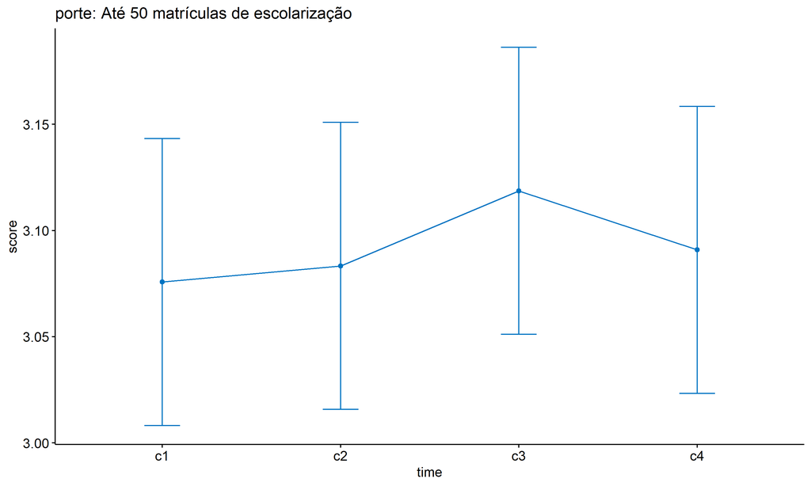

```r
emms.gg <- emms[which(emms$porte == "Até 50 matrículas de escolarização"),]
if (nrow(emms.gg) > 0)
  ggline(emms.gg, x = "time", y = "emmean", color = "#0073C2FF", ylab = "score") +
    geom_errorbar(aes(ymin = conf.low, ymax = conf.high),
                  width = 0.2, color = "#0073C2FF") +
    stat_pvalue_manual(
      add_xy_position(pwc[which(pwc$porte == "Até 50 matrículas de escolarização"),],
                      x = "time", fun = "mean_se"),
      hide.ns = T, color = "#0073C2FF", tip.length = F) +
    labs(title = "porte: Até 50 matrículas de escolarização")+
    theme(legend.text = element_blank())
```

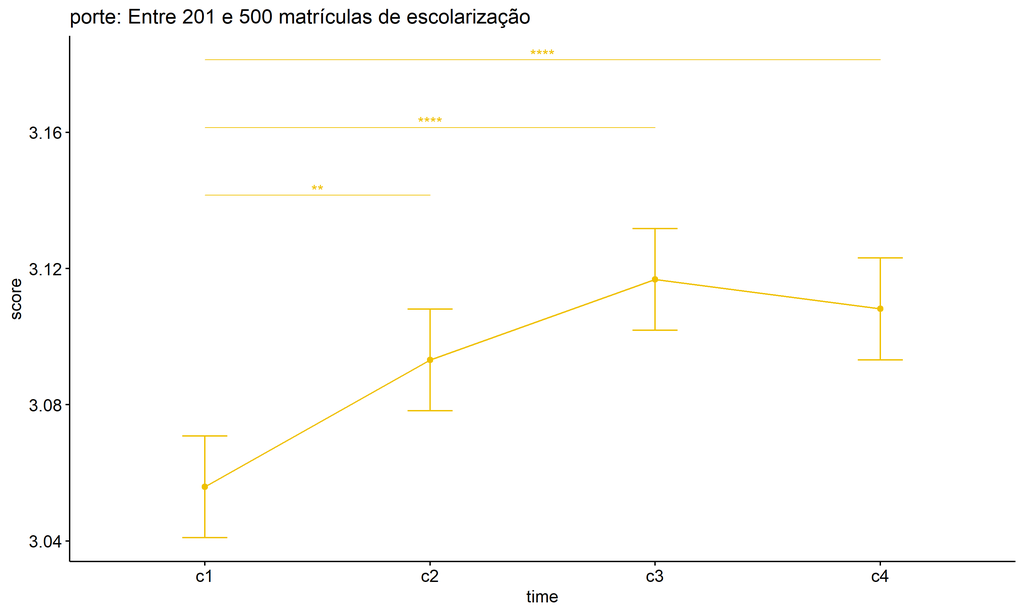

```r
emms.gg <- emms[which(emms$porte == "Entre 201 e 500 matrículas de escolarização"),]
if (nrow(emms.gg) > 0)
  ggline(emms.gg, x = "time", y = "emmean", color = "#EFC000FF", ylab = "score") +
    geom_errorbar(aes(ymin = conf.low, ymax = conf.high),
                  width = 0.2, color = "#EFC000FF") +
    stat_pvalue_manual(
      add_xy_position(pwc[which(pwc$porte == "Entre 201 e 500 matrículas de escolarização"),],
                      x = "time", fun = "mean_se"),
      hide.ns = T, color = "#EFC000FF", tip.length = F) +
    labs(title = "porte: Entre 201 e 500 matrículas de escolarização")+
    theme(legend.text = element_blank())
```

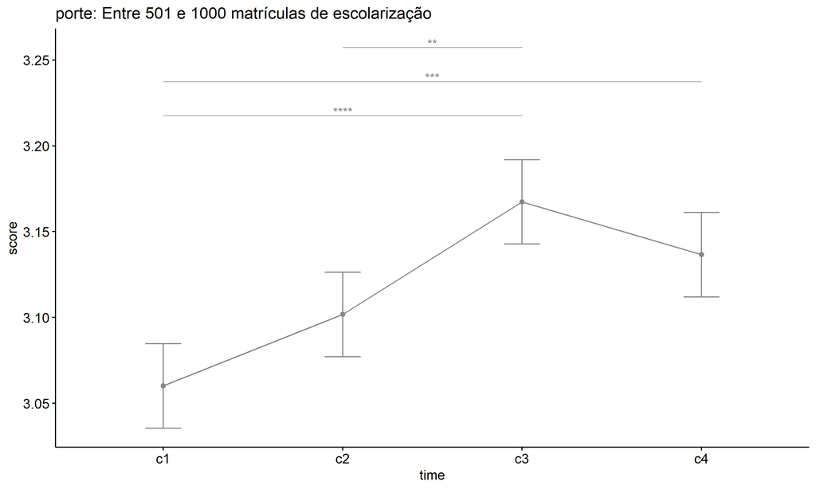

```r
emms.gg <- emms[which(emms$porte == "Entre 501 e 1000 matrículas de escolarização"),]
if (nrow(emms.gg) > 0)
  ggline(emms.gg, x = "time", y = "emmean", color = "#868686FF", ylab = "score") +
    geom_errorbar(aes(ymin = conf.low, ymax = conf.high),
                  width = 0.2, color = "#868686FF") +
    stat_pvalue_manual(
      add_xy_position(pwc[which(pwc$porte == "Entre 501 e 1000 matrículas de escolarização"),],
                      x = "time", fun = "mean_se"),
      hide.ns = T, color = "#868686FF", tip.length = F) +
    labs(title = "porte: Entre 501 e 1000 matrículas de escolarização")+
    theme(legend.text = element_blank())
```

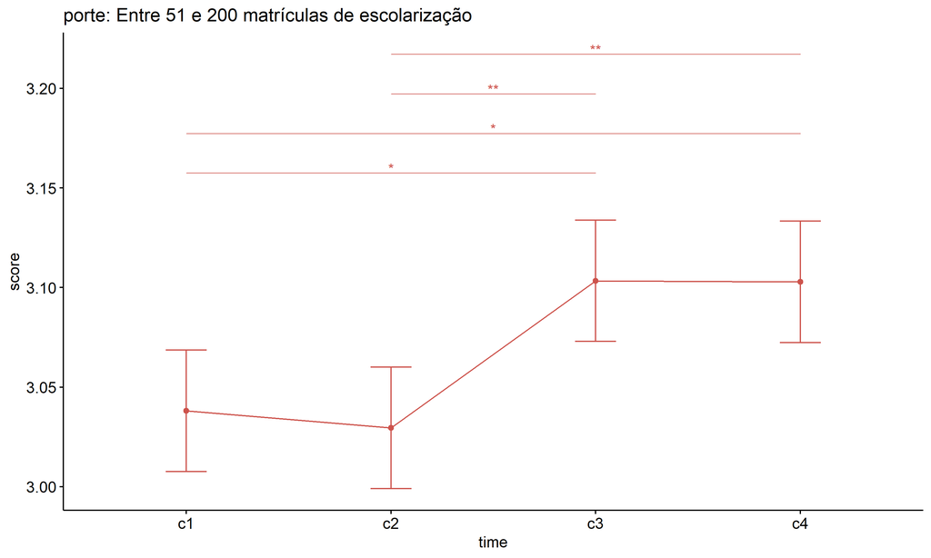

```r
emms.gg <- emms[which(emms$porte == "Entre 51 e 200 matrículas de escolarização"),]
if (nrow(emms.gg) > 0)
  ggline(emms.gg, x = "time", y = "emmean", color = "#CD534CFF", ylab = "score") +
    geom_errorbar(aes(ymin = conf.low, ymax = conf.high),
                  width = 0.2, color = "#CD534CFF") +
    stat_pvalue_manual(
      add_xy_position(pwc[which(pwc$porte == "Entre 51 e 200 matrículas de escolarização"),],
                      x = "time", fun = "mean_se"),
      hide.ns = T, color = "#CD534CFF", tip.length = F) +
    labs(title = "porte: Entre 51 e 200 matrículas de escolarização")+
    theme(legend.text = element_blank())
```

```r
emms.gg <- emms[which(emms$porte == "Mais de 1000 matrículas de escolarização"),]
if (nrow(emms.gg) > 0)
  ggline(emms.gg, x = "time", y = "emmean", color = "#7AA6DCFF", ylab = "score") +
    geom_errorbar(aes(ymin = conf.low, ymax = conf.high),
                  width = 0.2, color = "#7AA6DCFF") +
    stat_pvalue_manual(
      add_xy_position(pwc[which(pwc$porte == "Mais de 1000 matrículas de escolarização"),],
                      x = "time", fun = "mean_se"),
      hide.ns = T, color = "#7AA6DCFF", tip.length = F) +
    labs(title = "porte: Mais de 1000 matrículas de escolarização")+
    theme(legend.text = element_blank())
```

## PairWise Computation after removing non.normal data

```r
if (length(non.ids) > 0)
  (pwc2 <- ldat2 %>% group_by(time) %>%
     emmeans_test(score ~ porte, detailed = T, p.adjust.method = "bonferroni"))
```

```
## # A tibble: 24 × 15
##    time  term  .y.   group1  group2 null.value estimate     se    df conf.low conf.high statistic
##  * <fct> <chr> <chr> <chr>   <chr>       <dbl>    <dbl>  <dbl> <dbl>    <dbl>     <dbl>     <dbl>
##  1 c1    porte score Até 50… Entre…          0  0.00889 0.0663  4364  -0.121     0.139     0.134
##  2 c1    porte score Até 50… Entre…          0  0.00469 0.0671  4364  -0.127     0.136     0.0698
##  3 c1    porte score Até 50… Entre…          0  0.0267  0.0677  4364  -0.106     0.159     0.395
##  4 c1    porte score Entre … Entre…          0 -0.00420 0.0147  4364  -0.0329    0.0245   -0.287
##  5 c1    porte score Entre … Entre…          0  0.0179  0.0173  4364  -0.0161    0.0518    1.03
##  6 c1    porte score Entre … Entre…          0  0.0221  0.0200  4364  -0.0171    0.0612    1.11
##  7 c2    porte score Até 50… Entre…          0 -0.0468  0.0663  4364  -0.177     0.0832   -0.706
##  8 c2    porte score Até 50… Entre…          0 -0.0554  0.0671  4364  -0.187     0.0761   -0.826
##  9 c2    porte score Até 50… Entre…          0  0.0167  0.0677  4364  -0.116     0.149     0.247
## 10 c2    porte score Entre … Entre…          0 -0.00861 0.0147  4364  -0.0374    0.0201   -0.588
## # ℹ 14 more rows
## # ℹ 3 more variables: p <dbl>, p.adj <dbl>, p.adj.signif <chr>
```

| time | term | .y. | group1 | group2 | null.value | estimate | se | df | conf.low | conf.high | statistic | p | p.adj | p.adj.signif |
| --- | --- | --- | --- | --- | --- | --- | --- | --- | --- | --- | --- | --- | --- | --- |
| c1 | porte | score | Até 50 matrículas de escolarização | Entre 201 e 500 matrículas de escolarização | 0 | 0.009 | 0.066 | 4364 | -0.121 | 0.139 | 0.134 | 0.893 | 1.000 | ns |
| c1 | porte | score | Até 50 matrículas de escolarização | Entre 501 e 1000 matrículas de escolarização | 0 | 0.005 | 0.067 | 4364 | -0.127 | 0.136 | 0.070 | 0.944 | 1.000 | ns |
| c1 | porte | score | Até 50 matrículas de escolarização | Entre 51 e 200 matrículas de escolarização | 0 | 0.027 | 0.068 | 4364 | -0.106 | 0.159 | 0.395 | 0.693 | 1.000 | ns |
| c1 | porte | score | Entre 201 e 500 matrículas de escolarização | Entre 501 e 1000 matrículas de escolarização | 0 | -0.004 | 0.015 | 4364 | -0.033 | 0.025 | -0.287 | 0.774 | 1.000 | ns |
| c1 | porte | score | Entre 201 e 500 matrículas de escolarização | Entre 51 e 200 matrículas de escolarização | 0 | 0.018 | 0.017 | 4364 | -0.016 | 0.052 | 1.032 | 0.302 | 1.000 | ns |
| c1 | porte | score | Entre 501 e 1000 matrículas de escolarização | Entre 51 e 200 matrículas de escolarização | 0 | 0.022 | 0.020 | 4364 | -0.017 | 0.061 | 1.106 | 0.269 | 1.000 | ns |
| c2 | porte | score | Até 50 matrículas de escolarização | Entre 201 e 500 matrículas de escolarização | 0 | -0.047 | 0.066 | 4364 | -0.177 | 0.083 | -0.706 | 0.480 | 1.000 | ns |
| c2 | porte | score | Até 50 matrículas de escolarização | Entre 501 e 1000 matrículas de escolarização | 0 | -0.055 | 0.067 | 4364 | -0.187 | 0.076 | -0.826 | 0.409 | 1.000 | ns |
| c2 | porte | score | Até 50 matrículas de escolarização | Entre 51 e 200 matrículas de escolarização | 0 | 0.017 | 0.068 | 4364 | -0.116 | 0.149 | 0.247 | 0.805 | 1.000 | ns |
| c2 | porte | score | Entre 201 e 500 matrículas de escolarização | Entre 501 e 1000 matrículas de escolarização | 0 | -0.009 | 0.015 | 4364 | -0.037 | 0.020 | -0.588 | 0.557 | 1.000 | ns |
| c2 | porte | score | Entre 201 e 500 matrículas de escolarização | Entre 51 e 200 matrículas de escolarização | 0 | 0.064 | 0.017 | 4364 | 0.030 | 0.097 | 3.674 | 0.000 | 0.001 | ** |
| c2 | porte | score | Entre 501 e 1000 matrículas de escolarização | Entre 51 e 200 matrículas de escolarização | 0 | 0.072 | 0.020 | 4364 | 0.033 | 0.111 | 3.616 | 0.000 | 0.002 | ** |
| c3 | porte | score | Até 50 matrículas de escolarização | Entre 201 e 500 matrículas de escolarização | 0 | -0.052 | 0.066 | 4364 | -0.182 | 0.078 | -0.783 | 0.433 | 1.000 | ns |
| c3 | porte | score | Até 50 matrículas de escolarização | Entre 501 e 1000 matrículas de escolarização | 0 | -0.103 | 0.067 | 4364 | -0.234 | 0.029 | -1.528 | 0.127 | 0.759 | ns |
| c3 | porte | score | Até 50 matrículas de escolarização | Entre 51 e 200 matrículas de escolarização | 0 | -0.039 | 0.068 | 4364 | -0.171 | 0.094 | -0.570 | 0.569 | 1.000 | ns |
| c3 | porte | score | Entre 201 e 500 matrículas de escolarização | Entre 501 e 1000 matrículas de escolarização | 0 | -0.051 | 0.015 | 4364 | -0.079 | -0.022 | -3.448 | 0.001 | 0.003 | ** |
| c3 | porte | score | Entre 201 e 500 matrículas de escolarização | Entre 51 e 200 matrículas de escolarização | 0 | 0.013 | 0.017 | 4364 | -0.021 | 0.047 | 0.774 | 0.439 | 1.000 | ns |
| c3 | porte | score | Entre 501 e 1000 matrículas de escolarização | Entre 51 e 200 matrículas de escolarização | 0 | 0.064 | 0.020 | 4364 | 0.025 | 0.103 | 3.204 | 0.001 | 0.008 | ** |
| c4 | porte | score | Até 50 matrículas de escolarização | Entre 201 e 500 matrículas de escolarização | 0 | -0.090 | 0.066 | 4364 | -0.220 | 0.040 | -1.351 | 0.177 | 1.000 | ns |
| c4 | porte | score | Até 50 matrículas de escolarização | Entre 501 e 1000 matrículas de escolarização | 0 | -0.118 | 0.067 | 4364 | -0.250 | 0.013 | -1.759 | 0.079 | 0.472 | ns |
| c4 | porte | score | Até 50 matrículas de escolarização | Entre 51 e 200 matrículas de escolarização | 0 | -0.084 | 0.068 | 4364 | -0.217 | 0.048 | -1.246 | 0.213 | 1.000 | ns |
| c4 | porte | score | Entre 201 e 500 matrículas de escolarização | Entre 501 e 1000 matrículas de escolarização | 0 | -0.028 | 0.015 | 4364 | -0.057 | 0.000 | -1.937 | 0.053 | 0.317 | ns |
| c4 | porte | score | Entre 201 e 500 matrículas de escolarização | Entre 51 e 200 matrículas de escolarização | 0 | 0.005 | 0.017 | 4364 | -0.029 | 0.039 | 0.305 | 0.761 | 1.000 | ns |
| c4 | porte | score | Entre 501 e 1000 matrículas de escolarização | Entre 51 e 200 matrículas de escolarização | 0 | 0.034 | 0.020 | 4364 | -0.005 | 0.073 | 1.687 | 0.092 | 0.550 | ns |

```r
if (length(non.ids) > 0)
  (emms2 <- get_emmeans(pwc2))
```

```
## # A tibble: 16 × 8
##    time  porte                                     emmean      se    df conf.low conf.high method
##    <fct> <fct>                                      <dbl>   <dbl> <dbl>    <dbl>     <dbl> <chr>
##  1 c1    Até 50 matrículas de escolarização          3.06 0.0659   4364     2.94      3.19 Emmea…
##  2 c1    Entre 201 e 500 matrículas de escolariza…   3.06 0.00761  4364     3.04      3.07 Emmea…
##  3 c1    Entre 501 e 1000 matrículas de escolariz…   3.06 0.0125   4364     3.04      3.08 Emmea…
##  4 c1    Entre 51 e 200 matrículas de escolarizaç…   3.04 0.0155   4364     3.01      3.07 Emmea…
##  5 c2    Até 50 matrículas de escolarização          3.05 0.0659   4364     2.92      3.18 Emmea…
##  6 c2    Entre 201 e 500 matrículas de escolariza…   3.09 0.00761  4364     3.08      3.11 Emmea…
##  7 c2    Entre 501 e 1000 matrículas de escolariz…   3.10 0.0125   4364     3.08      3.13 Emmea…
##  8 c2    Entre 51 e 200 matrículas de escolarizaç…   3.03 0.0155   4364     3.00      3.06 Emmea…
##  9 c3    Até 50 matrículas de escolarização          3.06 0.0659   4364     2.94      3.19 Emmea…
## 10 c3    Entre 201 e 500 matrículas de escolariza…   3.12 0.00761  4364     3.10      3.13 Emmea…
## 11 c3    Entre 501 e 1000 matrículas de escolariz…   3.17 0.0125   4364     3.14      3.19 Emmea…
## 12 c3    Entre 51 e 200 matrículas de escolarizaç…   3.10 0.0155   4364     3.07      3.13 Emmea…
## 13 c4    Até 50 matrículas de escolarização          3.02 0.0659   4364     2.89      3.15 Emmea…
## 14 c4    Entre 201 e 500 matrículas de escolariza…   3.11 0.00761  4364     3.09      3.12 Emmea…
## 15 c4    Entre 501 e 1000 matrículas de escolariz…   3.14 0.0125   4364     3.11      3.16 Emmea…
## 16 c4    Entre 51 e 200 matrículas de escolarizaç…   3.10 0.0155   4364     3.07      3.13 Emmea…
```

| time | porte | emmean | se | df | conf.low | conf.high | method |
| --- | --- | --- | --- | --- | --- | --- | --- |
| c1 | Até 50 matrículas de escolarização | 3.065 | 0.066 | 4364 | 2.936 | 3.194 | Emmeans test |
| c1 | Entre 201 e 500 matrículas de escolarização | 3.056 | 0.008 | 4364 | 3.041 | 3.071 | Emmeans test |
| c1 | Entre 501 e 1000 matrículas de escolarização | 3.060 | 0.013 | 4364 | 3.036 | 3.085 | Emmeans test |
| c1 | Entre 51 e 200 matrículas de escolarização | 3.038 | 0.016 | 4364 | 3.008 | 3.069 | Emmeans test |
| c2 | Até 50 matrículas de escolarização | 3.046 | 0.066 | 4364 | 2.917 | 3.176 | Emmeans test |
| c2 | Entre 201 e 500 matrículas de escolarização | 3.093 | 0.008 | 4364 | 3.078 | 3.108 | Emmeans test |
| c2 | Entre 501 e 1000 matrículas de escolarização | 3.102 | 0.013 | 4364 | 3.077 | 3.126 | Emmeans test |
| c2 | Entre 51 e 200 matrículas de escolarização | 3.030 | 0.016 | 4364 | 2.999 | 3.060 | Emmeans test |
| c3 | Até 50 matrículas de escolarização | 3.065 | 0.066 | 4364 | 2.936 | 3.194 | Emmeans test |
| c3 | Entre 201 e 500 matrículas de escolarização | 3.117 | 0.008 | 4364 | 3.102 | 3.132 | Emmeans test |
| c3 | Entre 501 e 1000 matrículas de escolarização | 3.167 | 0.013 | 4364 | 3.143 | 3.192 | Emmeans test |
| c3 | Entre 51 e 200 matrículas de escolarização | 3.103 | 0.016 | 4364 | 3.073 | 3.134 | Emmeans test |
| c4 | Até 50 matrículas de escolarização | 3.019 | 0.066 | 4364 | 2.889 | 3.148 | Emmeans test |
| c4 | Entre 201 e 500 matrículas de escolarização | 3.108 | 0.008 | 4364 | 3.093 | 3.123 | Emmeans test |
| c4 | Entre 501 e 1000 matrículas de escolarização | 3.137 | 0.013 | 4364 | 3.112 | 3.161 | Emmeans test |
| c4 | Entre 51 e 200 matrículas de escolarização | 3.103 | 0.016 | 4364 | 3.072 | 3.133 | Emmeans test |

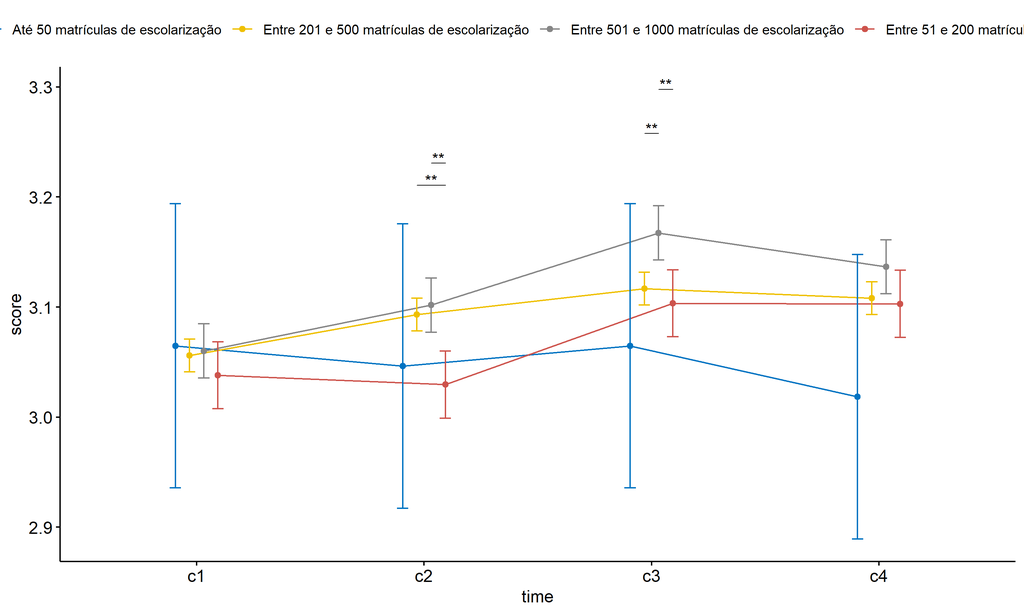

```r
if (length(non.ids) > 0) {
  pwc2 <- add_xy_position(pwc2, x = "time", fun = "mean_se", dodge = 0.25)
  pd2 <- position_dodge(width = 0.25)

  ggline(emms2, x = "time", y = "emmean", color = "porte",
         palette = c("#0073C2FF","#EFC000FF","#868686FF","#CD534CFF","#7AA6DCFF"),
         position = pd, ylab = "score") +
    geom_errorbar(aes(ymin = conf.low, ymax = conf.high, color = porte),
                position = pd, width = 0.2) +
    stat_pvalue_manual(pwc2, hide.ns = T, tip.length = F, linetype = 1)
}
```

```r
if (length(non.ids) > 0)
  (pwc2 <- ldat2 %>% group_by(porte) %>%
     emmeans_test(score ~ time, detailed = T, p.adjust.method = "bonferroni"))
```

```
## # A tibble: 24 × 15
##    porte term  .y.   group1 group2 null.value  estimate     se    df conf.low conf.high statistic
##  * <fct> <chr> <chr> <chr>  <chr>       <dbl>     <dbl>  <dbl> <dbl>    <dbl>     <dbl>     <dbl>
##  1 Até … time  score c1     c2              0  1.85e- 2 0.0932  4364  -0.164    0.201    1.99e- 1
##  2 Até … time  score c1     c3              0  7.31e-14 0.0932  4364  -0.183    0.183    7.85e-13
##  3 Até … time  score c1     c4              0  4.63e- 2 0.0932  4364  -0.136    0.229    4.97e- 1
##  4 Até … time  score c2     c3              0 -1.85e- 2 0.0932  4364  -0.201    0.164   -1.99e- 1
##  5 Até … time  score c2     c4              0  2.78e- 2 0.0932  4364  -0.155    0.211    2.98e- 1
##  6 Até … time  score c3     c4              0  4.63e- 2 0.0932  4364  -0.136    0.229    4.97e- 1
##  7 Entr… time  score c1     c2              0 -3.72e- 2 0.0108  4364  -0.0583  -0.0161  -3.46e+ 0
##  8 Entr… time  score c1     c3              0 -6.09e- 2 0.0108  4364  -0.0820  -0.0398  -5.66e+ 0
##  9 Entr… time  score c1     c4              0 -5.22e- 2 0.0108  4364  -0.0733  -0.0311  -4.85e+ 0
## 10 Entr… time  score c2     c3              0 -2.37e- 2 0.0108  4364  -0.0448  -0.00256 -2.20e+ 0
## # ℹ 14 more rows
## # ℹ 3 more variables: p <dbl>, p.adj <dbl>, p.adj.signif <chr>
```

| porte | term | .y. | group1 | group2 | null.value | estimate | se | df | conf.low | conf.high | statistic | p | p.adj | p.adj.signif |
| --- | --- | --- | --- | --- | --- | --- | --- | --- | --- | --- | --- | --- | --- | --- |
| Até 50 matrículas de escolarização | time | score | c1 | c2 | 0 | 0.019 | 0.093 | 4364 | -0.164 | 0.201 | 0.199 | 0.843 | 1.000 | ns |
| Até 50 matrículas de escolarização | time | score | c1 | c3 | 0 | 0.000 | 0.093 | 4364 | -0.183 | 0.183 | 0.000 | 1.000 | 1.000 | ns |
| Até 50 matrículas de escolarização | time | score | c1 | c4 | 0 | 0.046 | 0.093 | 4364 | -0.136 | 0.229 | 0.497 | 0.619 | 1.000 | ns |
| Até 50 matrículas de escolarização | time | score | c2 | c3 | 0 | -0.019 | 0.093 | 4364 | -0.201 | 0.164 | -0.199 | 0.843 | 1.000 | ns |
| Até 50 matrículas de escolarização | time | score | c2 | c4 | 0 | 0.028 | 0.093 | 4364 | -0.155 | 0.211 | 0.298 | 0.766 | 1.000 | ns |
| Até 50 matrículas de escolarização | time | score | c3 | c4 | 0 | 0.046 | 0.093 | 4364 | -0.136 | 0.229 | 0.497 | 0.619 | 1.000 | ns |
| Entre 201 e 500 matrículas de escolarização | time | score | c1 | c2 | 0 | -0.037 | 0.011 | 4364 | -0.058 | -0.016 | -3.457 | 0.001 | 0.003 | ** |
| Entre 201 e 500 matrículas de escolarização | time | score | c1 | c3 | 0 | -0.061 | 0.011 | 4364 | -0.082 | -0.040 | -5.655 | 0.000 | 0.000 | **** |
| Entre 201 e 500 matrículas de escolarização | time | score | c1 | c4 | 0 | -0.052 | 0.011 | 4364 | -0.073 | -0.031 | -4.852 | 0.000 | 0.000 | **** |
| Entre 201 e 500 matrículas de escolarização | time | score | c2 | c3 | 0 | -0.024 | 0.011 | 4364 | -0.045 | -0.003 | -2.199 | 0.028 | 0.168 | ns |
| Entre 201 e 500 matrículas de escolarização | time | score | c2 | c4 | 0 | -0.015 | 0.011 | 4364 | -0.036 | 0.006 | -1.396 | 0.163 | 0.977 | ns |
| Entre 201 e 500 matrículas de escolarização | time | score | c3 | c4 | 0 | 0.009 | 0.011 | 4364 | -0.012 | 0.030 | 0.803 | 0.422 | 1.000 | ns |
| Entre 501 e 1000 matrículas de escolarização | time | score | c1 | c2 | 0 | -0.042 | 0.018 | 4364 | -0.076 | -0.007 | -2.348 | 0.019 | 0.113 | ns |
| Entre 501 e 1000 matrículas de escolarização | time | score | c1 | c3 | 0 | -0.107 | 0.018 | 4364 | -0.142 | -0.072 | -6.050 | 0.000 | 0.000 | **** |
| Entre 501 e 1000 matrículas de escolarização | time | score | c1 | c4 | 0 | -0.076 | 0.018 | 4364 | -0.111 | -0.042 | -4.313 | 0.000 | 0.000 | **** |
| Entre 501 e 1000 matrículas de escolarização | time | score | c2 | c3 | 0 | -0.066 | 0.018 | 4364 | -0.100 | -0.031 | -3.702 | 0.000 | 0.001 | ** |
| Entre 501 e 1000 matrículas de escolarização | time | score | c2 | c4 | 0 | -0.035 | 0.018 | 4364 | -0.070 | 0.000 | -1.964 | 0.050 | 0.297 | ns |
| Entre 501 e 1000 matrículas de escolarização | time | score | c3 | c4 | 0 | 0.031 | 0.018 | 4364 | -0.004 | 0.066 | 1.738 | 0.082 | 0.494 | ns |
| Entre 51 e 200 matrículas de escolarização | time | score | c1 | c2 | 0 | 0.008 | 0.022 | 4364 | -0.035 | 0.052 | 0.386 | 0.699 | 1.000 | ns |
| Entre 51 e 200 matrículas de escolarização | time | score | c1 | c3 | 0 | -0.065 | 0.022 | 4364 | -0.108 | -0.022 | -2.974 | 0.003 | 0.018 | * |
| Entre 51 e 200 matrículas de escolarização | time | score | c1 | c4 | 0 | -0.065 | 0.022 | 4364 | -0.108 | -0.022 | -2.950 | 0.003 | 0.019 | * |
| Entre 51 e 200 matrículas de escolarização | time | score | c2 | c3 | 0 | -0.074 | 0.022 | 4364 | -0.117 | -0.031 | -3.360 | 0.001 | 0.005 | ** |
| Entre 51 e 200 matrículas de escolarização | time | score | c2 | c4 | 0 | -0.073 | 0.022 | 4364 | -0.116 | -0.030 | -3.337 | 0.001 | 0.005 | ** |
| Entre 51 e 200 matrículas de escolarização | time | score | c3 | c4 | 0 | 0.001 | 0.022 | 4364 | -0.043 | 0.044 | 0.023 | 0.981 | 1.000 | ns |

```r
if (length(non.ids) > 0)
  (emms2 <- get_emmeans(pwc2))
```

```
## # A tibble: 16 × 8
##    porte                                     time  emmean      se    df conf.low conf.high method
##    <fct>                                     <fct>  <dbl>   <dbl> <dbl>    <dbl>     <dbl> <chr>
##  1 Até 50 matrículas de escolarização        c1      3.06 0.0659   4364     2.94      3.19 Emmea…
##  2 Até 50 matrículas de escolarização        c2      3.05 0.0659   4364     2.92      3.18 Emmea…
##  3 Até 50 matrículas de escolarização        c3      3.06 0.0659   4364     2.94      3.19 Emmea…
##  4 Até 50 matrículas de escolarização        c4      3.02 0.0659   4364     2.89      3.15 Emmea…
##  5 Entre 201 e 500 matrículas de escolariza… c1      3.06 0.00761  4364     3.04      3.07 Emmea…
##  6 Entre 201 e 500 matrículas de escolariza… c2      3.09 0.00761  4364     3.08      3.11 Emmea…
##  7 Entre 201 e 500 matrículas de escolariza… c3      3.12 0.00761  4364     3.10      3.13 Emmea…
##  8 Entre 201 e 500 matrículas de escolariza… c4      3.11 0.00761  4364     3.09      3.12 Emmea…
##  9 Entre 501 e 1000 matrículas de escolariz… c1      3.06 0.0125   4364     3.04      3.08 Emmea…
## 10 Entre 501 e 1000 matrículas de escolariz… c2      3.10 0.0125   4364     3.08      3.13 Emmea…
## 11 Entre 501 e 1000 matrículas de escolariz… c3      3.17 0.0125   4364     3.14      3.19 Emmea…
## 12 Entre 501 e 1000 matrículas de escolariz… c4      3.14 0.0125   4364     3.11      3.16 Emmea…
## 13 Entre 51 e 200 matrículas de escolarizaç… c1      3.04 0.0155   4364     3.01      3.07 Emmea…
## 14 Entre 51 e 200 matrículas de escolarizaç… c2      3.03 0.0155   4364     3.00      3.06 Emmea…
## 15 Entre 51 e 200 matrículas de escolarizaç… c3      3.10 0.0155   4364     3.07      3.13 Emmea…
## 16 Entre 51 e 200 matrículas de escolarizaç… c4      3.10 0.0155   4364     3.07      3.13 Emmea…
```

| porte | time | emmean | se | df | conf.low | conf.high | method |
| --- | --- | --- | --- | --- | --- | --- | --- |
| Até 50 matrículas de escolarização | c1 | 3.065 | 0.066 | 4364 | 2.936 | 3.194 | Emmeans test |
| Até 50 matrículas de escolarização | c2 | 3.046 | 0.066 | 4364 | 2.917 | 3.176 | Emmeans test |
| Até 50 matrículas de escolarização | c3 | 3.065 | 0.066 | 4364 | 2.936 | 3.194 | Emmeans test |
| Até 50 matrículas de escolarização | c4 | 3.019 | 0.066 | 4364 | 2.889 | 3.148 | Emmeans test |
| Entre 201 e 500 matrículas de escolarização | c1 | 3.056 | 0.008 | 4364 | 3.041 | 3.071 | Emmeans test |
| Entre 201 e 500 matrículas de escolarização | c2 | 3.093 | 0.008 | 4364 | 3.078 | 3.108 | Emmeans test |
| Entre 201 e 500 matrículas de escolarização | c3 | 3.117 | 0.008 | 4364 | 3.102 | 3.132 | Emmeans test |
| Entre 201 e 500 matrículas de escolarização | c4 | 3.108 | 0.008 | 4364 | 3.093 | 3.123 | Emmeans test |
| Entre 501 e 1000 matrículas de escolarização | c1 | 3.060 | 0.013 | 4364 | 3.036 | 3.085 | Emmeans test |
| Entre 501 e 1000 matrículas de escolarização | c2 | 3.102 | 0.013 | 4364 | 3.077 | 3.126 | Emmeans test |
| Entre 501 e 1000 matrículas de escolarização | c3 | 3.167 | 0.013 | 4364 | 3.143 | 3.192 | Emmeans test |
| Entre 501 e 1000 matrículas de escolarização | c4 | 3.137 | 0.013 | 4364 | 3.112 | 3.161 | Emmeans test |
| Entre 51 e 200 matrículas de escolarização | c1 | 3.038 | 0.016 | 4364 | 3.008 | 3.069 | Emmeans test |
| Entre 51 e 200 matrículas de escolarização | c2 | 3.030 | 0.016 | 4364 | 2.999 | 3.060 | Emmeans test |
| Entre 51 e 200 matrículas de escolarização | c3 | 3.103 | 0.016 | 4364 | 3.073 | 3.134 | Emmeans test |
| Entre 51 e 200 matrículas de escolarização | c4 | 3.103 | 0.016 | 4364 | 3.072 | 3.133 | Emmeans test |

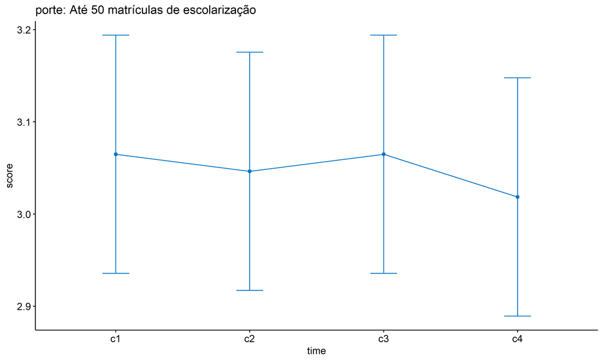

```r
if (length(non.ids) > 0) {
  emms.gg <- emms2[which(emms2$porte == "Até 50 matrículas de escolarização"),]
  if (nrow(emms.gg) > 0)
    ggline(emms.gg, x = "time", y = "emmean", color = "#0073C2FF", ylab = "score") +
    geom_errorbar(aes(ymin = conf.low, ymax = conf.high),
                  width = 0.2, color = "#0073C2FF") +
    stat_pvalue_manual(
      add_xy_position(pwc[which(pwc$porte == "Até 50 matrículas de escolarização"),],
                      x = "time", fun = "mean_se"),
      hide.ns = T, color = "#0073C2FF", tip.length = F) +
    labs(title = "porte: Até 50 matrículas de escolarização") +
    theme(legend.text = element_blank())
}
```

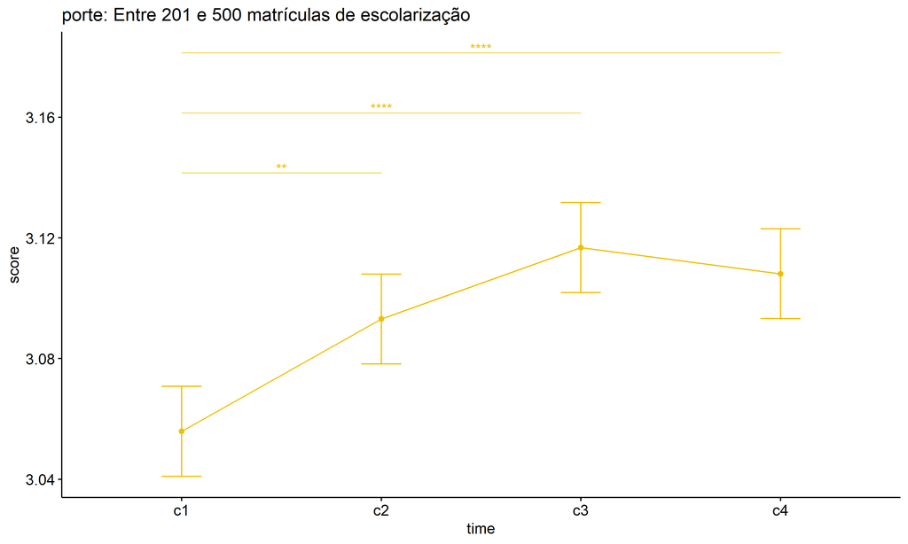

```r
if (length(non.ids) > 0) {
  emms.gg <- emms2[which(emms2$porte == "Entre 201 e 500 matrículas de escolarização"),]
  if (nrow(emms.gg) > 0)
    ggline(emms.gg, x = "time", y = "emmean", color = "#EFC000FF", ylab = "score") +
    geom_errorbar(aes(ymin = conf.low, ymax = conf.high),
                  width = 0.2, color = "#EFC000FF") +
    stat_pvalue_manual(
      add_xy_position(pwc[which(pwc$porte == "Entre 201 e 500 matrículas de escolarização"),],
                      x = "time", fun = "mean_se"),
      hide.ns = T, color = "#EFC000FF", tip.length = F) +
    labs(title = "porte: Entre 201 e 500 matrículas de escolarização") +
    theme(legend.text = element_blank())
}
```

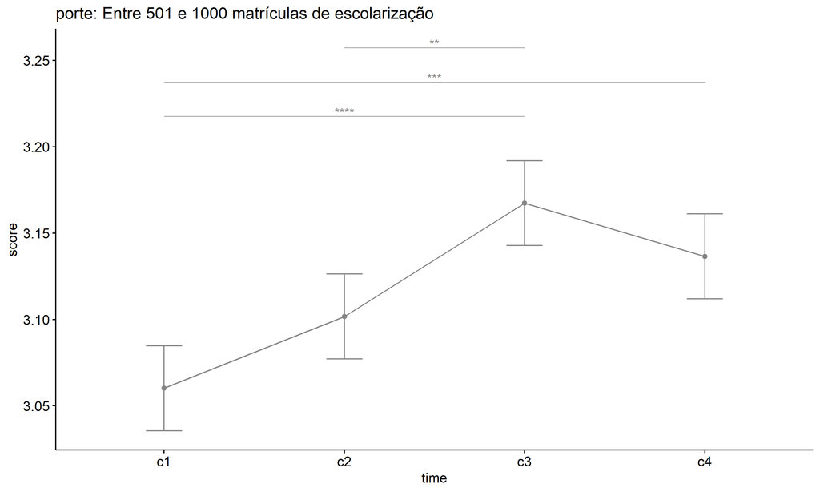

```r
if (length(non.ids) > 0) {
  emms.gg <- emms2[which(emms2$porte == "Entre 501 e 1000 matrículas de escolarização"),]
  if (nrow(emms.gg) > 0)
    ggline(emms.gg, x = "time", y = "emmean", color = "#868686FF", ylab = "score") +
    geom_errorbar(aes(ymin = conf.low, ymax = conf.high),
                  width = 0.2, color = "#868686FF") +
    stat_pvalue_manual(
      add_xy_position(pwc[which(pwc$porte == "Entre 501 e 1000 matrículas de escolarização"),],
                      x = "time", fun = "mean_se"),
      hide.ns = T, color = "#868686FF", tip.length = F) +
    labs(title = "porte: Entre 501 e 1000 matrículas de escolarização") +
    theme(legend.text = element_blank())
}
```

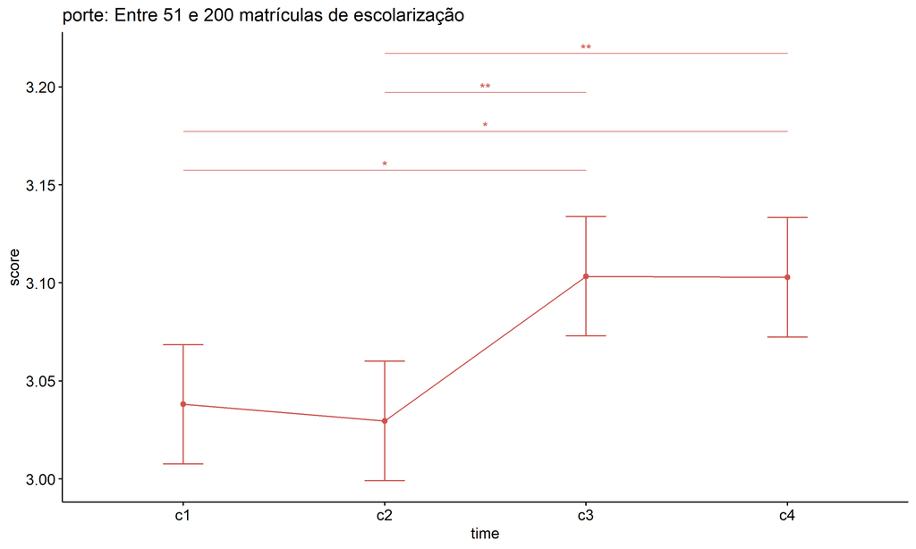

```r
if (length(non.ids) > 0) {
  emms.gg <- emms2[which(emms2$porte == "Entre 51 e 200 matrículas de escolarização"),]
  if (nrow(emms.gg) > 0)
    ggline(emms.gg, x = "time", y = "emmean", color = "#CD534CFF", ylab = "score") +
    geom_errorbar(aes(ymin = conf.low, ymax = conf.high),
                  width = 0.2, color = "#CD534CFF") +
    stat_pvalue_manual(
      add_xy_position(pwc[which(pwc$porte == "Entre 51 e 200 matrículas de escolarização"),],
                      x = "time", fun = "mean_se"),
      hide.ns = T, color = "#CD534CFF", tip.length = F) +
    labs(title = "porte: Entre 51 e 200 matrículas de escolarização") +
    theme(legend.text = element_blank())
}
```

```r
if (length(non.ids) > 0) {
  emms.gg <- emms2[which(emms2$porte == "Mais de 1000 matrículas de escolarização"),]
  if (nrow(emms.gg) > 0)
    ggline(emms.gg, x = "time", y = "emmean", color = "#7AA6DCFF", ylab = "score") +
    geom_errorbar(aes(ymin = conf.low, ymax = conf.high),
                  width = 0.2, color = "#7AA6DCFF") +
    stat_pvalue_manual(
      add_xy_position(pwc[which(pwc$porte == "Mais de 1000 matrículas de escolarização"),],
                      x = "time", fun = "mean_se"),
      hide.ns = T, color = "#7AA6DCFF", tip.length = F) +
    labs(title = "porte: Mais de 1000 matrículas de escolarização") +
    theme(legend.text = element_blank())
}
```